# Data Preprocessing : Data Quality Assessment, Preprocessing and Exploration for a Regression Modelling Problem

John Pauline Pineda

April 15, 2022

# **1. Table of Contents**

This project explores the various methods in assessing **Data Quality**, implementing **Data Preprocessing** and conducting **Data Exploration** for prediction problems with numeric responses using various helpful packages in **R**. A non-exhaustive list of methods to detect missing data, extreme outlying points, near-zero variance, multicollinearity, linear dependencies and skewed distributions were evaluated. Remedial procedures on addressing data quality issues including missing data imputation, centering and scaling transformation, shape transformation and outlier treatment were similarly considered, as applicable.  
[Data quality assessment](http://appliedpredictivemodeling.com/) involves profiling and assessing the data to understand its suitability for machine learning tasks. The quality of training data has a huge impact on the efficiency, accuracy and complexity of machine learning tasks. Data remains susceptible to errors or irregularities that may be introduced during collection, aggregation or annotation stage. Issues such as incorrect labels, synonymous categories in a categorical variable or heterogeneity in columns, among others, which might go undetected by standard pre-processing modules in these frameworks can lead to sub-optimal model performance, inaccurate analysis and unreliable decisions.  
[Data preprocessing](http://appliedpredictivemodeling.com/) involves changing the raw feature vectors into a representation that is more suitable for the downstream modelling and estimation processes, including data cleaning, integration, reduction and transformation. Data cleaning aims to identify and correct errors in the dataset that may negatively impact a predictive model such as removing outliers, replacing missing values, smoothing noisy data, and correcting inconsistent data. Data integration addresses potential issues with redundant and inconsistent data obtained from multiple sources through approaches such as detection of tuple duplication and data conflict. The purpose of data reduction is to have a condensed representation of the data set that is smaller in volume, while maintaining the integrity of the original data set. Data transformation converts the data into the most appropriate form for data modeling.  
[Data exploration](http://appliedpredictivemodeling.com/) involves analyzing and investigating data sets to summarize their main characteristics, often employing data visualization methods. It helps determine how best to manipulate data sources to discover patterns, spot anomalies, test a hypothesis, or check assumptions. This process is primarily used to see what data can reveal beyond the formal modeling or hypothesis testing task and provides a better understanding of data set variables and the relationships between them.

## 1.1 Sample Data

The **ChemicalManufacturingProcess** dataset from the **AppliedPredictiveModeling** package was used for this illustrated example.  
Preliminary dataset assessment:  
**[A]** 176 rows (observations)  
**[B]** 58 columns (variables)  
**[B.1]** 1/58 response = Yield variable (numeric)  
**[B.2]** 57/58 predictors = All remaining variables (57/57 numeric)

**Code Chunk | Output**

```r
##################################
# Loading R libraries
##################################
library(AppliedPredictiveModeling)
library(caret)
library(moments)
library(skimr)
library(dplyr)
library(RANN)
library(corrplot)
library(lares)
library(DMwR)

##################################
# Loading dataset
##################################
data(ChemicalManufacturingProcess)

##################################
# Performing a general exploration of the dataset
##################################
dim(ChemicalManufacturingProcess)
```

```
## [1] 176  58
```

```r
str(ChemicalManufacturingProcess)
```

```
## 'data.frame':    176 obs. of  58 variables:
##  $ Yield                 : num  38 42.4 42 41.4 42.5 ...
##  $ BiologicalMaterial01  : num  6.25 8.01 8.01 8.01 7.47 6.12 7.48 6.94 6.94 6.94 ...
##  $ BiologicalMaterial02  : num  49.6 61 61 61 63.3 ...
##  $ BiologicalMaterial03  : num  57 67.5 67.5 67.5 72.2 ...
##  $ BiologicalMaterial04  : num  12.7 14.6 14.6 14.6 14 ...
##  $ BiologicalMaterial05  : num  19.5 19.4 19.4 19.4 17.9 ...
##  $ BiologicalMaterial06  : num  43.7 53.1 53.1 53.1 54.7 ...
##  $ BiologicalMaterial07  : num  100 100 100 100 100 100 100 100 100 100 ...
##  $ BiologicalMaterial08  : num  16.7 19 19 19 18.2 ...
##  $ BiologicalMaterial09  : num  11.4 12.6 12.6 12.6 12.8 ...
##  $ BiologicalMaterial10  : num  3.46 3.46 3.46 3.46 3.05 3.78 3.04 3.85 3.85 3.85 ...
##  $ BiologicalMaterial11  : num  138 154 154 154 148 ...
##  $ BiologicalMaterial12  : num  18.8 21.1 21.1 21.1 21.1 ...
##  $ ManufacturingProcess01: num  NA 0 0 0 10.7 12 11.5 12 12 12 ...
```

[output cut: 44 more lines]

```r
summary(ChemicalManufacturingProcess)
```

```
##      Yield       BiologicalMaterial01 BiologicalMaterial02 BiologicalMaterial03
##  Min.   :35.25   Min.   :4.580        Min.   :46.87        Min.   :56.97
##  1st Qu.:38.75   1st Qu.:5.978        1st Qu.:52.68        1st Qu.:64.98
##  Median :39.97   Median :6.305        Median :55.09        Median :67.22
##  Mean   :40.18   Mean   :6.411        Mean   :55.69        Mean   :67.70
##  3rd Qu.:41.48   3rd Qu.:6.870        3rd Qu.:58.74        3rd Qu.:70.43
##  Max.   :46.34   Max.   :8.810        Max.   :64.75        Max.   :78.25
##
##  BiologicalMaterial04 BiologicalMaterial05 BiologicalMaterial06
##  Min.   : 9.38        Min.   :13.24        Min.   :40.60
##  1st Qu.:11.24        1st Qu.:17.23        1st Qu.:46.05
##  Median :12.10        Median :18.49        Median :48.46
##  Mean   :12.35        Mean   :18.60        Mean   :48.91
##  3rd Qu.:13.22        3rd Qu.:19.90        3rd Qu.:51.34
##  Max.   :23.09        Max.   :24.85        Max.   :59.38
##
##  BiologicalMaterial07 BiologicalMaterial08 BiologicalMaterial09
##  Min.   :100.0        Min.   :15.88        Min.   :11.44
##  1st Qu.:100.0        1st Qu.:17.06        1st Qu.:12.60
##  Median :100.0        Median :17.51        Median :12.84
##  Mean   :100.0        Mean   :17.49        Mean   :12.85
##  3rd Qu.:100.0        3rd Qu.:17.88        3rd Qu.:13.13
##  Max.   :100.8        Max.   :19.14        Max.   :14.08
##
##  BiologicalMaterial10 BiologicalMaterial11 BiologicalMaterial12
##  Min.   :1.770        Min.   :135.8        Min.   :18.35
##  1st Qu.:2.460        1st Qu.:143.8        1st Qu.:19.73
##  Median :2.710        Median :146.1        Median :20.12
##  Mean   :2.801        Mean   :147.0        Mean   :20.20
##  3rd Qu.:2.990        3rd Qu.:149.6        3rd Qu.:20.75
##  Max.   :6.870        Max.   :158.7        Max.   :22.21
##
##  ManufacturingProcess01 ManufacturingProcess02 ManufacturingProcess03
##  Min.   : 0.00          Min.   : 0.00          Min.   :1.47
##  1st Qu.:10.80          1st Qu.:19.30          1st Qu.:1.53
##  Median :11.40          Median :21.00          Median :1.54
##  Mean   :11.21          Mean   :16.68          Mean   :1.54
##  3rd Qu.:12.15          3rd Qu.:21.50          3rd Qu.:1.55
##  Max.   :14.10          Max.   :22.50          Max.   :1.60
##  NA's   :1              NA's   :3              NA's   :15
```

[output cut: 97 more lines]

```
##  Min.   :0.00000        Min.   :0.00000        Min.   : 0.00
##  1st Qu.:0.00000        1st Qu.:0.00000        1st Qu.:11.40
##  Median :0.00000        Median :0.00000        Median :11.60
##  Mean   :0.01771        Mean   :0.02371        Mean   :11.21
##  3rd Qu.:0.00000        3rd Qu.:0.00000        3rd Qu.:11.70
##  Max.   :0.10000        Max.   :0.20000        Max.   :12.10
##  NA's   :1              NA's   :1
##  ManufacturingProcess43 ManufacturingProcess44 ManufacturingProcess45
##  Min.   : 0.0000        Min.   :0.000          Min.   :0.000
##  1st Qu.: 0.6000        1st Qu.:1.800          1st Qu.:2.100
##  Median : 0.8000        Median :1.900          Median :2.200
##  Mean   : 0.9119        Mean   :1.805          Mean   :2.138
##  3rd Qu.: 1.0250        3rd Qu.:1.900          3rd Qu.:2.300
##  Max.   :11.0000        Max.   :2.100          Max.   :2.600
##
```

```r
##################################
# Formulating a data type assessment summary
##################################
PDA <- ChemicalManufacturingProcess
(PDA.Summary <- data.frame(
  Column.Index=c(1:length(names(PDA))),
  Column.Name= names(PDA),
  Column.Type=sapply(PDA, function(x) class(x)),
  row.names=NULL)
)
```

```
##    Column.Index            Column.Name Column.Type
## 1             1                  Yield     numeric
## 2             2   BiologicalMaterial01     numeric
## 3             3   BiologicalMaterial02     numeric
## 4             4   BiologicalMaterial03     numeric
## 5             5   BiologicalMaterial04     numeric
## 6             6   BiologicalMaterial05     numeric
## 7             7   BiologicalMaterial06     numeric
## 8             8   BiologicalMaterial07     numeric
## 9             9   BiologicalMaterial08     numeric
## 10           10   BiologicalMaterial09     numeric
## 11           11   BiologicalMaterial10     numeric
## 12           12   BiologicalMaterial11     numeric
## 13           13   BiologicalMaterial12     numeric
## 14           14 ManufacturingProcess01     numeric
```

[output cut: 44 more lines]

## 1.2 Data Quality Assessment

Data quality assessment:  
**[A]** Missing observations noted for 28 variables with NA.Count>0 and Fill.Rate<1.0.  
**[A.1]** ManufacturingProcess01 variable (numeric)  
**[A.2]** ManufacturingProcess02 variable (numeric)  
**[A.3]** ManufacturingProcess03 variable (numeric)  
**[A.4]** ManufacturingProcess04 variable (numeric)  
**[A.5]** ManufacturingProcess05 variable (numeric)  
**[A.6]** ManufacturingProcess06 variable (numeric)  
**[A.7]** ManufacturingProcess07 variable (numeric)  
**[A.8]** ManufacturingProcess08 variable (numeric)  
**[A.9]** ManufacturingProcess10 variable (numeric)  
**[A.10]** ManufacturingProcess11 variable (numeric)  
**[A.11]** ManufacturingProcess12 variable (numeric)  
**[A.12]** ManufacturingProcess14 variable (numeric)  
**[A.13]** ManufacturingProcess22 variable (numeric)  
**[A.14]** ManufacturingProcess23 variable (numeric)  
**[A.15]** ManufacturingProcess24 variable (numeric)  
**[A.16]** ManufacturingProcess25 variable (numeric)  
**[A.17]** ManufacturingProcess26 variable (numeric)  
**[A.18]** ManufacturingProcess27 variable (numeric)  
**[A.19]** ManufacturingProcess28 variable (numeric)  
**[A.20]** ManufacturingProcess29 variable (numeric)  
**[A.21]** ManufacturingProcess30 variable (numeric)  
**[A.22]** ManufacturingProcess31 variable (numeric)  
**[A.23]** ManufacturingProcess33 variable (numeric)  
**[A.24]** ManufacturingProcess34 variable (numeric)  
**[A.25]** ManufacturingProcess35 variable (numeric)  
**[A.26]** ManufacturingProcess36 variable (numeric)  
**[A.27]** ManufacturingProcess40 variable (numeric)  
**[A.28]** ManufacturingProcess41 variable (numeric)  
**[B]** Low variance observed for 3 variables with First.Second.Mode.Ratio>5.  
**[B.1]** BiologicalMaterial07 variable (numeric)  
**[B.2]** ManufacturingProcess28 variable (numeric)  
**[B.3]** ManufacturingProcess41 variable (numeric)  
**[C]** High skewness observed for 17 variables with Skewness>3 or Skewness<(-3).  
**[C.1]** BiologicalMaterial07 variable (numeric)  
**[C.2]** ManufacturingProcess01 variable (numeric)  
**[C.3]** ManufacturingProcess06 variable (numeric)  
**[C.4]** ManufacturingProcess16 variable (numeric)  
**[C.5]** ManufacturingProcess18 variable (numeric)  
**[C.6]** ManufacturingProcess20 variable (numeric)  
**[C.7]** ManufacturingProcess25 variable (numeric)  
**[C.8]** ManufacturingProcess26 variable (numeric)  
**[C.9]** ManufacturingProcess27 variable (numeric)  
**[C.10]** ManufacturingProcess29 variable (numeric)  
**[C.11]** ManufacturingProcess30 variable (numeric)  
**[C.12]** ManufacturingProcess31 variable (numeric)  
**[C.14]** ManufacturingProcess39 variable (numeric)  
**[C.15]** ManufacturingProcess42 variable (numeric)  
**[C.16]** ManufacturingProcess43 variable (numeric)  
**[C.17]** ManufacturingProcess44 variable (numeric)  
**[C.18]** ManufacturingProcess45 variable (numeric)

**Code Chunk | Output**

```r
##################################
# Loading dataset
##################################
DQA <- ChemicalManufacturingProcess

##################################
# Listing all predictors
##################################
DQA.Predictors <- DQA[,!names(DQA) %in% c("Yield")]

##################################
# Formulating an overall data quality assessment summary
##################################
(DQA.Summary <- data.frame(
  Column.Index=c(1:length(names(DQA))),
  Column.Name= names(DQA),
  Column.Type=sapply(DQA, function(x) class(x)),
  Row.Count=sapply(DQA, function(x) nrow(DQA)),
  NA.Count=sapply(DQA,function(x)sum(is.na(x))),
  Fill.Rate=sapply(DQA,function(x)format(round((sum(!is.na(x))/nrow(DQA)),3),nsmall=3)),
  row.names=NULL)
)
```

```
##    Column.Index            Column.Name Column.Type Row.Count NA.Count Fill.Rate
## 1             1                  Yield     numeric       176        0     1.000
## 2             2   BiologicalMaterial01     numeric       176        0     1.000
## 3             3   BiologicalMaterial02     numeric       176        0     1.000
## 4             4   BiologicalMaterial03     numeric       176        0     1.000
## 5             5   BiologicalMaterial04     numeric       176        0     1.000
## 6             6   BiologicalMaterial05     numeric       176        0     1.000
## 7             7   BiologicalMaterial06     numeric       176        0     1.000
## 8             8   BiologicalMaterial07     numeric       176        0     1.000
## 9             9   BiologicalMaterial08     numeric       176        0     1.000
## 10           10   BiologicalMaterial09     numeric       176        0     1.000
## 11           11   BiologicalMaterial10     numeric       176        0     1.000
## 12           12   BiologicalMaterial11     numeric       176        0     1.000
## 13           13   BiologicalMaterial12     numeric       176        0     1.000
## 14           14 ManufacturingProcess01     numeric       176        1     0.994
```

[output cut: 44 more lines]

```r
##################################
# Listing all numeric predictors
##################################
DQA.Predictors.Numeric <- DQA.Predictors[,sapply(DQA.Predictors, is.numeric)]

if (length(names(DQA.Predictors.Numeric))>0) {
    print(paste0("There are ",
               (length(names(DQA.Predictors.Numeric))),
               " numeric predictor variable(s)."))
} else {
  print("There are no numeric predictor variables.")
}
```

```
## [1] "There are 57 numeric predictor variable(s)."
```

```r
##################################
# Listing all factor predictors
##################################
DQA.Predictors.Factor <- DQA.Predictors[,sapply(DQA.Predictors, is.factor)]

if (length(names(DQA.Predictors.Factor))>0) {
    print(paste0("There are ",
               (length(names(DQA.Predictors.Factor))),
               " factor predictor variable(s)."))
} else {
  print("There are no factor predictor variables.")
}
```

```
## [1] "There are no factor predictor variables."
```

```r
##################################
# Formulating a data quality assessment summary for factor predictors
##################################
if (length(names(DQA.Predictors.Factor))>0) {

  ##################################
  # Formulating a function to determine the first mode
  ##################################
  FirstModes <- function(x) {
    ux <- unique(na.omit(x))
    tab <- tabulate(match(x, ux))
    ux[tab == max(tab)]
  }

  ##################################
  # Formulating a function to determine the second mode
  ##################################
  SecondModes <- function(x) {
    ux <- unique(na.omit(x))
    tab <- tabulate(match(x, ux))
    fm = ux[tab == max(tab)]
    sm = x[!(x %in% fm)]
    usm <- unique(sm)
    tabsm <- tabulate(match(sm, usm))
    usm[tabsm == max(tabsm)]
  }

  (DQA.Predictors.Factor.Summary <- data.frame(
  Column.Name= names(DQA.Predictors.Factor),
  Column.Type=sapply(DQA.Predictors.Factor, function(x) class(x)),
  Unique.Count=sapply(DQA.Predictors.Factor, function(x) length(unique(x))),
  First.Mode.Value=sapply(DQA.Predictors.Factor, function(x) as.character(FirstModes(x)[1])),
  Second.Mode.Value=sapply(DQA.Predictors.Factor, function(x) as.character(SecondModes(x)[1])),
  First.Mode.Count=sapply(DQA.Predictors.Factor, function(x) sum(na.omit(x) == FirstModes(x)[1])),
  Second.Mode.Count=sapply(DQA.Predictors.Factor, function(x) sum(na.omit(x) == SecondModes(x)[1])),
  Unique.Count.Ratio=sapply(DQA.Predictors.Factor, function(x) format(round((length(unique(x))/nrow(DQA.Predictors.Factor)),3), nsmall=3)),
  First.Second.Mode.Ratio=sapply(DQA.Predictors.Factor, function(x) format(round((sum(x == FirstModes(x)[1])/sum(x == SecondModes(x)[1])),3), nsmall=3)),
  row.names=NULL)
  )

}

##################################
# Formulating a data quality assessment summary for numeric predictors
##################################
if (length(names(DQA.Predictors.Numeric))>0) {

  ##################################
  # Formulating a function to determine the first mode
  ##################################
  FirstModes <- function(x) {
    ux <- unique(na.omit(x))
    tab <- tabulate(match(x, ux))
    ux[tab == max(tab)]
  }

  ##################################
  # Formulating a function to determine the second mode
  ##################################
  SecondModes <- function(x) {
    ux <- unique(na.omit(x))
    tab <- tabulate(match(x, ux))
    fm = ux[tab == max(tab)]
    sm = na.omit(x)[!(na.omit(x) %in% fm)]
    usm <- unique(sm)
    tabsm <- tabulate(match(sm, usm))
    usm[tabsm == max(tabsm)]
  }

  (DQA.Predictors.Numeric.Summary <- data.frame(
  Column.Name= names(DQA.Predictors.Numeric),
  Column.Type=sapply(DQA.Predictors.Numeric, function(x) class(x)),
  Unique.Count=sapply(DQA.Predictors.Numeric, function(x) length(unique(x))),
  Unique.Count.Ratio=sapply(DQA.Predictors.Numeric, function(x) format(round((length(unique(x))/nrow(DQA.Predictors.Numeric)),3), nsmall=3)),
  First.Mode.Value=sapply(DQA.Predictors.Numeric, function(x) format(round((FirstModes(x)[1]),3),nsmall=3)),
  Second.Mode.Value=sapply(DQA.Predictors.Numeric, function(x) format(round((SecondModes(x)[1]),3),nsmall=3)),
  First.Mode.Count=sapply(DQA.Predictors.Numeric, function(x) sum(na.omit(x) == FirstModes(x)[1])),
  Second.Mode.Count=sapply(DQA.Predictors.Numeric, function(x) sum(na.omit(x) == SecondModes(x)[1])),
  First.Second.Mode.Ratio=sapply(DQA.Predictors.Numeric, function(x) format(round((sum(na.omit(x) == FirstModes(x)[1])/sum(na.omit(x) == SecondModes(x)[1])),3), nsmall=3)),
  Minimum=sapply(DQA.Predictors.Numeric, function(x) format(round(min(x,na.rm = TRUE),3), nsmall=3)),
  Mean=sapply(DQA.Predictors.Numeric, function(x) format(round(mean(x,na.rm = TRUE),3), nsmall=3)),
  Median=sapply(DQA.Predictors.Numeric, function(x) format(round(median(x,na.rm = TRUE),3), nsmall=3)),
  Maximum=sapply(DQA.Predictors.Numeric, function(x) format(round(max(x,na.rm = TRUE),3), nsmall=3)),
  Skewness=sapply(DQA.Predictors.Numeric, function(x) format(round(skewness(x,na.rm = TRUE),3), nsmall=3)),
  Kurtosis=sapply(DQA.Predictors.Numeric, function(x) format(round(kurtosis(x,na.rm = TRUE),3), nsmall=3)),
  Percentile25th=sapply(DQA.Predictors.Numeric, function(x) format(round(quantile(x,probs=0.25,na.rm = TRUE),3), nsmall=3)),
  Percentile75th=sapply(DQA.Predictors.Numeric, function(x) format(round(quantile(x,probs=0.75,na.rm = TRUE),3), nsmall=3)),
  row.names=NULL)
  )

}
```

```
##               Column.Name Column.Type Unique.Count Unique.Count.Ratio
## 1    BiologicalMaterial01     numeric           89              0.506
## 2    BiologicalMaterial02     numeric          106              0.602
## 3    BiologicalMaterial03     numeric          101              0.574
## 4    BiologicalMaterial04     numeric          102              0.580
## 5    BiologicalMaterial05     numeric          103              0.585
## 6    BiologicalMaterial06     numeric          105              0.597
## 7    BiologicalMaterial07     numeric            2              0.011
## 8    BiologicalMaterial08     numeric           90              0.511
## 9    BiologicalMaterial09     numeric           79              0.449
## 10   BiologicalMaterial10     numeric           79              0.449
## 11   BiologicalMaterial11     numeric          105              0.597
## 12   BiologicalMaterial12     numeric           87              0.494
## 13 ManufacturingProcess01     numeric           42              0.239
## 14 ManufacturingProcess02     numeric           28              0.159
```

[output cut: 217 more lines]

```r
##################################
# Identifying potential data quality issues
##################################

##################################
# Checking for missing observations
##################################
if ((nrow(DQA.Summary[DQA.Summary$NA.Count>0,]))>0){
  print(paste0("Missing observations noted for ",
               (nrow(DQA.Summary[DQA.Summary$NA.Count>0,])),
               " variable(s) with NA.Count>0 and Fill.Rate<1.0."))
  DQA.Summary[DQA.Summary$NA.Count>0,]
} else {
  print("No missing observations noted.")
}
```

```
## [1] "Missing observations noted for 28 variable(s) with NA.Count>0 and Fill.Rate<1.0."
```

```
##    Column.Index            Column.Name Column.Type Row.Count NA.Count Fill.Rate
## 14           14 ManufacturingProcess01     numeric       176        1     0.994
## 15           15 ManufacturingProcess02     numeric       176        3     0.983
## 16           16 ManufacturingProcess03     numeric       176       15     0.915
## 17           17 ManufacturingProcess04     numeric       176        1     0.994
## 18           18 ManufacturingProcess05     numeric       176        1     0.994
## 19           19 ManufacturingProcess06     numeric       176        2     0.989
## 20           20 ManufacturingProcess07     numeric       176        1     0.994
## 21           21 ManufacturingProcess08     numeric       176        1     0.994
## 23           23 ManufacturingProcess10     numeric       176        9     0.949
## 24           24 ManufacturingProcess11     numeric       176       10     0.943
## 25           25 ManufacturingProcess12     numeric       176        1     0.994
## 27           27 ManufacturingProcess14     numeric       176        1     0.994
## 35           35 ManufacturingProcess22     numeric       176        1     0.994
## 36           36 ManufacturingProcess23     numeric       176        1     0.994
## 37           37 ManufacturingProcess24     numeric       176        1     0.994
## 38           38 ManufacturingProcess25     numeric       176        5     0.972
## 39           39 ManufacturingProcess26     numeric       176        5     0.972
## 40           40 ManufacturingProcess27     numeric       176        5     0.972
## 41           41 ManufacturingProcess28     numeric       176        5     0.972
## 42           42 ManufacturingProcess29     numeric       176        5     0.972
## 43           43 ManufacturingProcess30     numeric       176        5     0.972
## 44           44 ManufacturingProcess31     numeric       176        5     0.972
## 46           46 ManufacturingProcess33     numeric       176        5     0.972
## 47           47 ManufacturingProcess34     numeric       176        5     0.972
## 48           48 ManufacturingProcess35     numeric       176        5     0.972
## 49           49 ManufacturingProcess36     numeric       176        5     0.972
## 53           53 ManufacturingProcess40     numeric       176        1     0.994
## 54           54 ManufacturingProcess41     numeric       176        1     0.994
```

```r
##################################
# Checking for zero or near-zero variance predictors
##################################
if (length(names(DQA.Predictors.Factor))==0) {
  print("No factor predictors noted.")
} else if (nrow(DQA.Predictors.Factor.Summary[as.numeric(as.character(DQA.Predictors.Factor.Summary$First.Second.Mode.Ratio))>5,])>0){
  print(paste0("Low variance observed for ",
               (nrow(DQA.Predictors.Factor.Summary[as.numeric(as.character(DQA.Predictors.Factor.Summary$First.Second.Mode.Ratio))>5,])),
               " factor variable(s) with First.Second.Mode.Ratio>5."))
  DQA.Predictors.Factor.Summary[as.numeric(as.character(DQA.Predictors.Factor.Summary$First.Second.Mode.Ratio))>5,]
} else {
  print("No low variance factor predictors due to high first-second mode ratio noted.")
}
```

```
## [1] "No factor predictors noted."
```

```r
if (length(names(DQA.Predictors.Numeric))==0) {
  print("No numeric predictors noted.")
} else if (nrow(DQA.Predictors.Numeric.Summary[as.numeric(as.character(DQA.Predictors.Numeric.Summary$First.Second.Mode.Ratio))>5,])>0){
  print(paste0("Low variance observed for ",
               (nrow(DQA.Predictors.Numeric.Summary[as.numeric(as.character(DQA.Predictors.Numeric.Summary$First.Second.Mode.Ratio))>5,])),
               " numeric variable(s) with First.Second.Mode.Ratio>5."))
  DQA.Predictors.Numeric.Summary[as.numeric(as.character(DQA.Predictors.Numeric.Summary$First.Second.Mode.Ratio))>5,]
} else {
  print("No low variance numeric predictors due to high first-second mode ratio noted.")
}
```

```
## [1] "Low variance observed for 3 numeric variable(s) with First.Second.Mode.Ratio>5."
```

```
##               Column.Name Column.Type Unique.Count Unique.Count.Ratio
## 7    BiologicalMaterial07     numeric            2              0.011
## 40 ManufacturingProcess28     numeric           18              0.102
## 53 ManufacturingProcess41     numeric            5              0.028
##    First.Mode.Value Second.Mode.Value First.Mode.Count Second.Mode.Count
## 7           100.000           100.830              173                 3
## 40            0.000            10.700               66                13
## 53            0.000             0.100              143                22
##    First.Second.Mode.Ratio Minimum    Mean  Median Maximum Skewness Kurtosis
## 7                   57.667 100.000 100.014 100.000 100.830    7.462   56.684
## 40                   5.077   0.000   6.592  10.400  11.500   -0.460    1.223
## 53                   6.500   0.000   0.024   0.000   0.200    2.187    6.705
##    Percentile25th Percentile75th
## 7         100.000        100.000
## 40          0.000         10.750
## 53          0.000          0.000
```

```r
if (length(names(DQA.Predictors.Numeric))==0) {
  print("No numeric predictors noted.")
} else if (nrow(DQA.Predictors.Numeric.Summary[as.numeric(as.character(DQA.Predictors.Numeric.Summary$Unique.Count.Ratio))<0.01,])>0){
  print(paste0("Low variance observed for ",
               (nrow(DQA.Predictors.Numeric.Summary[as.numeric(as.character(DQA.Predictors.Numeric.Summary$Unique.Count.Ratio))<0.01,])),
               " numeric variable(s) with Unique.Count.Ratio<0.01."))
  DQA.Predictors.Numeric.Summary[as.numeric(as.character(DQA.Predictors.Numeric.Summary$Unique.Count.Ratio))<0.01,]
} else {
  print("No low variance numeric predictors due to low unique count ratio noted.")
}
```

```
## [1] "No low variance numeric predictors due to low unique count ratio noted."
```

```r
##################################
# Checking for skewed predictors
##################################
if (length(names(DQA.Predictors.Numeric))==0) {
  print("No numeric predictors noted.")
} else if (nrow(DQA.Predictors.Numeric.Summary[as.numeric(as.character(DQA.Predictors.Numeric.Summary$Skewness))>3 |
                                               as.numeric(as.character(DQA.Predictors.Numeric.Summary$Skewness))<(-3),])>0){
  print(paste0("High skewness observed for ",
  (nrow(DQA.Predictors.Numeric.Summary[as.numeric(as.character(DQA.Predictors.Numeric.Summary$Skewness))>3 |
                                               as.numeric(as.character(DQA.Predictors.Numeric.Summary$Skewness))<(-3),])),
  " numeric variable(s) with Skewness>3 or Skewness<(-3)."))
  DQA.Predictors.Numeric.Summary[as.numeric(as.character(DQA.Predictors.Numeric.Summary$Skewness))>3 |
                                 as.numeric(as.character(DQA.Predictors.Numeric.Summary$Skewness))<(-3),]
} else {
  print("No skewed numeric predictors noted.")
}
```

```
## [1] "High skewness observed for 17 numeric variable(s) with Skewness>3 or Skewness<(-3)."
```

```
##               Column.Name Column.Type Unique.Count Unique.Count.Ratio
## 7    BiologicalMaterial07     numeric            2              0.011
## 13 ManufacturingProcess01     numeric           42              0.239
## 18 ManufacturingProcess06     numeric           41              0.233
## 28 ManufacturingProcess16     numeric          120              0.682
## 30 ManufacturingProcess18     numeric          106              0.602
## 32 ManufacturingProcess20     numeric          112              0.636
## 37 ManufacturingProcess25     numeric          107              0.608
## 38 ManufacturingProcess26     numeric          106              0.602
## 39 ManufacturingProcess27     numeric          104              0.591
## 41 ManufacturingProcess29     numeric           31              0.176
## 42 ManufacturingProcess30     numeric           33              0.188
## 43 ManufacturingProcess31     numeric           45              0.256
## 51 ManufacturingProcess39     numeric           10              0.057
## 54 ManufacturingProcess42     numeric           17              0.097
```

[output cut: 57 more lines]

## 1.3 Data Preprocessing

### 1.3.1 Missing Data Imputation

[K-Nearest Neighbors Imputation](http://www.feat.engineering/index.html) identifies a sample with one or more missing values and determines the K most similar samples in the training data that are complete. Similarity of samples for this method is defined by either the Euclidean distance (numeric predictors) or Gower’s distance (numeric and categorical predictors) metrics. The distance measure is computed for each predictor and the average distance is used as the overall distance. The K closest samples to the sample with the missing value are identified. Once the K neighbors are found, their values are used to impute the missing data. The mode is used to impute qualitative predictors while the average or median is used to impute quantitative predictors.  
[Bagged Trees Imputation](http://www.feat.engineering/index.html) combines bootstrapping and decision trees to construct an ensemble for each predictor as a function of all the others. Tree-based models are a reasonable choice for an imputation technique since a tree can be constructed in the presence of other missing data, aside from generally having good accuracy without extrapolating values beyond the bounds of the training data. The modeling process involves generating bootstrap samples of the original data, training an unpruned decision tree for each bootstrap subset of the data and implementing an ensemble voting for all the individual decision tree predictions to formulate the final prediction.  
[Median Imputation](http://www.feat.engineering/index.html) replaces missing numeric values with the sample median providing a fast and simple fix for the missing data. However, this process will change the distributional shape, underestimate the variance, disturb the relations between variables, bias almost any estimate other than the median and bias the estimate of the median when data are not missing completely at random, especially when the missing values are large in number. This method can be slightly improved by stratifying data into subgroups.  
Missing data assessment:  
**[A]** Missing observations noted for 28 variables from the previous data quality assessment.  
**[B]** Missing observations noted for 28 variables confirmed using a descriptive statistics summary from the **skimr** package.  
**[C]** The **caret** package allows three imputation methods:  
**[C.1]** The knnImpute method is carried out by finding the k closest samples (Euclidian distance) in the training set.  
**[C.2]** The bagImpute method fits a bagged tree model for each predictor (as a function of all the others).  
**[C.3]** The medianImpute method takes the median of each predictor in the training set, and uses them to fill missing values.  
**[D]** The knnImpute, bagImpute and medianImpute methods were applied on the dataset:  
**[D.1]** Imputation was performed using a KNN (K=5) model developed from 152 observations (complete information) and 58 variables (automatic centering and scaling applied).  
**[D.2]** Imputation was performed using bagged trees model developed from 152 observations (complete information) and 58 variables (no centering and scaling applied).  
**[D.3]** Imputation was performed using the median determined for each individual variable (no centering and scaling applied).

**Code Chunk | Output**

```r
##################################
# Loading dataset
##################################
DPA <- ChemicalManufacturingProcess

##################################
# Gathering descriptive statistics
##################################
(DPA_Skimmed <- skim(DPA))
```

Data summary

| Name | DPA |
| --- | --- |
| Number of rows | 176 |
| Number of columns | 58 |
| _______________________ |  |
| Column type frequency: |  |
| numeric | 58 |
| ________________________ |  |
| Group variables | None |

**Variable type: numeric**

| skim_variable | n_missing | complete_rate | mean | sd | p0 | p25 | p50 | p75 | p100 | hist |
| --- | --- | --- | --- | --- | --- | --- | --- | --- | --- | --- |
| Yield | 0 | 1.00 | 40.18 | 1.85 | 35.25 | 38.75 | 39.97 | 41.48 | 46.34 | ▁▇▇▃▁ |
| BiologicalMaterial01 | 0 | 1.00 | 6.41 | 0.71 | 4.58 | 5.98 | 6.30 | 6.87 | 8.81 | ▂▇▇▂▁ |
| BiologicalMaterial02 | 0 | 1.00 | 55.69 | 4.03 | 46.87 | 52.68 | 55.09 | 58.74 | 64.75 | ▂▇▆▅▃ |
| BiologicalMaterial03 | 0 | 1.00 | 67.70 | 4.00 | 56.97 | 64.98 | 67.22 | 70.43 | 78.25 | ▂▅▇▆▁ |
| BiologicalMaterial04 | 0 | 1.00 | 12.35 | 1.77 | 9.38 | 11.25 | 12.10 | 13.22 | 23.09 | ▇▆▁▁▁ |
| BiologicalMaterial05 | 0 | 1.00 | 18.60 | 1.84 | 13.24 | 17.24 | 18.49 | 19.90 | 24.85 | ▁▅▇▃▁ |
| BiologicalMaterial06 | 0 | 1.00 | 48.91 | 3.75 | 40.60 | 46.06 | 48.46 | 51.34 | 59.38 | ▂▇▆▅▁ |
| BiologicalMaterial07 | 0 | 1.00 | 100.01 | 0.11 | 100.00 | 100.00 | 100.00 | 100.00 | 100.83 | ▇▁▁▁▁ |
| BiologicalMaterial08 | 0 | 1.00 | 17.49 | 0.68 | 15.88 | 17.06 | 17.51 | 17.88 | 19.14 | ▁▅▇▃▂ |
| BiologicalMaterial09 | 0 | 1.00 | 12.85 | 0.42 | 11.44 | 12.60 | 12.84 | 13.13 | 14.08 | ▁▃▇▅▁ |
| BiologicalMaterial10 | 0 | 1.00 | 2.80 | 0.60 | 1.77 | 2.46 | 2.71 | 2.99 | 6.87 | ▇▅▁▁▁ |
| BiologicalMaterial11 | 0 | 1.00 | 146.95 | 4.82 | 135.81 | 143.82 | 146.08 | 149.60 | 158.73 | ▂▆▇▃▂ |
| BiologicalMaterial12 | 0 | 1.00 | 20.20 | 0.77 | 18.35 | 19.73 | 20.12 | 20.75 | 22.21 | ▂▆▇▃▂ |
| ManufacturingProcess01 | 1 | 0.99 | 11.21 | 1.82 | 0.00 | 10.80 | 11.40 | 12.15 | 14.10 | ▁▁▁▅▇ |
| ManufacturingProcess02 | 3 | 0.98 | 16.68 | 8.47 | 0.00 | 19.30 | 21.00 | 21.50 | 22.50 | ▂▁▁▁▇ |
| ManufacturingProcess03 | 15 | 0.91 | 1.54 | 0.02 | 1.47 | 1.53 | 1.54 | 1.55 | 1.60 | ▁▃▆▇▁ |
| ManufacturingProcess04 | 1 | 0.99 | 931.85 | 6.27 | 911.00 | 928.00 | 934.00 | 936.00 | 946.00 | ▁▂▃▇▁ |
| ManufacturingProcess05 | 1 | 0.99 | 1001.69 | 30.53 | 923.00 | 986.75 | 999.20 | 1008.85 | 1175.30 | ▁▇▁▁▁ |
| ManufacturingProcess06 | 2 | 0.99 | 207.40 | 2.70 | 203.00 | 205.70 | 206.80 | 208.70 | 227.40 | ▇▃▁▁▁ |
| ManufacturingProcess07 | 1 | 0.99 | 177.48 | 0.50 | 177.00 | 177.00 | 177.00 | 178.00 | 178.00 | ▇▁▁▁▇ |
| ManufacturingProcess08 | 1 | 0.99 | 177.55 | 0.50 | 177.00 | 177.00 | 178.00 | 178.00 | 178.00 | ▆▁▁▁▇ |
| ManufacturingProcess09 | 0 | 1.00 | 45.66 | 1.55 | 38.89 | 44.89 | 45.73 | 46.52 | 49.36 | ▁▁▅▇▂ |
| ManufacturingProcess10 | 9 | 0.95 | 9.18 | 0.77 | 7.50 | 8.70 | 9.10 | 9.55 | 11.60 | ▂▇▆▂▁ |
| ManufacturingProcess11 | 10 | 0.94 | 9.39 | 0.72 | 7.50 | 9.00 | 9.40 | 9.90 | 11.50 | ▂▆▇▅▁ |
| ManufacturingProcess12 | 1 | 0.99 | 857.81 | 1784.53 | 0.00 | 0.00 | 0.00 | 0.00 | 4549.00 | ▇▁▁▁▂ |
| ManufacturingProcess13 | 0 | 1.00 | 34.51 | 1.02 | 32.10 | 33.90 | 34.60 | 35.20 | 38.60 | ▃▇▇▁▁ |
| ManufacturingProcess14 | 1 | 0.99 | 4853.87 | 54.52 | 4701.00 | 4828.00 | 4856.00 | 4882.50 | 5055.00 | ▁▅▇▂▁ |
| ManufacturingProcess15 | 0 | 1.00 | 6038.92 | 58.31 | 5904.00 | 6010.00 | 6031.50 | 6061.00 | 6233.00 | ▂▇▆▂▁ |
| ManufacturingProcess16 | 0 | 1.00 | 4565.80 | 351.70 | 0.00 | 4560.75 | 4588.00 | 4619.00 | 4852.00 | ▁▁▁▁▇ |
| ManufacturingProcess17 | 0 | 1.00 | 34.34 | 1.25 | 31.30 | 33.50 | 34.40 | 35.10 | 40.00 | ▂▇▆▁▁ |
| ManufacturingProcess18 | 0 | 1.00 | 4809.68 | 367.48 | 0.00 | 4813.00 | 4835.00 | 4862.00 | 4971.00 | ▁▁▁▁▇ |
| ManufacturingProcess19 | 0 | 1.00 | 6028.20 | 45.58 | 5890.00 | 6000.75 | 6022.00 | 6050.25 | 6146.00 | ▁▃▇▃▂ |
| ManufacturingProcess20 | 0 | 1.00 | 4556.46 | 349.01 | 0.00 | 4552.75 | 4582.00 | 4609.50 | 4759.00 | ▁▁▁▁▇ |
| ManufacturingProcess21 | 0 | 1.00 | -0.16 | 0.78 | -1.80 | -0.60 | -0.30 | 0.00 | 3.60 | ▂▇▂▁▁ |
| ManufacturingProcess22 | 1 | 0.99 | 5.41 | 3.33 | 0.00 | 3.00 | 5.00 | 8.00 | 12.00 | ▇▇▇▅▅ |
| ManufacturingProcess23 | 1 | 0.99 | 3.02 | 1.66 | 0.00 | 2.00 | 3.00 | 4.00 | 6.00 | ▇▆▇▆▇ |
| ManufacturingProcess24 | 1 | 0.99 | 8.83 | 5.80 | 0.00 | 4.00 | 8.00 | 14.00 | 23.00 | ▇▇▅▆▁ |
| ManufacturingProcess25 | 5 | 0.97 | 4828.18 | 373.48 | 0.00 | 4832.00 | 4855.00 | 4877.00 | 4990.00 | ▁▁▁▁▇ |
| ManufacturingProcess26 | 5 | 0.97 | 6015.60 | 464.87 | 0.00 | 6019.50 | 6047.00 | 6070.50 | 6161.00 | ▁▁▁▁▇ |
| ManufacturingProcess27 | 5 | 0.97 | 4562.51 | 353.98 | 0.00 | 4560.00 | 4587.00 | 4609.00 | 4710.00 | ▁▁▁▁▇ |
| ManufacturingProcess28 | 5 | 0.97 | 6.59 | 5.25 | 0.00 | 0.00 | 10.40 | 10.75 | 11.50 | ▅▁▁▁▇ |
| ManufacturingProcess29 | 5 | 0.97 | 20.01 | 1.66 | 0.00 | 19.70 | 19.90 | 20.40 | 22.00 | ▁▁▁▁▇ |
| ManufacturingProcess30 | 5 | 0.97 | 9.16 | 0.98 | 0.00 | 8.80 | 9.10 | 9.70 | 11.20 | ▁▁▁▅▇ |
| ManufacturingProcess31 | 5 | 0.97 | 70.18 | 5.56 | 0.00 | 70.10 | 70.80 | 71.40 | 72.50 | ▁▁▁▁▇ |
| ManufacturingProcess32 | 0 | 1.00 | 158.47 | 5.40 | 143.00 | 155.00 | 158.00 | 162.00 | 173.00 | ▁▃▇▃▁ |
| ManufacturingProcess33 | 5 | 0.97 | 63.54 | 2.48 | 56.00 | 62.00 | 64.00 | 65.00 | 70.00 | ▁▃▇▅▁ |
| ManufacturingProcess34 | 5 | 0.97 | 2.49 | 0.05 | 2.30 | 2.50 | 2.50 | 2.50 | 2.60 | ▁▂▁▇▁ |
| ManufacturingProcess35 | 5 | 0.97 | 495.60 | 10.82 | 463.00 | 490.00 | 495.00 | 501.50 | 522.00 | ▁▂▇▅▂ |
| ManufacturingProcess36 | 5 | 0.97 | 0.02 | 0.00 | 0.02 | 0.02 | 0.02 | 0.02 | 0.02 | ▂▇▇▁▃ |
| ManufacturingProcess37 | 0 | 1.00 | 1.01 | 0.45 | 0.00 | 0.70 | 1.00 | 1.30 | 2.30 | ▂▇▇▃▁ |
| ManufacturingProcess38 | 0 | 1.00 | 2.53 | 0.65 | 0.00 | 2.00 | 3.00 | 3.00 | 3.00 | ▁▁▁▅▇ |
| ManufacturingProcess39 | 0 | 1.00 | 6.85 | 1.51 | 0.00 | 7.10 | 7.20 | 7.30 | 7.50 | ▁▁▁▁▇ |
| ManufacturingProcess40 | 1 | 0.99 | 0.02 | 0.04 | 0.00 | 0.00 | 0.00 | 0.00 | 0.10 | ▇▁▁▁▂ |
| ManufacturingProcess41 | 1 | 0.99 | 0.02 | 0.05 | 0.00 | 0.00 | 0.00 | 0.00 | 0.20 | ▇▁▁▁▁ |
| ManufacturingProcess42 | 0 | 1.00 | 11.21 | 1.94 | 0.00 | 11.40 | 11.60 | 11.70 | 12.10 | ▁▁▁▁▇ |
| ManufacturingProcess43 | 0 | 1.00 | 0.91 | 0.87 | 0.00 | 0.60 | 0.80 | 1.02 | 11.00 | ▇▁▁▁▁ |
| ManufacturingProcess44 | 0 | 1.00 | 1.81 | 0.32 | 0.00 | 1.80 | 1.90 | 1.90 | 2.10 | ▁▁▁▁▇ |
| ManufacturingProcess45 | 0 | 1.00 | 2.14 | 0.41 | 0.00 | 2.10 | 2.20 | 2.30 | 2.60 | ▁▁▁▂▇ |

```r
##################################
# Identifying columns with missing data
#################################
DPA %>%
skim() %>%
dplyr::filter(n_missing > 0)
```

Data summary

| Name | Piped data |
| --- | --- |
| Number of rows | 176 |
| Number of columns | 58 |
| _______________________ |  |
| Column type frequency: |  |
| numeric | 28 |
| ________________________ |  |
| Group variables | None |

**Variable type: numeric**

| skim_variable | n_missing | complete_rate | mean | sd | p0 | p25 | p50 | p75 | p100 | hist |
| --- | --- | --- | --- | --- | --- | --- | --- | --- | --- | --- |
| ManufacturingProcess01 | 1 | 0.99 | 11.21 | 1.82 | 0.00 | 10.80 | 11.40 | 12.15 | 14.10 | ▁▁▁▅▇ |
| ManufacturingProcess02 | 3 | 0.98 | 16.68 | 8.47 | 0.00 | 19.30 | 21.00 | 21.50 | 22.50 | ▂▁▁▁▇ |
| ManufacturingProcess03 | 15 | 0.91 | 1.54 | 0.02 | 1.47 | 1.53 | 1.54 | 1.55 | 1.60 | ▁▃▆▇▁ |
| ManufacturingProcess04 | 1 | 0.99 | 931.85 | 6.27 | 911.00 | 928.00 | 934.00 | 936.00 | 946.00 | ▁▂▃▇▁ |
| ManufacturingProcess05 | 1 | 0.99 | 1001.69 | 30.53 | 923.00 | 986.75 | 999.20 | 1008.85 | 1175.30 | ▁▇▁▁▁ |
| ManufacturingProcess06 | 2 | 0.99 | 207.40 | 2.70 | 203.00 | 205.70 | 206.80 | 208.70 | 227.40 | ▇▃▁▁▁ |
| ManufacturingProcess07 | 1 | 0.99 | 177.48 | 0.50 | 177.00 | 177.00 | 177.00 | 178.00 | 178.00 | ▇▁▁▁▇ |
| ManufacturingProcess08 | 1 | 0.99 | 177.55 | 0.50 | 177.00 | 177.00 | 178.00 | 178.00 | 178.00 | ▆▁▁▁▇ |
| ManufacturingProcess10 | 9 | 0.95 | 9.18 | 0.77 | 7.50 | 8.70 | 9.10 | 9.55 | 11.60 | ▂▇▆▂▁ |
| ManufacturingProcess11 | 10 | 0.94 | 9.39 | 0.72 | 7.50 | 9.00 | 9.40 | 9.90 | 11.50 | ▂▆▇▅▁ |
| ManufacturingProcess12 | 1 | 0.99 | 857.81 | 1784.53 | 0.00 | 0.00 | 0.00 | 0.00 | 4549.00 | ▇▁▁▁▂ |
| ManufacturingProcess14 | 1 | 0.99 | 4853.87 | 54.52 | 4701.00 | 4828.00 | 4856.00 | 4882.50 | 5055.00 | ▁▅▇▂▁ |
| ManufacturingProcess22 | 1 | 0.99 | 5.41 | 3.33 | 0.00 | 3.00 | 5.00 | 8.00 | 12.00 | ▇▇▇▅▅ |
| ManufacturingProcess23 | 1 | 0.99 | 3.02 | 1.66 | 0.00 | 2.00 | 3.00 | 4.00 | 6.00 | ▇▆▇▆▇ |
| ManufacturingProcess24 | 1 | 0.99 | 8.83 | 5.80 | 0.00 | 4.00 | 8.00 | 14.00 | 23.00 | ▇▇▅▆▁ |
| ManufacturingProcess25 | 5 | 0.97 | 4828.18 | 373.48 | 0.00 | 4832.00 | 4855.00 | 4877.00 | 4990.00 | ▁▁▁▁▇ |
| ManufacturingProcess26 | 5 | 0.97 | 6015.60 | 464.87 | 0.00 | 6019.50 | 6047.00 | 6070.50 | 6161.00 | ▁▁▁▁▇ |
| ManufacturingProcess27 | 5 | 0.97 | 4562.51 | 353.98 | 0.00 | 4560.00 | 4587.00 | 4609.00 | 4710.00 | ▁▁▁▁▇ |
| ManufacturingProcess28 | 5 | 0.97 | 6.59 | 5.25 | 0.00 | 0.00 | 10.40 | 10.75 | 11.50 | ▅▁▁▁▇ |
| ManufacturingProcess29 | 5 | 0.97 | 20.01 | 1.66 | 0.00 | 19.70 | 19.90 | 20.40 | 22.00 | ▁▁▁▁▇ |
| ManufacturingProcess30 | 5 | 0.97 | 9.16 | 0.98 | 0.00 | 8.80 | 9.10 | 9.70 | 11.20 | ▁▁▁▅▇ |
| ManufacturingProcess31 | 5 | 0.97 | 70.18 | 5.56 | 0.00 | 70.10 | 70.80 | 71.40 | 72.50 | ▁▁▁▁▇ |
| ManufacturingProcess33 | 5 | 0.97 | 63.54 | 2.48 | 56.00 | 62.00 | 64.00 | 65.00 | 70.00 | ▁▃▇▅▁ |
| ManufacturingProcess34 | 5 | 0.97 | 2.49 | 0.05 | 2.30 | 2.50 | 2.50 | 2.50 | 2.60 | ▁▂▁▇▁ |
| ManufacturingProcess35 | 5 | 0.97 | 495.60 | 10.82 | 463.00 | 490.00 | 495.00 | 501.50 | 522.00 | ▁▂▇▅▂ |
| ManufacturingProcess36 | 5 | 0.97 | 0.02 | 0.00 | 0.02 | 0.02 | 0.02 | 0.02 | 0.02 | ▂▇▇▁▃ |
| ManufacturingProcess40 | 1 | 0.99 | 0.02 | 0.04 | 0.00 | 0.00 | 0.00 | 0.00 | 0.10 | ▇▁▁▁▂ |
| ManufacturingProcess41 | 1 | 0.99 | 0.02 | 0.05 | 0.00 | 0.00 | 0.00 | 0.00 | 0.20 | ▇▁▁▁▁ |

```r
##################################
# Creating a KNN imputation model from the dataset
#################################
(DPA_KNNImputeModel <- preProcess(DPA, method='knnImpute'))
```

```
## Created from 152 samples and 58 variables
##
## Pre-processing:
##   - centered (58)
##   - ignored (0)
##   - 5 nearest neighbor imputation (58)
##   - scaled (58)
```

```r
DPA_KNNImputed <- predict(DPA_KNNImputeModel, newdata=DPA)

##################################
# Gathering descriptive statistics
##################################
(DPA_KNNImputed_Skimmed <- skim(DPA_KNNImputed))
```

Data summary

| Name | DPA_KNNImputed |
| --- | --- |
| Number of rows | 176 |
| Number of columns | 58 |
| _______________________ |  |
| Column type frequency: |  |
| numeric | 58 |
| ________________________ |  |
| Group variables | None |

**Variable type: numeric**

| skim_variable | n_missing | complete_rate | mean | sd | p0 | p25 | p50 | p75 | p100 | hist |
| --- | --- | --- | --- | --- | --- | --- | --- | --- | --- | --- |
| Yield | 0 | 1 | 0.00 | 1.00 | -2.67 | -0.77 | -0.11 | 0.70 | 3.34 | ▁▇▇▃▁ |
| BiologicalMaterial01 | 0 | 1 | 0.00 | 1.00 | -2.57 | -0.61 | -0.15 | 0.64 | 3.36 | ▂▇▇▂▁ |
| BiologicalMaterial02 | 0 | 1 | 0.00 | 1.00 | -2.19 | -0.75 | -0.15 | 0.76 | 2.25 | ▂▇▆▅▃ |
| BiologicalMaterial03 | 0 | 1 | 0.00 | 1.00 | -2.68 | -0.68 | -0.12 | 0.68 | 2.64 | ▂▅▇▆▁ |
| BiologicalMaterial04 | 0 | 1 | 0.00 | 1.00 | -1.67 | -0.62 | -0.14 | 0.49 | 6.05 | ▇▆▁▁▁ |
| BiologicalMaterial05 | 0 | 1 | 0.00 | 1.00 | -2.91 | -0.74 | -0.06 | 0.71 | 3.39 | ▁▅▇▃▁ |
| BiologicalMaterial06 | 0 | 1 | 0.00 | 1.00 | -2.22 | -0.76 | -0.12 | 0.65 | 2.79 | ▂▇▆▅▁ |
| BiologicalMaterial07 | 0 | 1 | 0.00 | 1.00 | -0.13 | -0.13 | -0.13 | -0.13 | 7.57 | ▇▁▁▁▁ |
| BiologicalMaterial08 | 0 | 1 | 0.00 | 1.00 | -2.39 | -0.64 | 0.02 | 0.57 | 2.43 | ▁▅▇▃▂ |
| BiologicalMaterial09 | 0 | 1 | 0.00 | 1.00 | -3.40 | -0.60 | -0.04 | 0.67 | 2.96 | ▁▃▇▅▁ |
| BiologicalMaterial10 | 0 | 1 | 0.00 | 1.00 | -1.72 | -0.57 | -0.15 | 0.32 | 6.79 | ▇▅▁▁▁ |
| BiologicalMaterial11 | 0 | 1 | 0.00 | 1.00 | -2.31 | -0.65 | -0.18 | 0.55 | 2.44 | ▂▆▇▃▂ |
| BiologicalMaterial12 | 0 | 1 | 0.00 | 1.00 | -2.39 | -0.61 | -0.10 | 0.71 | 2.60 | ▂▆▇▃▂ |
| ManufacturingProcess01 | 0 | 1 | 0.00 | 1.00 | -6.15 | -0.22 | 0.11 | 0.50 | 1.59 | ▁▁▁▅▇ |
| ManufacturingProcess02 | 0 | 1 | 0.01 | 0.99 | -1.97 | 0.31 | 0.51 | 0.57 | 0.69 | ▂▁▁▁▇ |
| ManufacturingProcess03 | 0 | 1 | 0.04 | 0.97 | -3.11 | -0.43 | 0.38 | 0.47 | 2.70 | ▁▂▆▇▁ |
| ManufacturingProcess04 | 0 | 1 | 0.00 | 1.00 | -3.32 | -0.61 | 0.34 | 0.66 | 2.25 | ▁▂▃▇▂ |
| ManufacturingProcess05 | 0 | 1 | 0.00 | 1.00 | -2.58 | -0.49 | -0.09 | 0.23 | 5.69 | ▁▇▁▁▁ |
| ManufacturingProcess06 | 0 | 1 | -0.01 | 1.00 | -1.63 | -0.63 | -0.22 | 0.48 | 7.41 | ▇▃▁▁▁ |
| ManufacturingProcess07 | 0 | 1 | 0.00 | 1.00 | -0.96 | -0.96 | -0.96 | 1.04 | 1.04 | ▇▁▁▁▇ |
| ManufacturingProcess08 | 0 | 1 | 0.00 | 1.00 | -1.11 | -1.11 | 0.89 | 0.89 | 0.89 | ▆▁▁▁▇ |
| ManufacturingProcess09 | 0 | 1 | 0.00 | 1.00 | -4.38 | -0.50 | 0.05 | 0.55 | 2.39 | ▁▁▅▇▂ |
| ManufacturingProcess10 | 0 | 1 | 0.02 | 0.99 | -2.19 | -0.62 | -0.10 | 0.55 | 3.16 | ▂▇▇▂▁ |
| ManufacturingProcess11 | 0 | 1 | 0.03 | 1.00 | -2.63 | -0.54 | 0.02 | 0.72 | 2.95 | ▁▇▇▆▁ |
| ManufacturingProcess12 | 0 | 1 | 0.00 | 1.00 | -0.48 | -0.48 | -0.48 | -0.48 | 2.07 | ▇▁▁▁▂ |
| ManufacturingProcess13 | 0 | 1 | 0.00 | 1.00 | -2.37 | -0.60 | 0.09 | 0.68 | 4.03 | ▃▆▇▁▁ |
| ManufacturingProcess14 | 0 | 1 | 0.00 | 1.00 | -2.80 | -0.49 | 0.03 | 0.52 | 3.69 | ▁▅▇▂▁ |
| ManufacturingProcess15 | 0 | 1 | 0.00 | 1.00 | -2.31 | -0.50 | -0.13 | 0.38 | 3.33 | ▂▇▆▂▁ |
| ManufacturingProcess16 | 0 | 1 | 0.00 | 1.00 | -12.98 | -0.01 | 0.06 | 0.15 | 0.81 | ▁▁▁▁▇ |
| ManufacturingProcess17 | 0 | 1 | 0.00 | 1.00 | -2.44 | -0.68 | 0.05 | 0.61 | 4.53 | ▂▇▆▁▁ |
| ManufacturingProcess18 | 0 | 1 | 0.00 | 1.00 | -13.09 | 0.01 | 0.07 | 0.14 | 0.44 | ▁▁▁▁▇ |
| ManufacturingProcess19 | 0 | 1 | 0.00 | 1.00 | -3.03 | -0.60 | -0.14 | 0.48 | 2.58 | ▁▃▇▃▂ |
| ManufacturingProcess20 | 0 | 1 | 0.00 | 1.00 | -13.06 | -0.01 | 0.07 | 0.15 | 0.58 | ▁▁▁▁▇ |
| ManufacturingProcess21 | 0 | 1 | 0.00 | 1.00 | -2.10 | -0.56 | -0.17 | 0.21 | 4.84 | ▂▇▂▁▁ |
| ManufacturingProcess22 | 0 | 1 | 0.00 | 1.00 | -1.62 | -0.72 | -0.12 | 0.78 | 1.98 | ▇▇▇▅▅ |
| ManufacturingProcess23 | 0 | 1 | 0.00 | 1.00 | -1.81 | -0.61 | -0.01 | 0.59 | 1.79 | ▇▆▇▆▇ |
| ManufacturingProcess24 | 0 | 1 | 0.01 | 1.00 | -1.52 | -0.83 | -0.14 | 0.89 | 2.44 | ▇▇▅▆▁ |
| ManufacturingProcess25 | 0 | 1 | 0.00 | 0.99 | -12.93 | 0.00 | 0.07 | 0.13 | 0.43 | ▁▁▁▁▇ |
| ManufacturingProcess26 | 0 | 1 | 0.00 | 0.99 | -12.94 | 0.01 | 0.06 | 0.12 | 0.31 | ▁▁▁▁▇ |
| ManufacturingProcess27 | 0 | 1 | 0.00 | 0.99 | -12.89 | 0.00 | 0.07 | 0.13 | 0.42 | ▁▁▁▁▇ |
| ManufacturingProcess28 | 0 | 1 | -0.03 | 1.00 | -1.26 | -1.26 | 0.73 | 0.78 | 0.94 | ▅▁▁▁▇ |
| ManufacturingProcess29 | 0 | 1 | 0.00 | 0.99 | -12.03 | -0.19 | -0.07 | 0.23 | 1.20 | ▁▁▁▁▇ |
| ManufacturingProcess30 | 0 | 1 | 0.01 | 0.99 | -9.39 | -0.37 | 0.04 | 0.55 | 2.09 | ▁▁▁▅▇ |
| ManufacturingProcess31 | 0 | 1 | 0.00 | 0.99 | -12.63 | -0.02 | 0.11 | 0.22 | 0.42 | ▁▁▁▁▇ |
| ManufacturingProcess32 | 0 | 1 | 0.00 | 1.00 | -2.87 | -0.64 | -0.09 | 0.65 | 2.69 | ▁▃▇▃▁ |
| ManufacturingProcess33 | 0 | 1 | -0.01 | 0.99 | -3.04 | -0.62 | 0.18 | 0.59 | 2.60 | ▁▃▇▅▁ |
| ManufacturingProcess34 | 0 | 1 | -0.01 | 0.99 | -3.56 | 0.12 | 0.12 | 0.12 | 1.96 | ▁▂▁▇▁ |
| ManufacturingProcess35 | 0 | 1 | -0.02 | 1.00 | -3.01 | -0.52 | -0.06 | 0.50 | 2.44 | ▁▃▇▅▂ |
| ManufacturingProcess36 | 0 | 1 | -0.01 | 0.99 | -2.94 | -0.66 | -0.08 | 0.49 | 2.78 | ▂▇▁▇▃ |
| ManufacturingProcess37 | 0 | 1 | 0.00 | 1.00 | -2.28 | -0.70 | -0.03 | 0.64 | 2.89 | ▂▇▇▃▁ |
| ManufacturingProcess38 | 0 | 1 | 0.00 | 1.00 | -3.90 | -0.82 | 0.72 | 0.72 | 0.72 | ▁▁▁▅▇ |
| ManufacturingProcess39 | 0 | 1 | 0.00 | 1.00 | -4.55 | 0.17 | 0.23 | 0.30 | 0.43 | ▁▁▁▁▇ |
| ManufacturingProcess40 | 0 | 1 | 0.00 | 1.00 | -0.46 | -0.46 | -0.46 | -0.46 | 2.15 | ▇▁▁▁▂ |
| ManufacturingProcess41 | 0 | 1 | 0.00 | 1.00 | -0.44 | -0.44 | -0.44 | -0.44 | 3.28 | ▇▁▁▁▁ |
| ManufacturingProcess42 | 0 | 1 | 0.00 | 1.00 | -5.77 | 0.10 | 0.20 | 0.25 | 0.46 | ▁▁▁▁▇ |
| ManufacturingProcess43 | 0 | 1 | 0.00 | 1.00 | -1.05 | -0.36 | -0.13 | 0.13 | 11.62 | ▇▁▁▁▁ |
| ManufacturingProcess44 | 0 | 1 | 0.00 | 1.00 | -5.61 | -0.02 | 0.29 | 0.29 | 0.92 | ▁▁▁▁▇ |
| ManufacturingProcess45 | 0 | 1 | 0.00 | 1.00 | -5.25 | -0.09 | 0.15 | 0.40 | 1.14 | ▁▁▁▂▇ |

```r
##################################
# Identifying columns with missing data
#################################
DPA_KNNImputed %>%
skim() %>%
dplyr::filter(n_missing > 0)
```

```
## # A tibble: 0 x 12
## # ... with 12 variables: skim_type <chr>, skim_variable <chr>, n_missing <int>,
## #   complete_rate <dbl>, numeric.mean <dbl>, numeric.sd <dbl>,
## #   numeric.p0 <dbl>, numeric.p25 <dbl>, numeric.p50 <dbl>, numeric.p75 <dbl>,
## #   numeric.p100 <dbl>, numeric.hist <chr>
```

```r
##################################
# Creating a Bagged Tree imputation model from the dataset
#################################
(DPA_BagImputeModel <- preProcess(DPA, method='bagImpute'))
```

```
## Created from 152 samples and 58 variables
##
## Pre-processing:
##   - bagged tree imputation (58)
##   - ignored (0)
```

```r
DPA_BagImputed <- predict(DPA_BagImputeModel, newdata=DPA)

##################################
# Gathering descriptive statistics
##################################
(DPA_BagImputed_Skimmed <- skim(DPA_BagImputed))
```

Data summary

| Name | DPA_BagImputed |
| --- | --- |
| Number of rows | 176 |
| Number of columns | 58 |
| _______________________ |  |
| Column type frequency: |  |
| numeric | 58 |
| ________________________ |  |
| Group variables | None |

**Variable type: numeric**

| skim_variable | n_missing | complete_rate | mean | sd | p0 | p25 | p50 | p75 | p100 | hist |
| --- | --- | --- | --- | --- | --- | --- | --- | --- | --- | --- |
| Yield | 0 | 1 | 40.18 | 1.85 | 35.25 | 38.75 | 39.97 | 41.48 | 46.34 | ▁▇▇▃▁ |
| BiologicalMaterial01 | 0 | 1 | 6.41 | 0.71 | 4.58 | 5.98 | 6.30 | 6.87 | 8.81 | ▂▇▇▂▁ |
| BiologicalMaterial02 | 0 | 1 | 55.69 | 4.03 | 46.87 | 52.68 | 55.09 | 58.74 | 64.75 | ▂▇▆▅▃ |
| BiologicalMaterial03 | 0 | 1 | 67.70 | 4.00 | 56.97 | 64.98 | 67.22 | 70.43 | 78.25 | ▂▅▇▆▁ |
| BiologicalMaterial04 | 0 | 1 | 12.35 | 1.77 | 9.38 | 11.25 | 12.10 | 13.22 | 23.09 | ▇▆▁▁▁ |
| BiologicalMaterial05 | 0 | 1 | 18.60 | 1.84 | 13.24 | 17.24 | 18.49 | 19.90 | 24.85 | ▁▅▇▃▁ |
| BiologicalMaterial06 | 0 | 1 | 48.91 | 3.75 | 40.60 | 46.06 | 48.46 | 51.34 | 59.38 | ▂▇▆▅▁ |
| BiologicalMaterial07 | 0 | 1 | 100.01 | 0.11 | 100.00 | 100.00 | 100.00 | 100.00 | 100.83 | ▇▁▁▁▁ |
| BiologicalMaterial08 | 0 | 1 | 17.49 | 0.68 | 15.88 | 17.06 | 17.51 | 17.88 | 19.14 | ▁▅▇▃▂ |
| BiologicalMaterial09 | 0 | 1 | 12.85 | 0.42 | 11.44 | 12.60 | 12.84 | 13.13 | 14.08 | ▁▃▇▅▁ |
| BiologicalMaterial10 | 0 | 1 | 2.80 | 0.60 | 1.77 | 2.46 | 2.71 | 2.99 | 6.87 | ▇▅▁▁▁ |
| BiologicalMaterial11 | 0 | 1 | 146.95 | 4.82 | 135.81 | 143.82 | 146.08 | 149.60 | 158.73 | ▂▆▇▃▂ |
| BiologicalMaterial12 | 0 | 1 | 20.20 | 0.77 | 18.35 | 19.73 | 20.12 | 20.75 | 22.21 | ▂▆▇▃▂ |
| ManufacturingProcess01 | 0 | 1 | 11.20 | 1.82 | 0.00 | 10.78 | 11.40 | 12.12 | 14.10 | ▁▁▁▅▇ |
| ManufacturingProcess02 | 0 | 1 | 16.72 | 8.41 | 0.00 | 19.23 | 21.00 | 21.50 | 22.50 | ▂▁▁▁▇ |
| ManufacturingProcess03 | 0 | 1 | 1.54 | 0.02 | 1.47 | 1.53 | 1.54 | 1.55 | 1.60 | ▁▂▆▇▁ |
| ManufacturingProcess04 | 0 | 1 | 931.82 | 6.27 | 911.00 | 927.75 | 934.00 | 936.00 | 946.00 | ▁▂▃▇▁ |
| ManufacturingProcess05 | 0 | 1 | 1001.66 | 30.44 | 923.00 | 986.82 | 999.05 | 1008.72 | 1175.30 | ▁▇▁▁▁ |
| ManufacturingProcess06 | 0 | 1 | 207.38 | 2.69 | 203.00 | 205.70 | 206.80 | 208.70 | 227.40 | ▇▃▁▁▁ |
| ManufacturingProcess07 | 0 | 1 | 177.48 | 0.50 | 177.00 | 177.00 | 177.00 | 178.00 | 178.00 | ▇▁▁▁▇ |
| ManufacturingProcess08 | 0 | 1 | 177.56 | 0.50 | 177.00 | 177.00 | 178.00 | 178.00 | 178.00 | ▆▁▁▁▇ |
| ManufacturingProcess09 | 0 | 1 | 45.66 | 1.55 | 38.89 | 44.89 | 45.73 | 46.52 | 49.36 | ▁▁▅▇▂ |
| ManufacturingProcess10 | 0 | 1 | 9.17 | 0.76 | 7.50 | 8.70 | 9.10 | 9.53 | 11.60 | ▂▇▆▂▁ |
| ManufacturingProcess11 | 0 | 1 | 9.39 | 0.70 | 7.50 | 9.00 | 9.40 | 9.90 | 11.50 | ▂▆▇▅▁ |
| ManufacturingProcess12 | 0 | 1 | 856.88 | 1779.47 | 0.00 | 0.00 | 0.00 | 0.00 | 4549.00 | ▇▁▁▁▂ |
| ManufacturingProcess13 | 0 | 1 | 34.51 | 1.02 | 32.10 | 33.90 | 34.60 | 35.20 | 38.60 | ▃▇▇▁▁ |
| ManufacturingProcess14 | 0 | 1 | 4853.66 | 54.44 | 4701.00 | 4827.25 | 4855.50 | 4882.25 | 5055.00 | ▁▅▇▂▁ |
| ManufacturingProcess15 | 0 | 1 | 6038.92 | 58.31 | 5904.00 | 6010.00 | 6031.50 | 6061.00 | 6233.00 | ▂▇▆▂▁ |
| ManufacturingProcess16 | 0 | 1 | 4565.80 | 351.70 | 0.00 | 4560.75 | 4588.00 | 4619.00 | 4852.00 | ▁▁▁▁▇ |
| ManufacturingProcess17 | 0 | 1 | 34.34 | 1.25 | 31.30 | 33.50 | 34.40 | 35.10 | 40.00 | ▂▇▆▁▁ |
| ManufacturingProcess18 | 0 | 1 | 4809.68 | 367.48 | 0.00 | 4813.00 | 4835.00 | 4862.00 | 4971.00 | ▁▁▁▁▇ |
| ManufacturingProcess19 | 0 | 1 | 6028.20 | 45.58 | 5890.00 | 6000.75 | 6022.00 | 6050.25 | 6146.00 | ▁▃▇▃▂ |
| ManufacturingProcess20 | 0 | 1 | 4556.46 | 349.01 | 0.00 | 4552.75 | 4582.00 | 4609.50 | 4759.00 | ▁▁▁▁▇ |
| ManufacturingProcess21 | 0 | 1 | -0.16 | 0.78 | -1.80 | -0.60 | -0.30 | 0.00 | 3.60 | ▂▇▂▁▁ |
| ManufacturingProcess22 | 0 | 1 | 5.40 | 3.32 | 0.00 | 3.00 | 5.00 | 8.00 | 12.00 | ▇▇▇▅▅ |
| ManufacturingProcess23 | 0 | 1 | 3.02 | 1.66 | 0.00 | 2.00 | 3.00 | 4.00 | 6.00 | ▇▆▇▆▇ |
| ManufacturingProcess24 | 0 | 1 | 8.86 | 5.80 | 0.00 | 4.00 | 8.00 | 14.00 | 23.00 | ▇▇▅▆▁ |
| ManufacturingProcess25 | 0 | 1 | 4828.44 | 368.11 | 0.00 | 4832.00 | 4854.00 | 4876.25 | 4990.00 | ▁▁▁▁▇ |
| ManufacturingProcess26 | 0 | 1 | 6012.09 | 459.12 | 0.00 | 6019.00 | 6045.00 | 6069.25 | 6161.00 | ▁▁▁▁▇ |
| ManufacturingProcess27 | 0 | 1 | 4556.43 | 352.33 | 0.00 | 4557.00 | 4586.50 | 4609.00 | 4710.00 | ▁▁▁▁▇ |
| ManufacturingProcess28 | 0 | 1 | 6.57 | 5.18 | 0.00 | 0.00 | 10.40 | 10.70 | 11.50 | ▅▁▁▁▇ |
| ManufacturingProcess29 | 0 | 1 | 19.98 | 1.66 | 0.00 | 19.70 | 19.90 | 20.40 | 22.00 | ▁▁▁▁▇ |
| ManufacturingProcess30 | 0 | 1 | 9.17 | 0.96 | 0.00 | 8.80 | 9.20 | 9.70 | 11.20 | ▁▁▁▅▇ |
| ManufacturingProcess31 | 0 | 1 | 70.14 | 5.49 | 0.00 | 70.10 | 70.75 | 71.40 | 72.50 | ▁▁▁▁▇ |
| ManufacturingProcess32 | 0 | 1 | 158.47 | 5.40 | 143.00 | 155.00 | 158.00 | 162.00 | 173.00 | ▁▃▇▃▁ |
| ManufacturingProcess33 | 0 | 1 | 63.55 | 2.46 | 56.00 | 62.00 | 64.00 | 65.00 | 70.00 | ▁▃▇▅▁ |
| ManufacturingProcess34 | 0 | 1 | 2.49 | 0.05 | 2.30 | 2.50 | 2.50 | 2.50 | 2.60 | ▁▂▁▇▁ |
| ManufacturingProcess35 | 0 | 1 | 495.53 | 10.68 | 463.00 | 490.00 | 495.00 | 501.00 | 522.00 | ▁▂▇▅▂ |
| ManufacturingProcess36 | 0 | 1 | 0.02 | 0.00 | 0.02 | 0.02 | 0.02 | 0.02 | 0.02 | ▂▇▇▁▃ |
| ManufacturingProcess37 | 0 | 1 | 1.01 | 0.45 | 0.00 | 0.70 | 1.00 | 1.30 | 2.30 | ▂▇▇▃▁ |
| ManufacturingProcess38 | 0 | 1 | 2.53 | 0.65 | 0.00 | 2.00 | 3.00 | 3.00 | 3.00 | ▁▁▁▅▇ |
| ManufacturingProcess39 | 0 | 1 | 6.85 | 1.51 | 0.00 | 7.10 | 7.20 | 7.30 | 7.50 | ▁▁▁▁▇ |
| ManufacturingProcess40 | 0 | 1 | 0.02 | 0.04 | 0.00 | 0.00 | 0.00 | 0.00 | 0.10 | ▇▁▁▁▂ |
| ManufacturingProcess41 | 0 | 1 | 0.02 | 0.05 | 0.00 | 0.00 | 0.00 | 0.00 | 0.20 | ▇▁▁▁▁ |
| ManufacturingProcess42 | 0 | 1 | 11.21 | 1.94 | 0.00 | 11.40 | 11.60 | 11.70 | 12.10 | ▁▁▁▁▇ |
| ManufacturingProcess43 | 0 | 1 | 0.91 | 0.87 | 0.00 | 0.60 | 0.80 | 1.02 | 11.00 | ▇▁▁▁▁ |
| ManufacturingProcess44 | 0 | 1 | 1.81 | 0.32 | 0.00 | 1.80 | 1.90 | 1.90 | 2.10 | ▁▁▁▁▇ |
| ManufacturingProcess45 | 0 | 1 | 2.14 | 0.41 | 0.00 | 2.10 | 2.20 | 2.30 | 2.60 | ▁▁▁▂▇ |

```r
##################################
# Identifying columns with missing data
#################################
DPA_BagImputed %>%
skim() %>%
dplyr::filter(n_missing > 0)
```

```
## # A tibble: 0 x 12
## # ... with 12 variables: skim_type <chr>, skim_variable <chr>, n_missing <int>,
## #   complete_rate <dbl>, numeric.mean <dbl>, numeric.sd <dbl>,
## #   numeric.p0 <dbl>, numeric.p25 <dbl>, numeric.p50 <dbl>, numeric.p75 <dbl>,
## #   numeric.p100 <dbl>, numeric.hist <chr>
```

```r
##################################
# Creating a Median imputation model from the dataset
#################################
(DPA_MedianImputeModel <- preProcess(DPA, method='medianImpute'))
```

```
## Created from 152 samples and 58 variables
##
## Pre-processing:
##   - ignored (0)
##   - median imputation (58)
```

```r
DPA_MedianImputed <- predict(DPA_MedianImputeModel, newdata=DPA)

##################################
# Gathering descriptive statistics
##################################
(DPA_MedianImputed_Skimmed <- skim(DPA_MedianImputed))
```

Data summary

| Name | DPA_MedianImputed |
| --- | --- |
| Number of rows | 176 |
| Number of columns | 58 |
| _______________________ |  |
| Column type frequency: |  |
| numeric | 58 |
| ________________________ |  |
| Group variables | None |

**Variable type: numeric**

| skim_variable | n_missing | complete_rate | mean | sd | p0 | p25 | p50 | p75 | p100 | hist |
| --- | --- | --- | --- | --- | --- | --- | --- | --- | --- | --- |
| Yield | 0 | 1 | 40.18 | 1.85 | 35.25 | 38.75 | 39.97 | 41.48 | 46.34 | ▁▇▇▃▁ |
| BiologicalMaterial01 | 0 | 1 | 6.41 | 0.71 | 4.58 | 5.98 | 6.30 | 6.87 | 8.81 | ▂▇▇▂▁ |
| BiologicalMaterial02 | 0 | 1 | 55.69 | 4.03 | 46.87 | 52.68 | 55.09 | 58.74 | 64.75 | ▂▇▆▅▃ |
| BiologicalMaterial03 | 0 | 1 | 67.70 | 4.00 | 56.97 | 64.98 | 67.22 | 70.43 | 78.25 | ▂▅▇▆▁ |
| BiologicalMaterial04 | 0 | 1 | 12.35 | 1.77 | 9.38 | 11.25 | 12.10 | 13.22 | 23.09 | ▇▆▁▁▁ |
| BiologicalMaterial05 | 0 | 1 | 18.60 | 1.84 | 13.24 | 17.24 | 18.49 | 19.90 | 24.85 | ▁▅▇▃▁ |
| BiologicalMaterial06 | 0 | 1 | 48.91 | 3.75 | 40.60 | 46.06 | 48.46 | 51.34 | 59.38 | ▂▇▆▅▁ |
| BiologicalMaterial07 | 0 | 1 | 100.01 | 0.11 | 100.00 | 100.00 | 100.00 | 100.00 | 100.83 | ▇▁▁▁▁ |
| BiologicalMaterial08 | 0 | 1 | 17.49 | 0.68 | 15.88 | 17.06 | 17.51 | 17.88 | 19.14 | ▁▅▇▃▂ |
| BiologicalMaterial09 | 0 | 1 | 12.85 | 0.42 | 11.44 | 12.60 | 12.84 | 13.13 | 14.08 | ▁▃▇▅▁ |
| BiologicalMaterial10 | 0 | 1 | 2.80 | 0.60 | 1.77 | 2.46 | 2.71 | 2.99 | 6.87 | ▇▅▁▁▁ |
| BiologicalMaterial11 | 0 | 1 | 146.95 | 4.82 | 135.81 | 143.82 | 146.08 | 149.60 | 158.73 | ▂▆▇▃▂ |
| BiologicalMaterial12 | 0 | 1 | 20.20 | 0.77 | 18.35 | 19.73 | 20.12 | 20.75 | 22.21 | ▂▆▇▃▂ |
| ManufacturingProcess01 | 0 | 1 | 11.21 | 1.82 | 0.00 | 10.80 | 11.40 | 12.12 | 14.10 | ▁▁▁▅▇ |
| ManufacturingProcess02 | 0 | 1 | 16.76 | 8.42 | 0.00 | 19.30 | 21.00 | 21.50 | 22.50 | ▂▁▁▁▇ |
| ManufacturingProcess03 | 0 | 1 | 1.54 | 0.02 | 1.47 | 1.53 | 1.54 | 1.55 | 1.60 | ▁▃▇▇▁ |
| ManufacturingProcess04 | 0 | 1 | 931.86 | 6.26 | 911.00 | 928.00 | 934.00 | 936.00 | 946.00 | ▁▂▃▇▁ |
| ManufacturingProcess05 | 0 | 1 | 1001.68 | 30.44 | 923.00 | 986.82 | 999.20 | 1008.72 | 1175.30 | ▁▇▁▁▁ |
| ManufacturingProcess06 | 0 | 1 | 207.39 | 2.68 | 203.00 | 205.70 | 206.80 | 208.70 | 227.40 | ▇▃▁▁▁ |
| ManufacturingProcess07 | 0 | 1 | 177.48 | 0.50 | 177.00 | 177.00 | 177.00 | 178.00 | 178.00 | ▇▁▁▁▇ |
| ManufacturingProcess08 | 0 | 1 | 177.56 | 0.50 | 177.00 | 177.00 | 178.00 | 178.00 | 178.00 | ▆▁▁▁▇ |
| ManufacturingProcess09 | 0 | 1 | 45.66 | 1.55 | 38.89 | 44.89 | 45.73 | 46.52 | 49.36 | ▁▁▅▇▂ |
| ManufacturingProcess10 | 0 | 1 | 9.18 | 0.75 | 7.50 | 8.70 | 9.10 | 9.50 | 11.60 | ▂▇▆▂▁ |
| ManufacturingProcess11 | 0 | 1 | 9.39 | 0.69 | 7.50 | 9.00 | 9.40 | 9.83 | 11.50 | ▂▅▇▃▁ |
| ManufacturingProcess12 | 0 | 1 | 852.94 | 1780.60 | 0.00 | 0.00 | 0.00 | 0.00 | 4549.00 | ▇▁▁▁▂ |
| ManufacturingProcess13 | 0 | 1 | 34.51 | 1.02 | 32.10 | 33.90 | 34.60 | 35.20 | 38.60 | ▃▇▇▁▁ |
| ManufacturingProcess14 | 0 | 1 | 4853.88 | 54.37 | 4701.00 | 4828.00 | 4856.00 | 4882.25 | 5055.00 | ▁▅▇▂▁ |
| ManufacturingProcess15 | 0 | 1 | 6038.92 | 58.31 | 5904.00 | 6010.00 | 6031.50 | 6061.00 | 6233.00 | ▂▇▆▂▁ |
| ManufacturingProcess16 | 0 | 1 | 4565.80 | 351.70 | 0.00 | 4560.75 | 4588.00 | 4619.00 | 4852.00 | ▁▁▁▁▇ |
| ManufacturingProcess17 | 0 | 1 | 34.34 | 1.25 | 31.30 | 33.50 | 34.40 | 35.10 | 40.00 | ▂▇▆▁▁ |
| ManufacturingProcess18 | 0 | 1 | 4809.68 | 367.48 | 0.00 | 4813.00 | 4835.00 | 4862.00 | 4971.00 | ▁▁▁▁▇ |
| ManufacturingProcess19 | 0 | 1 | 6028.20 | 45.58 | 5890.00 | 6000.75 | 6022.00 | 6050.25 | 6146.00 | ▁▃▇▃▂ |
| ManufacturingProcess20 | 0 | 1 | 4556.46 | 349.01 | 0.00 | 4552.75 | 4582.00 | 4609.50 | 4759.00 | ▁▁▁▁▇ |
| ManufacturingProcess21 | 0 | 1 | -0.16 | 0.78 | -1.80 | -0.60 | -0.30 | 0.00 | 3.60 | ▂▇▂▁▁ |
| ManufacturingProcess22 | 0 | 1 | 5.40 | 3.32 | 0.00 | 3.00 | 5.00 | 8.00 | 12.00 | ▇▇▇▅▅ |
| ManufacturingProcess23 | 0 | 1 | 3.02 | 1.66 | 0.00 | 2.00 | 3.00 | 4.00 | 6.00 | ▇▆▇▆▇ |
| ManufacturingProcess24 | 0 | 1 | 8.83 | 5.78 | 0.00 | 4.00 | 8.00 | 14.00 | 23.00 | ▇▇▅▆▁ |
| ManufacturingProcess25 | 0 | 1 | 4828.94 | 368.13 | 0.00 | 4833.50 | 4855.00 | 4876.25 | 4990.00 | ▁▁▁▁▇ |
| ManufacturingProcess26 | 0 | 1 | 6016.49 | 458.21 | 0.00 | 6020.75 | 6047.00 | 6069.25 | 6161.00 | ▁▁▁▁▇ |
| ManufacturingProcess27 | 0 | 1 | 4563.20 | 348.92 | 0.00 | 4562.75 | 4587.00 | 4609.00 | 4710.00 | ▁▁▁▁▇ |
| ManufacturingProcess28 | 0 | 1 | 6.70 | 5.21 | 0.00 | 0.00 | 10.40 | 10.70 | 11.50 | ▅▁▁▁▇ |
| ManufacturingProcess29 | 0 | 1 | 20.01 | 1.64 | 0.00 | 19.70 | 19.90 | 20.40 | 22.00 | ▁▁▁▁▇ |
| ManufacturingProcess30 | 0 | 1 | 9.16 | 0.96 | 0.00 | 8.80 | 9.10 | 9.70 | 11.20 | ▁▁▁▅▇ |
| ManufacturingProcess31 | 0 | 1 | 70.20 | 5.48 | 0.00 | 70.10 | 70.80 | 71.40 | 72.50 | ▁▁▁▁▇ |
| ManufacturingProcess32 | 0 | 1 | 158.47 | 5.40 | 143.00 | 155.00 | 158.00 | 162.00 | 173.00 | ▁▃▇▃▁ |
| ManufacturingProcess33 | 0 | 1 | 63.56 | 2.45 | 56.00 | 62.00 | 64.00 | 65.00 | 70.00 | ▁▃▇▅▁ |
| ManufacturingProcess34 | 0 | 1 | 2.49 | 0.05 | 2.30 | 2.50 | 2.50 | 2.50 | 2.60 | ▁▂▁▇▁ |
| ManufacturingProcess35 | 0 | 1 | 495.58 | 10.66 | 463.00 | 490.00 | 495.00 | 501.00 | 522.00 | ▁▂▇▅▂ |
| ManufacturingProcess36 | 0 | 1 | 0.02 | 0.00 | 0.02 | 0.02 | 0.02 | 0.02 | 0.02 | ▂▇▇▁▃ |
| ManufacturingProcess37 | 0 | 1 | 1.01 | 0.45 | 0.00 | 0.70 | 1.00 | 1.30 | 2.30 | ▂▇▇▃▁ |
| ManufacturingProcess38 | 0 | 1 | 2.53 | 0.65 | 0.00 | 2.00 | 3.00 | 3.00 | 3.00 | ▁▁▁▅▇ |
| ManufacturingProcess39 | 0 | 1 | 6.85 | 1.51 | 0.00 | 7.10 | 7.20 | 7.30 | 7.50 | ▁▁▁▁▇ |
| ManufacturingProcess40 | 0 | 1 | 0.02 | 0.04 | 0.00 | 0.00 | 0.00 | 0.00 | 0.10 | ▇▁▁▁▂ |
| ManufacturingProcess41 | 0 | 1 | 0.02 | 0.05 | 0.00 | 0.00 | 0.00 | 0.00 | 0.20 | ▇▁▁▁▁ |
| ManufacturingProcess42 | 0 | 1 | 11.21 | 1.94 | 0.00 | 11.40 | 11.60 | 11.70 | 12.10 | ▁▁▁▁▇ |
| ManufacturingProcess43 | 0 | 1 | 0.91 | 0.87 | 0.00 | 0.60 | 0.80 | 1.02 | 11.00 | ▇▁▁▁▁ |
| ManufacturingProcess44 | 0 | 1 | 1.81 | 0.32 | 0.00 | 1.80 | 1.90 | 1.90 | 2.10 | ▁▁▁▁▇ |
| ManufacturingProcess45 | 0 | 1 | 2.14 | 0.41 | 0.00 | 2.10 | 2.20 | 2.30 | 2.60 | ▁▁▁▂▇ |

```r
##################################
# Identifying columns with missing data
#################################
DPA_MedianImputed %>%
skim() %>%
dplyr::filter(n_missing > 0)
```

```
## # A tibble: 0 x 12
## # ... with 12 variables: skim_type <chr>, skim_variable <chr>, n_missing <int>,
## #   complete_rate <dbl>, numeric.mean <dbl>, numeric.sd <dbl>,
## #   numeric.p0 <dbl>, numeric.p25 <dbl>, numeric.p50 <dbl>, numeric.p75 <dbl>,
## #   numeric.p100 <dbl>, numeric.hist <chr>
```

### 1.3.2 Outlier Treatment

[Spatial Sign Transformation](https://pubs.acs.org/doi/10.1021/ci050498u) takes a set of predictor variables and transforms them in a way that the new values have the same distance to the center of the distribution. This approach is also referred to as global contrast normalization where the data are projected onto a multidimensional sphere. The transformation required computing the norm of the data and would benefit from a centering and scaling operation, as well as transformation methods inducing symmetry, prior to the spatial sign process.  
Outlier data assessment:  
**[A]** Outliers noted for 48 variables. Outlier treatment for numerical stability remains optional depending on potential model requirements for the subsequent steps.  
**[B]** Numeric data can be visualized through a boxplot including observations classified as suspected outliers using the IQR criterion. The IQR criterion means that all observations above the (75th percentile + 1.5 x IQR) or below the (25th percentile - 1.5 x IQR) are suspected outliers, where IQR is the difference between the third quartile (75th percentile) and first quartile (25th percentile).  
**[C]** The **caret** package includes one method for outlier treatment:  
**[C.1]** The spatialSign method from the **caret** package projects the data for a predictor to the unit circle in p dimensions by dividing it by its norm, where p is the number of predictors.  
**[D]** The spatialSign method was applied on the dataset:  
**[D.1]** While data distribution generally improved with the number of remaining outliers reduced, there are still 40 variables noted with outliers using the IQR criterion.

**Code Chunk | Output**

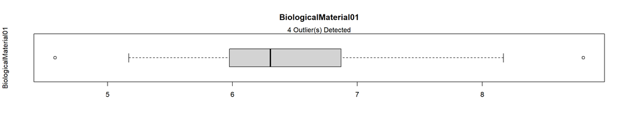

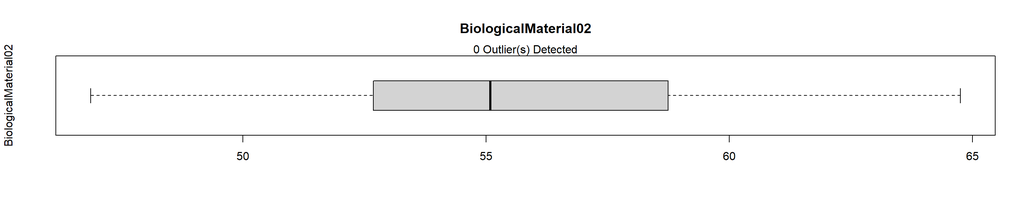

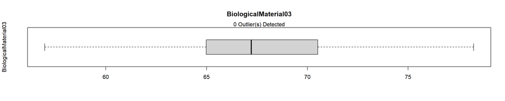

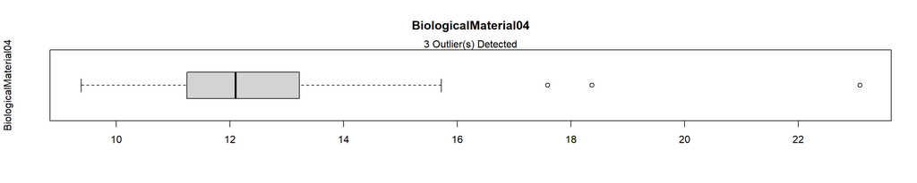

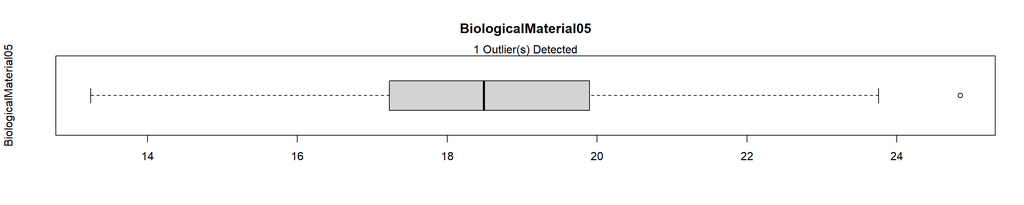

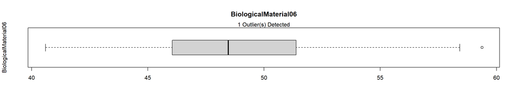

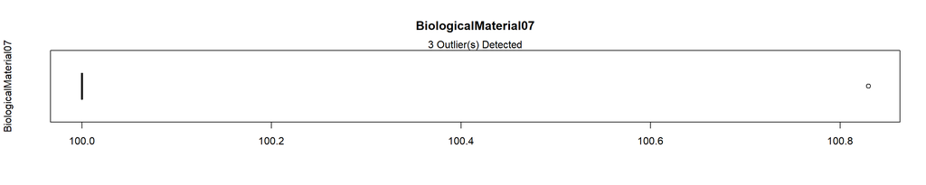

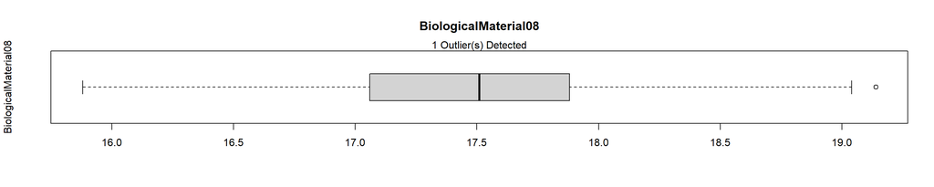

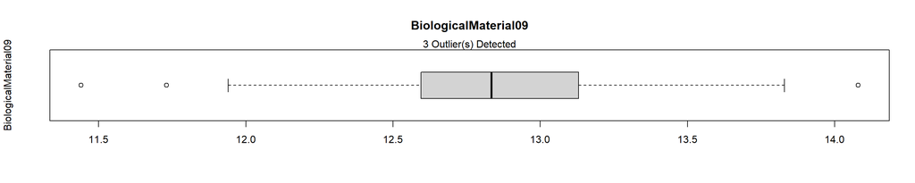

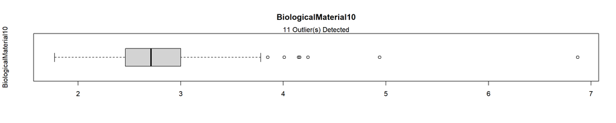

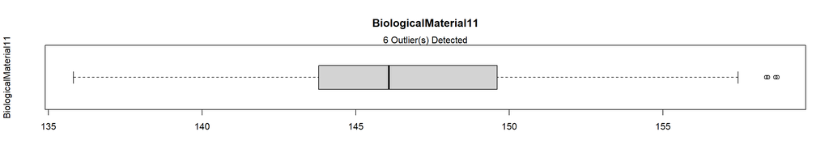

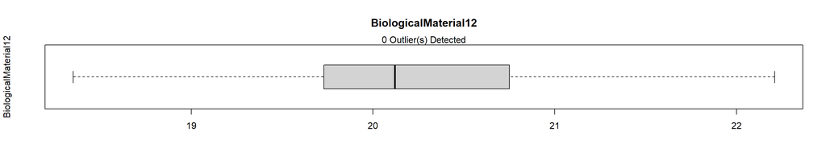

[45 more figures not shown]

```r
##################################
# Loading dataset
##################################
DPA <- ChemicalManufacturingProcess

##################################
# Listing all predictors
##################################
DPA.Predictors <- DPA[,!names(DPA) %in% c("Yield")]

##################################
# Listing all numeric predictors
##################################
DPA.Predictors.Numeric <- DPA.Predictors[,sapply(DPA.Predictors, is.numeric)]

##################################
# Identifying outliers for the numeric predictors
##################################
OutlierCountList <- c()

for (i in 1:ncol(DPA.Predictors.Numeric)) {
  Outliers <- boxplot.stats(DPA.Predictors.Numeric[,i])$out
  OutlierCount <- length(Outliers)
  OutlierCountList <- append(OutlierCountList,OutlierCount)
  OutlierIndices <- which(DPA.Predictors.Numeric[,i] %in% c(Outliers))
  boxplot(DPA.Predictors.Numeric[,i],
          ylab = names(DPA.Predictors.Numeric)[i],
          main = names(DPA.Predictors.Numeric)[i],
          horizontal=TRUE)
  mtext(paste0(OutlierCount, " Outlier(s) Detected"))
}
```

```r
OutlierCountSummary <- as.data.frame(cbind(names(DPA.Predictors.Numeric),(OutlierCountList)))
names(OutlierCountSummary) <- c("NumericPredictors","OutlierCount")
OutlierCountSummary$OutlierCount <- as.numeric(as.character(OutlierCountSummary$OutlierCount))
NumericPredictorWithOutlierCount <- nrow(OutlierCountSummary[OutlierCountSummary$OutlierCount>0,])
print(paste0(NumericPredictorWithOutlierCount, " numeric variable(s) were noted with outlier(s)." ))
```

```
## [1] "48 numeric variable(s) were noted with outlier(s)."
```

```r
##################################
# Gathering descriptive statistics
##################################
(DPA_Skimmed <- skim(DPA.Predictors.Numeric))
```

Data summary

| Name | DPA.Predictors.Numeric |
| --- | --- |
| Number of rows | 176 |
| Number of columns | 57 |
| _______________________ |  |
| Column type frequency: |  |
| numeric | 57 |
| ________________________ |  |
| Group variables | None |

**Variable type: numeric**

| skim_variable | n_missing | complete_rate | mean | sd | p0 | p25 | p50 | p75 | p100 | hist |
| --- | --- | --- | --- | --- | --- | --- | --- | --- | --- | --- |
| BiologicalMaterial01 | 0 | 1.00 | 6.41 | 0.71 | 4.58 | 5.98 | 6.30 | 6.87 | 8.81 | ▂▇▇▂▁ |
| BiologicalMaterial02 | 0 | 1.00 | 55.69 | 4.03 | 46.87 | 52.68 | 55.09 | 58.74 | 64.75 | ▂▇▆▅▃ |
| BiologicalMaterial03 | 0 | 1.00 | 67.70 | 4.00 | 56.97 | 64.98 | 67.22 | 70.43 | 78.25 | ▂▅▇▆▁ |
| BiologicalMaterial04 | 0 | 1.00 | 12.35 | 1.77 | 9.38 | 11.25 | 12.10 | 13.22 | 23.09 | ▇▆▁▁▁ |
| BiologicalMaterial05 | 0 | 1.00 | 18.60 | 1.84 | 13.24 | 17.24 | 18.49 | 19.90 | 24.85 | ▁▅▇▃▁ |
| BiologicalMaterial06 | 0 | 1.00 | 48.91 | 3.75 | 40.60 | 46.06 | 48.46 | 51.34 | 59.38 | ▂▇▆▅▁ |
| BiologicalMaterial07 | 0 | 1.00 | 100.01 | 0.11 | 100.00 | 100.00 | 100.00 | 100.00 | 100.83 | ▇▁▁▁▁ |
| BiologicalMaterial08 | 0 | 1.00 | 17.49 | 0.68 | 15.88 | 17.06 | 17.51 | 17.88 | 19.14 | ▁▅▇▃▂ |
| BiologicalMaterial09 | 0 | 1.00 | 12.85 | 0.42 | 11.44 | 12.60 | 12.84 | 13.13 | 14.08 | ▁▃▇▅▁ |
| BiologicalMaterial10 | 0 | 1.00 | 2.80 | 0.60 | 1.77 | 2.46 | 2.71 | 2.99 | 6.87 | ▇▅▁▁▁ |
| BiologicalMaterial11 | 0 | 1.00 | 146.95 | 4.82 | 135.81 | 143.82 | 146.08 | 149.60 | 158.73 | ▂▆▇▃▂ |
| BiologicalMaterial12 | 0 | 1.00 | 20.20 | 0.77 | 18.35 | 19.73 | 20.12 | 20.75 | 22.21 | ▂▆▇▃▂ |
| ManufacturingProcess01 | 1 | 0.99 | 11.21 | 1.82 | 0.00 | 10.80 | 11.40 | 12.15 | 14.10 | ▁▁▁▅▇ |
| ManufacturingProcess02 | 3 | 0.98 | 16.68 | 8.47 | 0.00 | 19.30 | 21.00 | 21.50 | 22.50 | ▂▁▁▁▇ |
| ManufacturingProcess03 | 15 | 0.91 | 1.54 | 0.02 | 1.47 | 1.53 | 1.54 | 1.55 | 1.60 | ▁▃▆▇▁ |
| ManufacturingProcess04 | 1 | 0.99 | 931.85 | 6.27 | 911.00 | 928.00 | 934.00 | 936.00 | 946.00 | ▁▂▃▇▁ |
| ManufacturingProcess05 | 1 | 0.99 | 1001.69 | 30.53 | 923.00 | 986.75 | 999.20 | 1008.85 | 1175.30 | ▁▇▁▁▁ |
| ManufacturingProcess06 | 2 | 0.99 | 207.40 | 2.70 | 203.00 | 205.70 | 206.80 | 208.70 | 227.40 | ▇▃▁▁▁ |
| ManufacturingProcess07 | 1 | 0.99 | 177.48 | 0.50 | 177.00 | 177.00 | 177.00 | 178.00 | 178.00 | ▇▁▁▁▇ |
| ManufacturingProcess08 | 1 | 0.99 | 177.55 | 0.50 | 177.00 | 177.00 | 178.00 | 178.00 | 178.00 | ▆▁▁▁▇ |
| ManufacturingProcess09 | 0 | 1.00 | 45.66 | 1.55 | 38.89 | 44.89 | 45.73 | 46.52 | 49.36 | ▁▁▅▇▂ |
| ManufacturingProcess10 | 9 | 0.95 | 9.18 | 0.77 | 7.50 | 8.70 | 9.10 | 9.55 | 11.60 | ▂▇▆▂▁ |
| ManufacturingProcess11 | 10 | 0.94 | 9.39 | 0.72 | 7.50 | 9.00 | 9.40 | 9.90 | 11.50 | ▂▆▇▅▁ |
| ManufacturingProcess12 | 1 | 0.99 | 857.81 | 1784.53 | 0.00 | 0.00 | 0.00 | 0.00 | 4549.00 | ▇▁▁▁▂ |
| ManufacturingProcess13 | 0 | 1.00 | 34.51 | 1.02 | 32.10 | 33.90 | 34.60 | 35.20 | 38.60 | ▃▇▇▁▁ |
| ManufacturingProcess14 | 1 | 0.99 | 4853.87 | 54.52 | 4701.00 | 4828.00 | 4856.00 | 4882.50 | 5055.00 | ▁▅▇▂▁ |
| ManufacturingProcess15 | 0 | 1.00 | 6038.92 | 58.31 | 5904.00 | 6010.00 | 6031.50 | 6061.00 | 6233.00 | ▂▇▆▂▁ |
| ManufacturingProcess16 | 0 | 1.00 | 4565.80 | 351.70 | 0.00 | 4560.75 | 4588.00 | 4619.00 | 4852.00 | ▁▁▁▁▇ |
| ManufacturingProcess17 | 0 | 1.00 | 34.34 | 1.25 | 31.30 | 33.50 | 34.40 | 35.10 | 40.00 | ▂▇▆▁▁ |
| ManufacturingProcess18 | 0 | 1.00 | 4809.68 | 367.48 | 0.00 | 4813.00 | 4835.00 | 4862.00 | 4971.00 | ▁▁▁▁▇ |
| ManufacturingProcess19 | 0 | 1.00 | 6028.20 | 45.58 | 5890.00 | 6000.75 | 6022.00 | 6050.25 | 6146.00 | ▁▃▇▃▂ |
| ManufacturingProcess20 | 0 | 1.00 | 4556.46 | 349.01 | 0.00 | 4552.75 | 4582.00 | 4609.50 | 4759.00 | ▁▁▁▁▇ |
| ManufacturingProcess21 | 0 | 1.00 | -0.16 | 0.78 | -1.80 | -0.60 | -0.30 | 0.00 | 3.60 | ▂▇▂▁▁ |
| ManufacturingProcess22 | 1 | 0.99 | 5.41 | 3.33 | 0.00 | 3.00 | 5.00 | 8.00 | 12.00 | ▇▇▇▅▅ |
| ManufacturingProcess23 | 1 | 0.99 | 3.02 | 1.66 | 0.00 | 2.00 | 3.00 | 4.00 | 6.00 | ▇▆▇▆▇ |
| ManufacturingProcess24 | 1 | 0.99 | 8.83 | 5.80 | 0.00 | 4.00 | 8.00 | 14.00 | 23.00 | ▇▇▅▆▁ |
| ManufacturingProcess25 | 5 | 0.97 | 4828.18 | 373.48 | 0.00 | 4832.00 | 4855.00 | 4877.00 | 4990.00 | ▁▁▁▁▇ |
| ManufacturingProcess26 | 5 | 0.97 | 6015.60 | 464.87 | 0.00 | 6019.50 | 6047.00 | 6070.50 | 6161.00 | ▁▁▁▁▇ |
| ManufacturingProcess27 | 5 | 0.97 | 4562.51 | 353.98 | 0.00 | 4560.00 | 4587.00 | 4609.00 | 4710.00 | ▁▁▁▁▇ |
| ManufacturingProcess28 | 5 | 0.97 | 6.59 | 5.25 | 0.00 | 0.00 | 10.40 | 10.75 | 11.50 | ▅▁▁▁▇ |
| ManufacturingProcess29 | 5 | 0.97 | 20.01 | 1.66 | 0.00 | 19.70 | 19.90 | 20.40 | 22.00 | ▁▁▁▁▇ |
| ManufacturingProcess30 | 5 | 0.97 | 9.16 | 0.98 | 0.00 | 8.80 | 9.10 | 9.70 | 11.20 | ▁▁▁▅▇ |
| ManufacturingProcess31 | 5 | 0.97 | 70.18 | 5.56 | 0.00 | 70.10 | 70.80 | 71.40 | 72.50 | ▁▁▁▁▇ |
| ManufacturingProcess32 | 0 | 1.00 | 158.47 | 5.40 | 143.00 | 155.00 | 158.00 | 162.00 | 173.00 | ▁▃▇▃▁ |
| ManufacturingProcess33 | 5 | 0.97 | 63.54 | 2.48 | 56.00 | 62.00 | 64.00 | 65.00 | 70.00 | ▁▃▇▅▁ |
| ManufacturingProcess34 | 5 | 0.97 | 2.49 | 0.05 | 2.30 | 2.50 | 2.50 | 2.50 | 2.60 | ▁▂▁▇▁ |
| ManufacturingProcess35 | 5 | 0.97 | 495.60 | 10.82 | 463.00 | 490.00 | 495.00 | 501.50 | 522.00 | ▁▂▇▅▂ |
| ManufacturingProcess36 | 5 | 0.97 | 0.02 | 0.00 | 0.02 | 0.02 | 0.02 | 0.02 | 0.02 | ▂▇▇▁▃ |
| ManufacturingProcess37 | 0 | 1.00 | 1.01 | 0.45 | 0.00 | 0.70 | 1.00 | 1.30 | 2.30 | ▂▇▇▃▁ |
| ManufacturingProcess38 | 0 | 1.00 | 2.53 | 0.65 | 0.00 | 2.00 | 3.00 | 3.00 | 3.00 | ▁▁▁▅▇ |
| ManufacturingProcess39 | 0 | 1.00 | 6.85 | 1.51 | 0.00 | 7.10 | 7.20 | 7.30 | 7.50 | ▁▁▁▁▇ |
| ManufacturingProcess40 | 1 | 0.99 | 0.02 | 0.04 | 0.00 | 0.00 | 0.00 | 0.00 | 0.10 | ▇▁▁▁▂ |
| ManufacturingProcess41 | 1 | 0.99 | 0.02 | 0.05 | 0.00 | 0.00 | 0.00 | 0.00 | 0.20 | ▇▁▁▁▁ |
| ManufacturingProcess42 | 0 | 1.00 | 11.21 | 1.94 | 0.00 | 11.40 | 11.60 | 11.70 | 12.10 | ▁▁▁▁▇ |
| ManufacturingProcess43 | 0 | 1.00 | 0.91 | 0.87 | 0.00 | 0.60 | 0.80 | 1.02 | 11.00 | ▇▁▁▁▁ |
| ManufacturingProcess44 | 0 | 1.00 | 1.81 | 0.32 | 0.00 | 1.80 | 1.90 | 1.90 | 2.10 | ▁▁▁▁▇ |
| ManufacturingProcess45 | 0 | 1.00 | 2.14 | 0.41 | 0.00 | 2.10 | 2.20 | 2.30 | 2.60 | ▁▁▁▂▇ |

```r
##################################
# Applying a center, scale and spatial sign data transformation
##################################
DPA_CenteredScaledSpatialSigned <- preProcess(DPA.Predictors.Numeric, method = c("center","scale","spatialSign"))
DPA_CenteredScaledSpatialSignedTransformed <- predict(DPA_CenteredScaledSpatialSigned, DPA.Predictors.Numeric)

##################################
# Gathering descriptive statistics
##################################
(DPA_CenteredScaledSpatialSignedTransformedSkimmed <- skim(DPA_CenteredScaledSpatialSignedTransformed))
```

Data summary

| Name | DPA_CenteredScaledSpatial… |
| --- | --- |
| Number of rows | 176 |
| Number of columns | 57 |
| _______________________ |  |
| Column type frequency: |  |
| numeric | 57 |
| ________________________ |  |
| Group variables | None |

**Variable type: numeric**

| skim_variable | n_missing | complete_rate | mean | sd | p0 | p25 | p50 | p75 | p100 | hist |
| --- | --- | --- | --- | --- | --- | --- | --- | --- | --- | --- |
| BiologicalMaterial01 | 0 | 1.00 | -0.01 | 0.14 | -0.35 | -0.12 | -0.02 | 0.10 | 0.28 | ▁▅▇▆▃ |
| BiologicalMaterial02 | 0 | 1.00 | -0.02 | 0.15 | -0.27 | -0.13 | -0.02 | 0.11 | 0.27 | ▆▇▆▆▃ |
| BiologicalMaterial03 | 0 | 1.00 | 0.00 | 0.15 | -0.36 | -0.12 | -0.01 | 0.12 | 0.35 | ▂▇▇▇▂ |
| BiologicalMaterial04 | 0 | 1.00 | -0.01 | 0.13 | -0.27 | -0.09 | -0.03 | 0.06 | 0.50 | ▅▇▅▂▁ |
| BiologicalMaterial05 | 0 | 1.00 | -0.01 | 0.15 | -0.41 | -0.13 | -0.01 | 0.08 | 0.53 | ▂▇▇▃▁ |
| BiologicalMaterial06 | 0 | 1.00 | -0.01 | 0.15 | -0.28 | -0.14 | -0.02 | 0.09 | 0.42 | ▆▇▇▃▁ |
| BiologicalMaterial07 | 0 | 1.00 | -0.01 | 0.10 | -0.04 | -0.03 | -0.02 | -0.02 | 0.78 | ▇▁▁▁▁ |
| BiologicalMaterial08 | 0 | 1.00 | -0.01 | 0.14 | -0.33 | -0.11 | 0.00 | 0.08 | 0.28 | ▂▆▇▇▃ |
| BiologicalMaterial09 | 0 | 1.00 | 0.01 | 0.15 | -0.46 | -0.08 | 0.00 | 0.10 | 0.35 | ▁▃▇▆▂ |
| BiologicalMaterial10 | 0 | 1.00 | -0.01 | 0.13 | -0.26 | -0.10 | -0.03 | 0.05 | 0.56 | ▃▇▂▁▁ |
| BiologicalMaterial11 | 0 | 1.00 | -0.01 | 0.14 | -0.31 | -0.10 | -0.02 | 0.09 | 0.30 | ▂▇▇▅▃ |
| BiologicalMaterial12 | 0 | 1.00 | -0.01 | 0.14 | -0.34 | -0.11 | -0.01 | 0.09 | 0.38 | ▂▇▇▅▁ |
| ManufacturingProcess01 | 1 | 0.99 | 0.01 | 0.12 | -0.62 | -0.04 | 0.02 | 0.08 | 0.24 | ▁▁▂▇▅ |
| ManufacturingProcess02 | 3 | 0.98 | 0.02 | 0.14 | -0.32 | 0.04 | 0.08 | 0.11 | 0.17 | ▂▁▁▅▇ |
| ManufacturingProcess03 | 15 | 0.91 | 0.00 | 0.16 | -0.57 | -0.07 | 0.00 | 0.09 | 0.50 | ▁▂▇▆▁ |
| ManufacturingProcess04 | 1 | 0.99 | 0.02 | 0.15 | -0.37 | -0.10 | 0.04 | 0.12 | 0.37 | ▂▅▇▇▂ |
| ManufacturingProcess05 | 1 | 0.99 | -0.01 | 0.13 | -0.41 | -0.08 | -0.01 | 0.04 | 0.77 | ▁▇▂▁▁ |
| ManufacturingProcess06 | 2 | 0.99 | -0.01 | 0.14 | -0.26 | -0.10 | -0.03 | 0.06 | 0.75 | ▇▇▂▁▁ |
| ManufacturingProcess07 | 1 | 0.99 | 0.00 | 0.17 | -0.28 | -0.16 | -0.08 | 0.17 | 0.28 | ▇▇▁▇▆ |
| ManufacturingProcess08 | 1 | 0.99 | 0.00 | 0.17 | -0.32 | -0.17 | 0.09 | 0.16 | 0.25 | ▃▇▁▅▇ |
| ManufacturingProcess09 | 0 | 1.00 | -0.01 | 0.14 | -0.42 | -0.09 | 0.01 | 0.09 | 0.32 | ▁▃▆▇▂ |
| ManufacturingProcess10 | 9 | 0.95 | -0.01 | 0.15 | -0.37 | -0.12 | -0.02 | 0.07 | 0.37 | ▂▅▇▃▁ |
| ManufacturingProcess11 | 10 | 0.94 | -0.01 | 0.15 | -0.38 | -0.10 | 0.00 | 0.09 | 0.34 | ▂▃▇▆▂ |
| ManufacturingProcess12 | 1 | 0.99 | -0.01 | 0.16 | -0.14 | -0.09 | -0.07 | -0.05 | 0.41 | ▇▁▁▁▁ |
| ManufacturingProcess13 | 0 | 1.00 | 0.01 | 0.14 | -0.39 | -0.09 | 0.01 | 0.11 | 0.36 | ▁▅▇▆▁ |
| ManufacturingProcess14 | 1 | 0.99 | 0.00 | 0.14 | -0.36 | -0.08 | 0.01 | 0.09 | 0.33 | ▁▃▇▅▂ |
| ManufacturingProcess15 | 0 | 1.00 | 0.00 | 0.14 | -0.32 | -0.08 | -0.02 | 0.06 | 0.36 | ▂▅▇▂▂ |
| ManufacturingProcess16 | 0 | 1.00 | 0.01 | 0.07 | -0.87 | 0.00 | 0.01 | 0.03 | 0.13 | ▁▁▁▁▇ |
| ManufacturingProcess17 | 0 | 1.00 | 0.00 | 0.13 | -0.33 | -0.10 | 0.01 | 0.09 | 0.44 | ▂▇▇▂▁ |
| ManufacturingProcess18 | 0 | 1.00 | 0.01 | 0.05 | -0.64 | 0.00 | 0.01 | 0.02 | 0.07 | ▁▁▁▁▇ |
| ManufacturingProcess19 | 0 | 1.00 | -0.01 | 0.14 | -0.44 | -0.10 | -0.02 | 0.08 | 0.47 | ▁▅▇▃▁ |
| ManufacturingProcess20 | 0 | 1.00 | 0.01 | 0.05 | -0.63 | 0.00 | 0.01 | 0.02 | 0.09 | ▁▁▁▁▇ |
| ManufacturingProcess21 | 0 | 1.00 | -0.02 | 0.13 | -0.32 | -0.09 | -0.02 | 0.04 | 0.40 | ▂▇▇▂▁ |
| ManufacturingProcess22 | 1 | 0.99 | 0.00 | 0.17 | -0.30 | -0.13 | -0.02 | 0.12 | 0.45 | ▃▇▅▃▁ |
| ManufacturingProcess23 | 1 | 0.99 | 0.01 | 0.17 | -0.27 | -0.12 | 0.00 | 0.11 | 0.52 | ▇▇▅▃▁ |
| ManufacturingProcess24 | 1 | 0.99 | 0.00 | 0.16 | -0.26 | -0.12 | -0.03 | 0.14 | 0.33 | ▅▇▅▅▃ |
| ManufacturingProcess25 | 5 | 0.97 | 0.01 | 0.04 | -0.43 | 0.00 | 0.01 | 0.02 | 0.07 | ▁▁▁▁▇ |
| ManufacturingProcess26 | 5 | 0.97 | 0.01 | 0.04 | -0.43 | 0.00 | 0.01 | 0.02 | 0.06 | ▁▁▁▁▇ |
| ManufacturingProcess27 | 5 | 0.97 | 0.01 | 0.04 | -0.43 | 0.00 | 0.01 | 0.02 | 0.06 | ▁▁▁▁▇ |
| ManufacturingProcess28 | 5 | 0.97 | -0.01 | 0.17 | -0.31 | -0.21 | 0.09 | 0.13 | 0.21 | ▅▂▁▅▇ |
| ManufacturingProcess29 | 5 | 0.97 | 0.00 | 0.06 | -0.40 | -0.03 | -0.01 | 0.03 | 0.18 | ▁▁▂▇▂ |
| ManufacturingProcess30 | 5 | 0.97 | 0.00 | 0.11 | -0.31 | -0.07 | -0.01 | 0.08 | 0.24 | ▁▃▇▇▂ |
| ManufacturingProcess31 | 5 | 0.97 | 0.01 | 0.05 | -0.42 | 0.00 | 0.02 | 0.04 | 0.08 | ▁▁▁▁▇ |
| ManufacturingProcess32 | 0 | 1.00 | -0.01 | 0.15 | -0.32 | -0.10 | -0.01 | 0.08 | 0.39 | ▃▆▇▅▁ |
| ManufacturingProcess33 | 5 | 0.97 | -0.01 | 0.15 | -0.42 | -0.12 | 0.03 | 0.10 | 0.34 | ▂▅▇▇▂ |
| ManufacturingProcess34 | 5 | 0.97 | 0.00 | 0.16 | -0.60 | 0.01 | 0.02 | 0.02 | 0.42 | ▁▂▂▇▁ |
| ManufacturingProcess35 | 5 | 0.97 | 0.00 | 0.16 | -0.43 | -0.08 | -0.01 | 0.09 | 0.47 | ▁▃▇▂▁ |
| ManufacturingProcess36 | 5 | 0.97 | 0.00 | 0.15 | -0.33 | -0.11 | 0.04 | 0.10 | 0.34 | ▁▇▂▆▂ |
| ManufacturingProcess37 | 0 | 1.00 | 0.00 | 0.16 | -0.39 | -0.11 | -0.01 | 0.08 | 0.42 | ▂▅▇▃▁ |
| ManufacturingProcess38 | 0 | 1.00 | 0.01 | 0.14 | -0.32 | -0.13 | 0.08 | 0.12 | 0.18 | ▁▃▂▁▇ |
| ManufacturingProcess39 | 0 | 1.00 | 0.01 | 0.11 | -0.68 | 0.02 | 0.03 | 0.05 | 0.09 | ▁▁▁▁▇ |
| ManufacturingProcess40 | 1 | 0.99 | 0.00 | 0.16 | -0.13 | -0.09 | -0.07 | -0.05 | 0.48 | ▇▁▁▁▁ |
| ManufacturingProcess41 | 1 | 0.99 | -0.01 | 0.15 | -0.13 | -0.08 | -0.07 | -0.04 | 0.59 | ▇▁▁▁▁ |
| ManufacturingProcess42 | 0 | 1.00 | 0.01 | 0.08 | -0.47 | 0.01 | 0.03 | 0.04 | 0.09 | ▁▁▁▁▇ |
| ManufacturingProcess43 | 0 | 1.00 | -0.01 | 0.10 | -0.17 | -0.06 | -0.02 | 0.02 | 0.84 | ▇▂▁▁▁ |
| ManufacturingProcess44 | 0 | 1.00 | 0.02 | 0.09 | -0.46 | 0.00 | 0.03 | 0.06 | 0.17 | ▁▁▁▇▇ |
| ManufacturingProcess45 | 0 | 1.00 | 0.01 | 0.10 | -0.43 | -0.02 | 0.03 | 0.08 | 0.20 | ▁▁▂▇▅ |

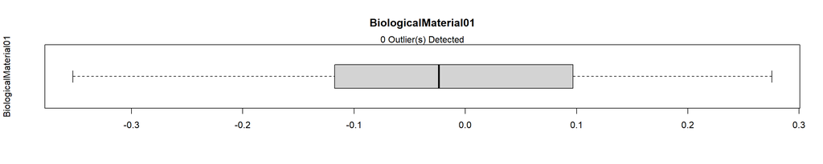

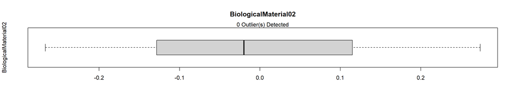

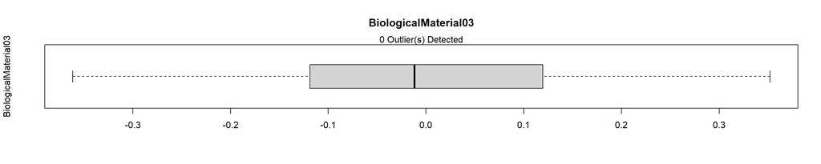

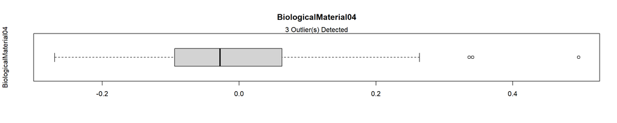

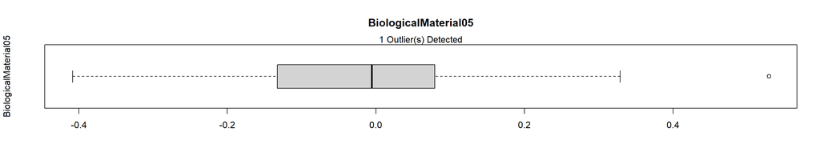

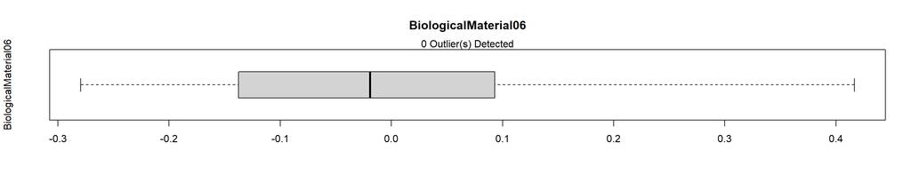

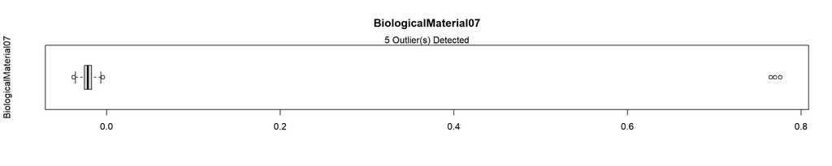

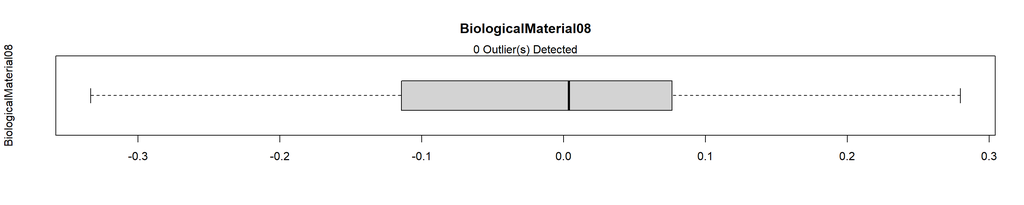

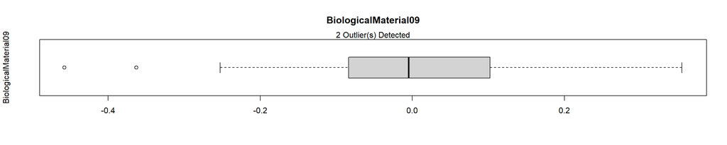

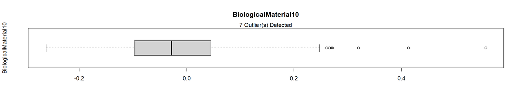

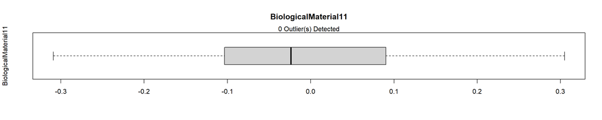

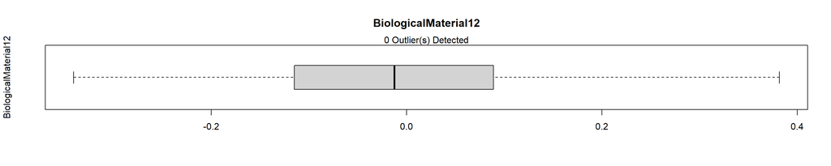

[45 more figures not shown]

```r
##################################
# Identifying outliers for the numeric predictors
##################################
OutlierCountList <- c()

for (i in 1:ncol(DPA.Predictors.Numeric)) {
  Outliers <- boxplot.stats(DPA_CenteredScaledSpatialSignedTransformed[,i])$out
  OutlierCount <- length(Outliers)
  OutlierCountList <- append(OutlierCountList,OutlierCount)
  OutlierIndices <- which(DPA.Predictors.Numeric[,i] %in% c(Outliers))
  boxplot(DPA_CenteredScaledSpatialSignedTransformed[,i],
          ylab = names(DPA.Predictors.Numeric)[i],
          main = names(DPA.Predictors.Numeric)[i],
          horizontal=TRUE)
  mtext(paste0(OutlierCount, " Outlier(s) Detected"))
}
```

```r
OutlierCountSummary <- as.data.frame(cbind(names(DPA.Predictors.Numeric),(OutlierCountList)))
names(OutlierCountSummary) <- c("NumericPredictors","OutlierCount")
OutlierCountSummary$OutlierCount <- as.numeric(as.character(OutlierCountSummary$OutlierCount))
NumericPredictorWithOutlierCount <- nrow(OutlierCountSummary[OutlierCountSummary$OutlierCount>0,])
print(paste0(NumericPredictorWithOutlierCount, " numeric variable(s) were noted with outlier(s)." ))
```

```
## [1] "40 numeric variable(s) were noted with outlier(s)."
```

### 1.3.3 Zero and Near-Zero Variance

Zero and near-zero variance data assessment:  
**[A]** Low variance noted for 3 variables from the previous data quality assessment.  
**[B]** Low variance noted for 6 variables confirmed using a preprocessing summary from the **caret** package.  
**[C]** The **caret** package includes two methods for detecting low variance variables:  
**[C.1]** The nearZeroVar method using the freqCut criteria with default setting at 95/5 computes the frequency of the most prevalent value over the second most frequent value (called the “frequency ratio’’), which would be near one for well-behaved predictors and very large for highly-unbalanced data.  
**[C.2]** The nearZeroVar method using the uniqueCut criteria with default setting at 10 computes the percent of unique values referring to the number of unique values divided by the total number of samples (times 100) that approaches zero as the granularity of the data increases.  
**[D]** The nearZeroVar method using both the freqCut and uniqueCut criteria set at 80/20 and 10, respectively, were applied on the dataset:  
**[D.1]** 6 variables may be optionally removed from the dataset for the subsequent analysis.

**Code Chunk | Output**

```r
##################################
# Loading dataset
##################################
DPA <- ChemicalManufacturingProcess

##################################
# Gathering descriptive statistics
##################################
(DPA_Skimmed <- skim(DPA))
```

Data summary

| Name | DPA |
| --- | --- |
| Number of rows | 176 |
| Number of columns | 58 |
| _______________________ |  |
| Column type frequency: |  |
| numeric | 58 |
| ________________________ |  |
| Group variables | None |

**Variable type: numeric**

| skim_variable | n_missing | complete_rate | mean | sd | p0 | p25 | p50 | p75 | p100 | hist |
| --- | --- | --- | --- | --- | --- | --- | --- | --- | --- | --- |
| Yield | 0 | 1.00 | 40.18 | 1.85 | 35.25 | 38.75 | 39.97 | 41.48 | 46.34 | ▁▇▇▃▁ |
| BiologicalMaterial01 | 0 | 1.00 | 6.41 | 0.71 | 4.58 | 5.98 | 6.30 | 6.87 | 8.81 | ▂▇▇▂▁ |
| BiologicalMaterial02 | 0 | 1.00 | 55.69 | 4.03 | 46.87 | 52.68 | 55.09 | 58.74 | 64.75 | ▂▇▆▅▃ |
| BiologicalMaterial03 | 0 | 1.00 | 67.70 | 4.00 | 56.97 | 64.98 | 67.22 | 70.43 | 78.25 | ▂▅▇▆▁ |
| BiologicalMaterial04 | 0 | 1.00 | 12.35 | 1.77 | 9.38 | 11.25 | 12.10 | 13.22 | 23.09 | ▇▆▁▁▁ |
| BiologicalMaterial05 | 0 | 1.00 | 18.60 | 1.84 | 13.24 | 17.24 | 18.49 | 19.90 | 24.85 | ▁▅▇▃▁ |
| BiologicalMaterial06 | 0 | 1.00 | 48.91 | 3.75 | 40.60 | 46.06 | 48.46 | 51.34 | 59.38 | ▂▇▆▅▁ |
| BiologicalMaterial07 | 0 | 1.00 | 100.01 | 0.11 | 100.00 | 100.00 | 100.00 | 100.00 | 100.83 | ▇▁▁▁▁ |
| BiologicalMaterial08 | 0 | 1.00 | 17.49 | 0.68 | 15.88 | 17.06 | 17.51 | 17.88 | 19.14 | ▁▅▇▃▂ |
| BiologicalMaterial09 | 0 | 1.00 | 12.85 | 0.42 | 11.44 | 12.60 | 12.84 | 13.13 | 14.08 | ▁▃▇▅▁ |
| BiologicalMaterial10 | 0 | 1.00 | 2.80 | 0.60 | 1.77 | 2.46 | 2.71 | 2.99 | 6.87 | ▇▅▁▁▁ |
| BiologicalMaterial11 | 0 | 1.00 | 146.95 | 4.82 | 135.81 | 143.82 | 146.08 | 149.60 | 158.73 | ▂▆▇▃▂ |
| BiologicalMaterial12 | 0 | 1.00 | 20.20 | 0.77 | 18.35 | 19.73 | 20.12 | 20.75 | 22.21 | ▂▆▇▃▂ |
| ManufacturingProcess01 | 1 | 0.99 | 11.21 | 1.82 | 0.00 | 10.80 | 11.40 | 12.15 | 14.10 | ▁▁▁▅▇ |
| ManufacturingProcess02 | 3 | 0.98 | 16.68 | 8.47 | 0.00 | 19.30 | 21.00 | 21.50 | 22.50 | ▂▁▁▁▇ |
| ManufacturingProcess03 | 15 | 0.91 | 1.54 | 0.02 | 1.47 | 1.53 | 1.54 | 1.55 | 1.60 | ▁▃▆▇▁ |
| ManufacturingProcess04 | 1 | 0.99 | 931.85 | 6.27 | 911.00 | 928.00 | 934.00 | 936.00 | 946.00 | ▁▂▃▇▁ |
| ManufacturingProcess05 | 1 | 0.99 | 1001.69 | 30.53 | 923.00 | 986.75 | 999.20 | 1008.85 | 1175.30 | ▁▇▁▁▁ |
| ManufacturingProcess06 | 2 | 0.99 | 207.40 | 2.70 | 203.00 | 205.70 | 206.80 | 208.70 | 227.40 | ▇▃▁▁▁ |
| ManufacturingProcess07 | 1 | 0.99 | 177.48 | 0.50 | 177.00 | 177.00 | 177.00 | 178.00 | 178.00 | ▇▁▁▁▇ |
| ManufacturingProcess08 | 1 | 0.99 | 177.55 | 0.50 | 177.00 | 177.00 | 178.00 | 178.00 | 178.00 | ▆▁▁▁▇ |
| ManufacturingProcess09 | 0 | 1.00 | 45.66 | 1.55 | 38.89 | 44.89 | 45.73 | 46.52 | 49.36 | ▁▁▅▇▂ |
| ManufacturingProcess10 | 9 | 0.95 | 9.18 | 0.77 | 7.50 | 8.70 | 9.10 | 9.55 | 11.60 | ▂▇▆▂▁ |
| ManufacturingProcess11 | 10 | 0.94 | 9.39 | 0.72 | 7.50 | 9.00 | 9.40 | 9.90 | 11.50 | ▂▆▇▅▁ |
| ManufacturingProcess12 | 1 | 0.99 | 857.81 | 1784.53 | 0.00 | 0.00 | 0.00 | 0.00 | 4549.00 | ▇▁▁▁▂ |
| ManufacturingProcess13 | 0 | 1.00 | 34.51 | 1.02 | 32.10 | 33.90 | 34.60 | 35.20 | 38.60 | ▃▇▇▁▁ |
| ManufacturingProcess14 | 1 | 0.99 | 4853.87 | 54.52 | 4701.00 | 4828.00 | 4856.00 | 4882.50 | 5055.00 | ▁▅▇▂▁ |
| ManufacturingProcess15 | 0 | 1.00 | 6038.92 | 58.31 | 5904.00 | 6010.00 | 6031.50 | 6061.00 | 6233.00 | ▂▇▆▂▁ |
| ManufacturingProcess16 | 0 | 1.00 | 4565.80 | 351.70 | 0.00 | 4560.75 | 4588.00 | 4619.00 | 4852.00 | ▁▁▁▁▇ |
| ManufacturingProcess17 | 0 | 1.00 | 34.34 | 1.25 | 31.30 | 33.50 | 34.40 | 35.10 | 40.00 | ▂▇▆▁▁ |
| ManufacturingProcess18 | 0 | 1.00 | 4809.68 | 367.48 | 0.00 | 4813.00 | 4835.00 | 4862.00 | 4971.00 | ▁▁▁▁▇ |
| ManufacturingProcess19 | 0 | 1.00 | 6028.20 | 45.58 | 5890.00 | 6000.75 | 6022.00 | 6050.25 | 6146.00 | ▁▃▇▃▂ |
| ManufacturingProcess20 | 0 | 1.00 | 4556.46 | 349.01 | 0.00 | 4552.75 | 4582.00 | 4609.50 | 4759.00 | ▁▁▁▁▇ |
| ManufacturingProcess21 | 0 | 1.00 | -0.16 | 0.78 | -1.80 | -0.60 | -0.30 | 0.00 | 3.60 | ▂▇▂▁▁ |
| ManufacturingProcess22 | 1 | 0.99 | 5.41 | 3.33 | 0.00 | 3.00 | 5.00 | 8.00 | 12.00 | ▇▇▇▅▅ |
| ManufacturingProcess23 | 1 | 0.99 | 3.02 | 1.66 | 0.00 | 2.00 | 3.00 | 4.00 | 6.00 | ▇▆▇▆▇ |
| ManufacturingProcess24 | 1 | 0.99 | 8.83 | 5.80 | 0.00 | 4.00 | 8.00 | 14.00 | 23.00 | ▇▇▅▆▁ |
| ManufacturingProcess25 | 5 | 0.97 | 4828.18 | 373.48 | 0.00 | 4832.00 | 4855.00 | 4877.00 | 4990.00 | ▁▁▁▁▇ |
| ManufacturingProcess26 | 5 | 0.97 | 6015.60 | 464.87 | 0.00 | 6019.50 | 6047.00 | 6070.50 | 6161.00 | ▁▁▁▁▇ |
| ManufacturingProcess27 | 5 | 0.97 | 4562.51 | 353.98 | 0.00 | 4560.00 | 4587.00 | 4609.00 | 4710.00 | ▁▁▁▁▇ |
| ManufacturingProcess28 | 5 | 0.97 | 6.59 | 5.25 | 0.00 | 0.00 | 10.40 | 10.75 | 11.50 | ▅▁▁▁▇ |
| ManufacturingProcess29 | 5 | 0.97 | 20.01 | 1.66 | 0.00 | 19.70 | 19.90 | 20.40 | 22.00 | ▁▁▁▁▇ |
| ManufacturingProcess30 | 5 | 0.97 | 9.16 | 0.98 | 0.00 | 8.80 | 9.10 | 9.70 | 11.20 | ▁▁▁▅▇ |
| ManufacturingProcess31 | 5 | 0.97 | 70.18 | 5.56 | 0.00 | 70.10 | 70.80 | 71.40 | 72.50 | ▁▁▁▁▇ |
| ManufacturingProcess32 | 0 | 1.00 | 158.47 | 5.40 | 143.00 | 155.00 | 158.00 | 162.00 | 173.00 | ▁▃▇▃▁ |
| ManufacturingProcess33 | 5 | 0.97 | 63.54 | 2.48 | 56.00 | 62.00 | 64.00 | 65.00 | 70.00 | ▁▃▇▅▁ |
| ManufacturingProcess34 | 5 | 0.97 | 2.49 | 0.05 | 2.30 | 2.50 | 2.50 | 2.50 | 2.60 | ▁▂▁▇▁ |
| ManufacturingProcess35 | 5 | 0.97 | 495.60 | 10.82 | 463.00 | 490.00 | 495.00 | 501.50 | 522.00 | ▁▂▇▅▂ |
| ManufacturingProcess36 | 5 | 0.97 | 0.02 | 0.00 | 0.02 | 0.02 | 0.02 | 0.02 | 0.02 | ▂▇▇▁▃ |
| ManufacturingProcess37 | 0 | 1.00 | 1.01 | 0.45 | 0.00 | 0.70 | 1.00 | 1.30 | 2.30 | ▂▇▇▃▁ |
| ManufacturingProcess38 | 0 | 1.00 | 2.53 | 0.65 | 0.00 | 2.00 | 3.00 | 3.00 | 3.00 | ▁▁▁▅▇ |
| ManufacturingProcess39 | 0 | 1.00 | 6.85 | 1.51 | 0.00 | 7.10 | 7.20 | 7.30 | 7.50 | ▁▁▁▁▇ |
| ManufacturingProcess40 | 1 | 0.99 | 0.02 | 0.04 | 0.00 | 0.00 | 0.00 | 0.00 | 0.10 | ▇▁▁▁▂ |
| ManufacturingProcess41 | 1 | 0.99 | 0.02 | 0.05 | 0.00 | 0.00 | 0.00 | 0.00 | 0.20 | ▇▁▁▁▁ |
| ManufacturingProcess42 | 0 | 1.00 | 11.21 | 1.94 | 0.00 | 11.40 | 11.60 | 11.70 | 12.10 | ▁▁▁▁▇ |
| ManufacturingProcess43 | 0 | 1.00 | 0.91 | 0.87 | 0.00 | 0.60 | 0.80 | 1.02 | 11.00 | ▇▁▁▁▁ |
| ManufacturingProcess44 | 0 | 1.00 | 1.81 | 0.32 | 0.00 | 1.80 | 1.90 | 1.90 | 2.10 | ▁▁▁▁▇ |
| ManufacturingProcess45 | 0 | 1.00 | 2.14 | 0.41 | 0.00 | 2.10 | 2.20 | 2.30 | 2.60 | ▁▁▁▂▇ |

```r
##################################
# Identifying columns with low variance
###################################
DPA_LowVariance <- nearZeroVar(DPA,
                               freqCut = 80/20,
                               uniqueCut = 10,
                               saveMetrics= TRUE)
(DPA_LowVariance[DPA_LowVariance$nzv,])
```

```
##                        freqRatio percentUnique zeroVar  nzv
## BiologicalMaterial07   57.666667      1.136364   FALSE TRUE
## ManufacturingProcess12  4.303030      1.136364   FALSE TRUE
## ManufacturingProcess28  5.076923      9.659091   FALSE TRUE
## ManufacturingProcess34  4.392857      2.272727   FALSE TRUE
## ManufacturingProcess40  4.645161      1.136364   FALSE TRUE
## ManufacturingProcess41  6.500000      2.272727   FALSE TRUE
```

```r
if ((nrow(DPA_LowVariance[DPA_LowVariance$nzv,]))==0){

  print("No low variance predictors noted.")

} else {

  print(paste0("Low variance observed for ",
               (nrow(DPA_LowVariance[DPA_LowVariance$nzv,])),
               " numeric variable(s) with First.Second.Mode.Ratio>4 and Unique.Count.Ratio<0.10."))

  DPA_LowVarianceForRemoval <- (nrow(DPA_LowVariance[DPA_LowVariance$nzv,]))

  print(paste0("Low variance can be resolved by removing ",
               (nrow(DPA_LowVariance[DPA_LowVariance$nzv,])),
               " numeric variable(s)."))

  for (j in 1:DPA_LowVarianceForRemoval) {
  DPA_LowVarianceRemovedVariable <- rownames(DPA_LowVariance[DPA_LowVariance$nzv,])[j]
  print(paste0("Variable ",
               j,
               " for removal: ",
               DPA_LowVarianceRemovedVariable))
  }

  DPA %>%
  skim() %>%
  dplyr::filter(skim_variable %in% rownames(DPA_LowVariance[DPA_LowVariance$nzv,]))

  ##################################
  # Filtering out columns with low variance
  #################################
  DPA_ExcludedLowVariance <- DPA[,!names(DPA) %in% rownames(DPA_LowVariance[DPA_LowVariance$nzv,])]

  ##################################
  # Gathering descriptive statistics
  ##################################
  (DPA_ExcludedLowVariance_Skimmed <- skim(DPA_ExcludedLowVariance))
}
```

```
## [1] "Low variance observed for 6 numeric variable(s) with First.Second.Mode.Ratio>4 and Unique.Count.Ratio<0.10."
## [1] "Low variance can be resolved by removing 6 numeric variable(s)."
## [1] "Variable 1 for removal: BiologicalMaterial07"
## [1] "Variable 2 for removal: ManufacturingProcess12"
## [1] "Variable 3 for removal: ManufacturingProcess28"
## [1] "Variable 4 for removal: ManufacturingProcess34"
## [1] "Variable 5 for removal: ManufacturingProcess40"
## [1] "Variable 6 for removal: ManufacturingProcess41"
```

Data summary

| Name | DPA_ExcludedLowVariance |
| --- | --- |
| Number of rows | 176 |
| Number of columns | 52 |
| _______________________ |  |
| Column type frequency: |  |
| numeric | 52 |
| ________________________ |  |
| Group variables | None |

**Variable type: numeric**

| skim_variable | n_missing | complete_rate | mean | sd | p0 | p25 | p50 | p75 | p100 | hist |
| --- | --- | --- | --- | --- | --- | --- | --- | --- | --- | --- |
| Yield | 0 | 1.00 | 40.18 | 1.85 | 35.25 | 38.75 | 39.97 | 41.48 | 46.34 | ▁▇▇▃▁ |
| BiologicalMaterial01 | 0 | 1.00 | 6.41 | 0.71 | 4.58 | 5.98 | 6.30 | 6.87 | 8.81 | ▂▇▇▂▁ |
| BiologicalMaterial02 | 0 | 1.00 | 55.69 | 4.03 | 46.87 | 52.68 | 55.09 | 58.74 | 64.75 | ▂▇▆▅▃ |
| BiologicalMaterial03 | 0 | 1.00 | 67.70 | 4.00 | 56.97 | 64.98 | 67.22 | 70.43 | 78.25 | ▂▅▇▆▁ |
| BiologicalMaterial04 | 0 | 1.00 | 12.35 | 1.77 | 9.38 | 11.25 | 12.10 | 13.22 | 23.09 | ▇▆▁▁▁ |
| BiologicalMaterial05 | 0 | 1.00 | 18.60 | 1.84 | 13.24 | 17.24 | 18.49 | 19.90 | 24.85 | ▁▅▇▃▁ |
| BiologicalMaterial06 | 0 | 1.00 | 48.91 | 3.75 | 40.60 | 46.06 | 48.46 | 51.34 | 59.38 | ▂▇▆▅▁ |
| BiologicalMaterial08 | 0 | 1.00 | 17.49 | 0.68 | 15.88 | 17.06 | 17.51 | 17.88 | 19.14 | ▁▅▇▃▂ |
| BiologicalMaterial09 | 0 | 1.00 | 12.85 | 0.42 | 11.44 | 12.60 | 12.84 | 13.13 | 14.08 | ▁▃▇▅▁ |
| BiologicalMaterial10 | 0 | 1.00 | 2.80 | 0.60 | 1.77 | 2.46 | 2.71 | 2.99 | 6.87 | ▇▅▁▁▁ |
| BiologicalMaterial11 | 0 | 1.00 | 146.95 | 4.82 | 135.81 | 143.82 | 146.08 | 149.60 | 158.73 | ▂▆▇▃▂ |
| BiologicalMaterial12 | 0 | 1.00 | 20.20 | 0.77 | 18.35 | 19.73 | 20.12 | 20.75 | 22.21 | ▂▆▇▃▂ |
| ManufacturingProcess01 | 1 | 0.99 | 11.21 | 1.82 | 0.00 | 10.80 | 11.40 | 12.15 | 14.10 | ▁▁▁▅▇ |
| ManufacturingProcess02 | 3 | 0.98 | 16.68 | 8.47 | 0.00 | 19.30 | 21.00 | 21.50 | 22.50 | ▂▁▁▁▇ |
| ManufacturingProcess03 | 15 | 0.91 | 1.54 | 0.02 | 1.47 | 1.53 | 1.54 | 1.55 | 1.60 | ▁▃▆▇▁ |
| ManufacturingProcess04 | 1 | 0.99 | 931.85 | 6.27 | 911.00 | 928.00 | 934.00 | 936.00 | 946.00 | ▁▂▃▇▁ |
| ManufacturingProcess05 | 1 | 0.99 | 1001.69 | 30.53 | 923.00 | 986.75 | 999.20 | 1008.85 | 1175.30 | ▁▇▁▁▁ |
| ManufacturingProcess06 | 2 | 0.99 | 207.40 | 2.70 | 203.00 | 205.70 | 206.80 | 208.70 | 227.40 | ▇▃▁▁▁ |
| ManufacturingProcess07 | 1 | 0.99 | 177.48 | 0.50 | 177.00 | 177.00 | 177.00 | 178.00 | 178.00 | ▇▁▁▁▇ |
| ManufacturingProcess08 | 1 | 0.99 | 177.55 | 0.50 | 177.00 | 177.00 | 178.00 | 178.00 | 178.00 | ▆▁▁▁▇ |
| ManufacturingProcess09 | 0 | 1.00 | 45.66 | 1.55 | 38.89 | 44.89 | 45.73 | 46.52 | 49.36 | ▁▁▅▇▂ |
| ManufacturingProcess10 | 9 | 0.95 | 9.18 | 0.77 | 7.50 | 8.70 | 9.10 | 9.55 | 11.60 | ▂▇▆▂▁ |
| ManufacturingProcess11 | 10 | 0.94 | 9.39 | 0.72 | 7.50 | 9.00 | 9.40 | 9.90 | 11.50 | ▂▆▇▅▁ |
| ManufacturingProcess13 | 0 | 1.00 | 34.51 | 1.02 | 32.10 | 33.90 | 34.60 | 35.20 | 38.60 | ▃▇▇▁▁ |
| ManufacturingProcess14 | 1 | 0.99 | 4853.87 | 54.52 | 4701.00 | 4828.00 | 4856.00 | 4882.50 | 5055.00 | ▁▅▇▂▁ |
| ManufacturingProcess15 | 0 | 1.00 | 6038.92 | 58.31 | 5904.00 | 6010.00 | 6031.50 | 6061.00 | 6233.00 | ▂▇▆▂▁ |
| ManufacturingProcess16 | 0 | 1.00 | 4565.80 | 351.70 | 0.00 | 4560.75 | 4588.00 | 4619.00 | 4852.00 | ▁▁▁▁▇ |
| ManufacturingProcess17 | 0 | 1.00 | 34.34 | 1.25 | 31.30 | 33.50 | 34.40 | 35.10 | 40.00 | ▂▇▆▁▁ |
| ManufacturingProcess18 | 0 | 1.00 | 4809.68 | 367.48 | 0.00 | 4813.00 | 4835.00 | 4862.00 | 4971.00 | ▁▁▁▁▇ |
| ManufacturingProcess19 | 0 | 1.00 | 6028.20 | 45.58 | 5890.00 | 6000.75 | 6022.00 | 6050.25 | 6146.00 | ▁▃▇▃▂ |
| ManufacturingProcess20 | 0 | 1.00 | 4556.46 | 349.01 | 0.00 | 4552.75 | 4582.00 | 4609.50 | 4759.00 | ▁▁▁▁▇ |
| ManufacturingProcess21 | 0 | 1.00 | -0.16 | 0.78 | -1.80 | -0.60 | -0.30 | 0.00 | 3.60 | ▂▇▂▁▁ |
| ManufacturingProcess22 | 1 | 0.99 | 5.41 | 3.33 | 0.00 | 3.00 | 5.00 | 8.00 | 12.00 | ▇▇▇▅▅ |
| ManufacturingProcess23 | 1 | 0.99 | 3.02 | 1.66 | 0.00 | 2.00 | 3.00 | 4.00 | 6.00 | ▇▆▇▆▇ |
| ManufacturingProcess24 | 1 | 0.99 | 8.83 | 5.80 | 0.00 | 4.00 | 8.00 | 14.00 | 23.00 | ▇▇▅▆▁ |
| ManufacturingProcess25 | 5 | 0.97 | 4828.18 | 373.48 | 0.00 | 4832.00 | 4855.00 | 4877.00 | 4990.00 | ▁▁▁▁▇ |
| ManufacturingProcess26 | 5 | 0.97 | 6015.60 | 464.87 | 0.00 | 6019.50 | 6047.00 | 6070.50 | 6161.00 | ▁▁▁▁▇ |
| ManufacturingProcess27 | 5 | 0.97 | 4562.51 | 353.98 | 0.00 | 4560.00 | 4587.00 | 4609.00 | 4710.00 | ▁▁▁▁▇ |
| ManufacturingProcess29 | 5 | 0.97 | 20.01 | 1.66 | 0.00 | 19.70 | 19.90 | 20.40 | 22.00 | ▁▁▁▁▇ |
| ManufacturingProcess30 | 5 | 0.97 | 9.16 | 0.98 | 0.00 | 8.80 | 9.10 | 9.70 | 11.20 | ▁▁▁▅▇ |
| ManufacturingProcess31 | 5 | 0.97 | 70.18 | 5.56 | 0.00 | 70.10 | 70.80 | 71.40 | 72.50 | ▁▁▁▁▇ |
| ManufacturingProcess32 | 0 | 1.00 | 158.47 | 5.40 | 143.00 | 155.00 | 158.00 | 162.00 | 173.00 | ▁▃▇▃▁ |
| ManufacturingProcess33 | 5 | 0.97 | 63.54 | 2.48 | 56.00 | 62.00 | 64.00 | 65.00 | 70.00 | ▁▃▇▅▁ |
| ManufacturingProcess35 | 5 | 0.97 | 495.60 | 10.82 | 463.00 | 490.00 | 495.00 | 501.50 | 522.00 | ▁▂▇▅▂ |
| ManufacturingProcess36 | 5 | 0.97 | 0.02 | 0.00 | 0.02 | 0.02 | 0.02 | 0.02 | 0.02 | ▂▇▇▁▃ |
| ManufacturingProcess37 | 0 | 1.00 | 1.01 | 0.45 | 0.00 | 0.70 | 1.00 | 1.30 | 2.30 | ▂▇▇▃▁ |
| ManufacturingProcess38 | 0 | 1.00 | 2.53 | 0.65 | 0.00 | 2.00 | 3.00 | 3.00 | 3.00 | ▁▁▁▅▇ |
| ManufacturingProcess39 | 0 | 1.00 | 6.85 | 1.51 | 0.00 | 7.10 | 7.20 | 7.30 | 7.50 | ▁▁▁▁▇ |
| ManufacturingProcess42 | 0 | 1.00 | 11.21 | 1.94 | 0.00 | 11.40 | 11.60 | 11.70 | 12.10 | ▁▁▁▁▇ |
| ManufacturingProcess43 | 0 | 1.00 | 0.91 | 0.87 | 0.00 | 0.60 | 0.80 | 1.02 | 11.00 | ▇▁▁▁▁ |
| ManufacturingProcess44 | 0 | 1.00 | 1.81 | 0.32 | 0.00 | 1.80 | 1.90 | 1.90 | 2.10 | ▁▁▁▁▇ |
| ManufacturingProcess45 | 0 | 1.00 | 2.14 | 0.41 | 0.00 | 2.10 | 2.20 | 2.30 | 2.60 | ▁▁▁▂▇ |

### 1.3.4 Collinearity

**Code Chunk | Output**

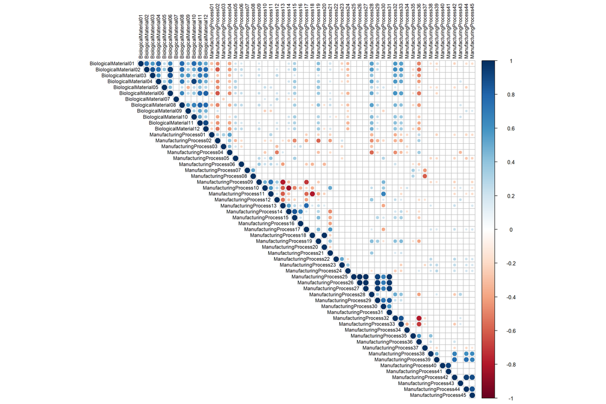

```r
##################################
# Loading dataset
##################################
DPA <- ChemicalManufacturingProcess

##################################
# Listing all predictors
##################################
DPA.Predictors <- DPA[,!names(DPA) %in% c("Yield")]

##################################
# Listing all numeric predictors
##################################
DPA.Predictors.Numeric <- DPA.Predictors[,sapply(DPA.Predictors, is.numeric)]

##################################
# Visualizing pairwise correlation between predictors
##################################
DPA_CorrelationTest <- cor.mtest(DPA.Predictors.Numeric,
                       method = "pearson",
                       conf.level = .95)

corrplot(cor(DPA.Predictors.Numeric,
             method = "pearson",
             use="pairwise.complete.obs"),
         method = "circle",
         type = "upper",
         order = "original",
         tl.col = "black",
         tl.cex = 0.75,
         tl.srt = 90,
         sig.level = 0.05,
         p.mat = DPA_CorrelationTest$p,
         insig = "blank")
```

```r
##################################
# Identifying the highly correlated variables
##################################
DPA_Correlation <-  cor(DPA.Predictors.Numeric,
                        method = "pearson",
                        use="pairwise.complete.obs")
(DPA_HighlyCorrelatedCount <- sum(abs(DPA_Correlation[upper.tri(DPA_Correlation)]) > 0.95))
```

```
## [1] 10
```

```
## [1] "High correlation observed for 10 pairs of numeric variable(s) with Correlation.Coefficient>0.95."
```

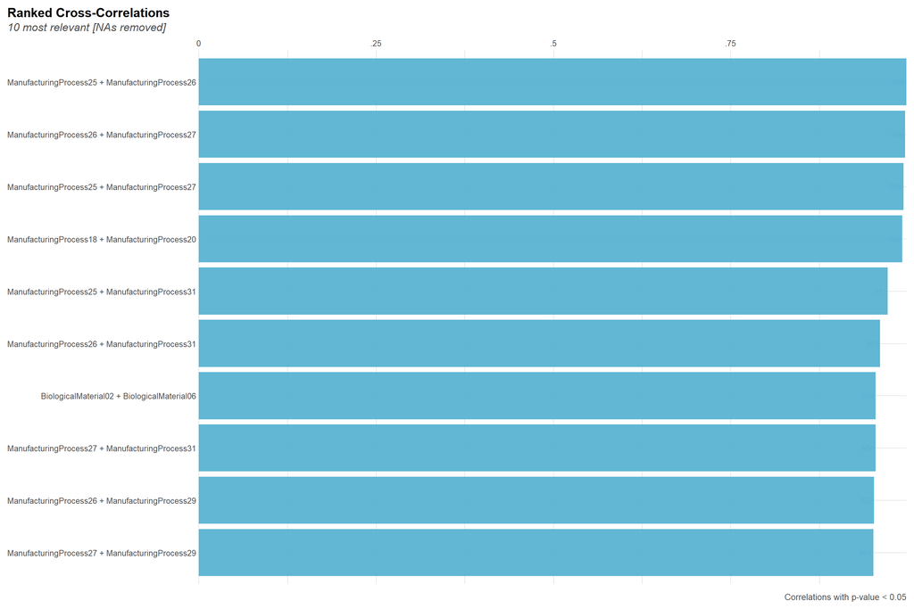

```r
if (DPA_HighlyCorrelatedCount == 0) {
  print("No highly correlated predictors noted.")
} else {
  print(paste0("High correlation observed for ",
               (DPA_HighlyCorrelatedCount),
               " pairs of numeric variable(s) with Correlation.Coefficient>0.95."))

  (DPA_HighlyCorrelatedPairs <- corr_cross(DPA.Predictors.Numeric,
  max_pvalue = 0.05,
  top = DPA_HighlyCorrelatedCount,
  rm.na = TRUE,
  grid = FALSE
))

}
```

```r
if (DPA_HighlyCorrelatedCount > 0) {
  DPA_HighlyCorrelated <- findCorrelation(DPA_Correlation, cutoff = 0.95)

  (DPA_HighlyCorrelatedForRemoval <- length(DPA_HighlyCorrelated))

  print(paste0("High correlation can be resolved by removing ",
               (DPA_HighlyCorrelatedForRemoval),
               " numeric variable(s)."))

  for (j in 1:DPA_HighlyCorrelatedForRemoval) {
  DPA_HighlyCorrelatedRemovedVariable <- colnames(DPA.Predictors.Numeric)[DPA_HighlyCorrelated[j]]
  print(paste0("Variable ",
               j,
               " for removal: ",
               DPA_HighlyCorrelatedRemovedVariable))
  }

  ##################################
  # Filtering out columns with high correlation
  #################################
  DPA_ExcludedHighCorrelation <- DPA[,-DPA_HighlyCorrelated]

  ##################################
  # Gathering descriptive statistics
  ##################################
  (DPA_ExcludedHighCorrelation_Skimmed <- skim(DPA_ExcludedHighCorrelation))
}
```

```
## [1] "High correlation can be resolved by removing 6 numeric variable(s)."
## [1] "Variable 1 for removal: BiologicalMaterial02"
## [1] "Variable 2 for removal: ManufacturingProcess29"
## [1] "Variable 3 for removal: ManufacturingProcess27"
## [1] "Variable 4 for removal: ManufacturingProcess25"
## [1] "Variable 5 for removal: ManufacturingProcess31"
## [1] "Variable 6 for removal: ManufacturingProcess20"
```

Data summary

| Name | DPA_ExcludedHighCorrelati… |
| --- | --- |
| Number of rows | 176 |
| Number of columns | 52 |
| _______________________ |  |
| Column type frequency: |  |
| numeric | 52 |
| ________________________ |  |
| Group variables | None |

**Variable type: numeric**

| skim_variable | n_missing | complete_rate | mean | sd | p0 | p25 | p50 | p75 | p100 | hist |
| --- | --- | --- | --- | --- | --- | --- | --- | --- | --- | --- |
| Yield | 0 | 1.00 | 40.18 | 1.85 | 35.25 | 38.75 | 39.97 | 41.48 | 46.34 | ▁▇▇▃▁ |
| BiologicalMaterial02 | 0 | 1.00 | 55.69 | 4.03 | 46.87 | 52.68 | 55.09 | 58.74 | 64.75 | ▂▇▆▅▃ |
| BiologicalMaterial03 | 0 | 1.00 | 67.70 | 4.00 | 56.97 | 64.98 | 67.22 | 70.43 | 78.25 | ▂▅▇▆▁ |
| BiologicalMaterial04 | 0 | 1.00 | 12.35 | 1.77 | 9.38 | 11.25 | 12.10 | 13.22 | 23.09 | ▇▆▁▁▁ |
| BiologicalMaterial05 | 0 | 1.00 | 18.60 | 1.84 | 13.24 | 17.24 | 18.49 | 19.90 | 24.85 | ▁▅▇▃▁ |
| BiologicalMaterial06 | 0 | 1.00 | 48.91 | 3.75 | 40.60 | 46.06 | 48.46 | 51.34 | 59.38 | ▂▇▆▅▁ |
| BiologicalMaterial07 | 0 | 1.00 | 100.01 | 0.11 | 100.00 | 100.00 | 100.00 | 100.00 | 100.83 | ▇▁▁▁▁ |
| BiologicalMaterial08 | 0 | 1.00 | 17.49 | 0.68 | 15.88 | 17.06 | 17.51 | 17.88 | 19.14 | ▁▅▇▃▂ |
| BiologicalMaterial09 | 0 | 1.00 | 12.85 | 0.42 | 11.44 | 12.60 | 12.84 | 13.13 | 14.08 | ▁▃▇▅▁ |
| BiologicalMaterial10 | 0 | 1.00 | 2.80 | 0.60 | 1.77 | 2.46 | 2.71 | 2.99 | 6.87 | ▇▅▁▁▁ |
| BiologicalMaterial11 | 0 | 1.00 | 146.95 | 4.82 | 135.81 | 143.82 | 146.08 | 149.60 | 158.73 | ▂▆▇▃▂ |
| BiologicalMaterial12 | 0 | 1.00 | 20.20 | 0.77 | 18.35 | 19.73 | 20.12 | 20.75 | 22.21 | ▂▆▇▃▂ |
| ManufacturingProcess01 | 1 | 0.99 | 11.21 | 1.82 | 0.00 | 10.80 | 11.40 | 12.15 | 14.10 | ▁▁▁▅▇ |
| ManufacturingProcess02 | 3 | 0.98 | 16.68 | 8.47 | 0.00 | 19.30 | 21.00 | 21.50 | 22.50 | ▂▁▁▁▇ |
| ManufacturingProcess03 | 15 | 0.91 | 1.54 | 0.02 | 1.47 | 1.53 | 1.54 | 1.55 | 1.60 | ▁▃▆▇▁ |
| ManufacturingProcess04 | 1 | 0.99 | 931.85 | 6.27 | 911.00 | 928.00 | 934.00 | 936.00 | 946.00 | ▁▂▃▇▁ |
| ManufacturingProcess05 | 1 | 0.99 | 1001.69 | 30.53 | 923.00 | 986.75 | 999.20 | 1008.85 | 1175.30 | ▁▇▁▁▁ |
| ManufacturingProcess06 | 2 | 0.99 | 207.40 | 2.70 | 203.00 | 205.70 | 206.80 | 208.70 | 227.40 | ▇▃▁▁▁ |
| ManufacturingProcess07 | 1 | 0.99 | 177.48 | 0.50 | 177.00 | 177.00 | 177.00 | 178.00 | 178.00 | ▇▁▁▁▇ |
| ManufacturingProcess08 | 1 | 0.99 | 177.55 | 0.50 | 177.00 | 177.00 | 178.00 | 178.00 | 178.00 | ▆▁▁▁▇ |
| ManufacturingProcess09 | 0 | 1.00 | 45.66 | 1.55 | 38.89 | 44.89 | 45.73 | 46.52 | 49.36 | ▁▁▅▇▂ |
| ManufacturingProcess10 | 9 | 0.95 | 9.18 | 0.77 | 7.50 | 8.70 | 9.10 | 9.55 | 11.60 | ▂▇▆▂▁ |
| ManufacturingProcess11 | 10 | 0.94 | 9.39 | 0.72 | 7.50 | 9.00 | 9.40 | 9.90 | 11.50 | ▂▆▇▅▁ |
| ManufacturingProcess12 | 1 | 0.99 | 857.81 | 1784.53 | 0.00 | 0.00 | 0.00 | 0.00 | 4549.00 | ▇▁▁▁▂ |
| ManufacturingProcess13 | 0 | 1.00 | 34.51 | 1.02 | 32.10 | 33.90 | 34.60 | 35.20 | 38.60 | ▃▇▇▁▁ |
| ManufacturingProcess14 | 1 | 0.99 | 4853.87 | 54.52 | 4701.00 | 4828.00 | 4856.00 | 4882.50 | 5055.00 | ▁▅▇▂▁ |
| ManufacturingProcess15 | 0 | 1.00 | 6038.92 | 58.31 | 5904.00 | 6010.00 | 6031.50 | 6061.00 | 6233.00 | ▂▇▆▂▁ |
| ManufacturingProcess16 | 0 | 1.00 | 4565.80 | 351.70 | 0.00 | 4560.75 | 4588.00 | 4619.00 | 4852.00 | ▁▁▁▁▇ |
| ManufacturingProcess17 | 0 | 1.00 | 34.34 | 1.25 | 31.30 | 33.50 | 34.40 | 35.10 | 40.00 | ▂▇▆▁▁ |
| ManufacturingProcess18 | 0 | 1.00 | 4809.68 | 367.48 | 0.00 | 4813.00 | 4835.00 | 4862.00 | 4971.00 | ▁▁▁▁▇ |
| ManufacturingProcess20 | 0 | 1.00 | 4556.46 | 349.01 | 0.00 | 4552.75 | 4582.00 | 4609.50 | 4759.00 | ▁▁▁▁▇ |
| ManufacturingProcess21 | 0 | 1.00 | -0.16 | 0.78 | -1.80 | -0.60 | -0.30 | 0.00 | 3.60 | ▂▇▂▁▁ |
| ManufacturingProcess22 | 1 | 0.99 | 5.41 | 3.33 | 0.00 | 3.00 | 5.00 | 8.00 | 12.00 | ▇▇▇▅▅ |
| ManufacturingProcess23 | 1 | 0.99 | 3.02 | 1.66 | 0.00 | 2.00 | 3.00 | 4.00 | 6.00 | ▇▆▇▆▇ |
| ManufacturingProcess25 | 5 | 0.97 | 4828.18 | 373.48 | 0.00 | 4832.00 | 4855.00 | 4877.00 | 4990.00 | ▁▁▁▁▇ |
| ManufacturingProcess27 | 5 | 0.97 | 4562.51 | 353.98 | 0.00 | 4560.00 | 4587.00 | 4609.00 | 4710.00 | ▁▁▁▁▇ |
| ManufacturingProcess29 | 5 | 0.97 | 20.01 | 1.66 | 0.00 | 19.70 | 19.90 | 20.40 | 22.00 | ▁▁▁▁▇ |
| ManufacturingProcess31 | 5 | 0.97 | 70.18 | 5.56 | 0.00 | 70.10 | 70.80 | 71.40 | 72.50 | ▁▁▁▁▇ |
| ManufacturingProcess32 | 0 | 1.00 | 158.47 | 5.40 | 143.00 | 155.00 | 158.00 | 162.00 | 173.00 | ▁▃▇▃▁ |
| ManufacturingProcess33 | 5 | 0.97 | 63.54 | 2.48 | 56.00 | 62.00 | 64.00 | 65.00 | 70.00 | ▁▃▇▅▁ |
| ManufacturingProcess34 | 5 | 0.97 | 2.49 | 0.05 | 2.30 | 2.50 | 2.50 | 2.50 | 2.60 | ▁▂▁▇▁ |
| ManufacturingProcess35 | 5 | 0.97 | 495.60 | 10.82 | 463.00 | 490.00 | 495.00 | 501.50 | 522.00 | ▁▂▇▅▂ |
| ManufacturingProcess36 | 5 | 0.97 | 0.02 | 0.00 | 0.02 | 0.02 | 0.02 | 0.02 | 0.02 | ▂▇▇▁▃ |
| ManufacturingProcess37 | 0 | 1.00 | 1.01 | 0.45 | 0.00 | 0.70 | 1.00 | 1.30 | 2.30 | ▂▇▇▃▁ |
| ManufacturingProcess38 | 0 | 1.00 | 2.53 | 0.65 | 0.00 | 2.00 | 3.00 | 3.00 | 3.00 | ▁▁▁▅▇ |
| ManufacturingProcess39 | 0 | 1.00 | 6.85 | 1.51 | 0.00 | 7.10 | 7.20 | 7.30 | 7.50 | ▁▁▁▁▇ |
| ManufacturingProcess40 | 1 | 0.99 | 0.02 | 0.04 | 0.00 | 0.00 | 0.00 | 0.00 | 0.10 | ▇▁▁▁▂ |
| ManufacturingProcess41 | 1 | 0.99 | 0.02 | 0.05 | 0.00 | 0.00 | 0.00 | 0.00 | 0.20 | ▇▁▁▁▁ |
| ManufacturingProcess42 | 0 | 1.00 | 11.21 | 1.94 | 0.00 | 11.40 | 11.60 | 11.70 | 12.10 | ▁▁▁▁▇ |
| ManufacturingProcess43 | 0 | 1.00 | 0.91 | 0.87 | 0.00 | 0.60 | 0.80 | 1.02 | 11.00 | ▇▁▁▁▁ |
| ManufacturingProcess44 | 0 | 1.00 | 1.81 | 0.32 | 0.00 | 1.80 | 1.90 | 1.90 | 2.10 | ▁▁▁▁▇ |
| ManufacturingProcess45 | 0 | 1.00 | 2.14 | 0.41 | 0.00 | 2.10 | 2.20 | 2.30 | 2.60 | ▁▁▁▂▇ |

### 1.3.5 Linear Dependencies

Linear dependency data assessment:  
**[A]** Linear dependency noted for 1 subset of 3 variables using the preprocessing summary from the **caret** package.  
**[B]** The **caret** package includes a method for detecting linearly dependent variables:  
**[B.1]** The findLinearCombos method from the **caret** package uses the QR decomposition of a matrix to enumerate sets of linear combinations (if they exist).  
**[C]** The findLinearCombos method was applied on the dataset:  
**[C.1]** 1 subset involving 3 variables was identified to have linear dependency.  
**[C.2]** 1/3 linearly dependent variables from the subset may be optionally removed from the dataset for the subsequent analysis.

**Code Chunk | Output**

```r
##################################
# Reusing imputed dataset
# to facilitate linear dependency assessment
# on complete data with no missing values
##################################
DPA <- DPA_BagImputed

##################################
# Listing all predictors
##################################
DPA.Predictors <- DPA[,!names(DPA) %in% c("Yield")]

##################################
# Listing all numeric predictors
##################################
DPA.Predictors.Numeric <- DPA.Predictors[,sapply(DPA.Predictors, is.numeric)]

##################################
# Finding linear dependencies
##################################
DPA_LinearlyDependent <- findLinearCombos(DPA.Predictors.Numeric)

##################################
# Identifying the linearly dependent variables
##################################
DPA_LinearlyDependent <- findLinearCombos(DPA.Predictors.Numeric)

(DPA_LinearlyDependentCount <- length(DPA_LinearlyDependent$linearCombos))
```

```
## [1] 1
```

```r
if (DPA_LinearlyDependentCount == 0) {
  print("No linearly dependent predictors noted.")
} else {
  print(paste0("Linear dependency observed for ",
               (DPA_LinearlyDependentCount),
               " subset(s) of numeric variable(s)."))

  for (i in 1:DPA_LinearlyDependentCount) {
    DPA_LinearlyDependentSubset <- colnames(DPA.Predictors.Numeric)[DPA_LinearlyDependent$linearCombos[[i]]]
    print(paste0("Linear dependent variable(s) for subset ",
                 i,
                 " include: ",
                 DPA_LinearlyDependentSubset))
  }

}
```

```
## [1] "Linear dependency observed for 1 subset(s) of numeric variable(s)."
## [1] "Linear dependent variable(s) for subset 1 include: ManufacturingProcess21"
## [2] "Linear dependent variable(s) for subset 1 include: ManufacturingProcess13"
## [3] "Linear dependent variable(s) for subset 1 include: ManufacturingProcess17"
```

```r
##################################
# Identifying the linearly dependent variables for removal
##################################

if (DPA_LinearlyDependentCount > 0) {
  DPA_LinearlyDependent <- findLinearCombos(DPA.Predictors.Numeric)

  DPA_LinearlyDependentForRemoval <- length(DPA_LinearlyDependent$remove)

  print(paste0("Linear dependency can be resolved by removing ",
               (DPA_LinearlyDependentForRemoval),
               " numeric variable(s)."))

  for (j in 1:DPA_LinearlyDependentForRemoval) {
  DPA_LinearlyDependentRemovedVariable <- colnames(DPA.Predictors.Numeric)[DPA_LinearlyDependent$remove[j]]
  print(paste0("Variable ",
               j,
               " for removal: ",
               DPA_LinearlyDependentRemovedVariable))
  }

  ##################################
  # Filtering out columns with linear dependency
  #################################
  DPA_ExcludedLinearlyDependent <- DPA.Predictors.Numeric[,-DPA_LinearlyDependent$remove]

  ##################################
  # Gathering descriptive statistics
  ##################################
  (DPA_ExcludedLinearlyDependent_Skimmed <- skim(DPA_ExcludedLinearlyDependent))

}
```

```
## [1] "Linear dependency can be resolved by removing 1 numeric variable(s)."
## [1] "Variable 1 for removal: ManufacturingProcess21"
```

Data summary

| Name | DPA_ExcludedLinearlyDepen… |
| --- | --- |
| Number of rows | 176 |
| Number of columns | 56 |
| _______________________ |  |
| Column type frequency: |  |
| numeric | 56 |
| ________________________ |  |
| Group variables | None |

**Variable type: numeric**

| skim_variable | n_missing | complete_rate | mean | sd | p0 | p25 | p50 | p75 | p100 | hist |
| --- | --- | --- | --- | --- | --- | --- | --- | --- | --- | --- |
| BiologicalMaterial01 | 0 | 1 | 6.41 | 0.71 | 4.58 | 5.98 | 6.30 | 6.87 | 8.81 | ▂▇▇▂▁ |
| BiologicalMaterial02 | 0 | 1 | 55.69 | 4.03 | 46.87 | 52.68 | 55.09 | 58.74 | 64.75 | ▂▇▆▅▃ |
| BiologicalMaterial03 | 0 | 1 | 67.70 | 4.00 | 56.97 | 64.98 | 67.22 | 70.43 | 78.25 | ▂▅▇▆▁ |
| BiologicalMaterial04 | 0 | 1 | 12.35 | 1.77 | 9.38 | 11.25 | 12.10 | 13.22 | 23.09 | ▇▆▁▁▁ |
| BiologicalMaterial05 | 0 | 1 | 18.60 | 1.84 | 13.24 | 17.24 | 18.49 | 19.90 | 24.85 | ▁▅▇▃▁ |
| BiologicalMaterial06 | 0 | 1 | 48.91 | 3.75 | 40.60 | 46.06 | 48.46 | 51.34 | 59.38 | ▂▇▆▅▁ |
| BiologicalMaterial07 | 0 | 1 | 100.01 | 0.11 | 100.00 | 100.00 | 100.00 | 100.00 | 100.83 | ▇▁▁▁▁ |
| BiologicalMaterial08 | 0 | 1 | 17.49 | 0.68 | 15.88 | 17.06 | 17.51 | 17.88 | 19.14 | ▁▅▇▃▂ |
| BiologicalMaterial09 | 0 | 1 | 12.85 | 0.42 | 11.44 | 12.60 | 12.84 | 13.13 | 14.08 | ▁▃▇▅▁ |
| BiologicalMaterial10 | 0 | 1 | 2.80 | 0.60 | 1.77 | 2.46 | 2.71 | 2.99 | 6.87 | ▇▅▁▁▁ |
| BiologicalMaterial11 | 0 | 1 | 146.95 | 4.82 | 135.81 | 143.82 | 146.08 | 149.60 | 158.73 | ▂▆▇▃▂ |
| BiologicalMaterial12 | 0 | 1 | 20.20 | 0.77 | 18.35 | 19.73 | 20.12 | 20.75 | 22.21 | ▂▆▇▃▂ |
| ManufacturingProcess01 | 0 | 1 | 11.20 | 1.82 | 0.00 | 10.78 | 11.40 | 12.12 | 14.10 | ▁▁▁▅▇ |
| ManufacturingProcess02 | 0 | 1 | 16.72 | 8.41 | 0.00 | 19.23 | 21.00 | 21.50 | 22.50 | ▂▁▁▁▇ |
| ManufacturingProcess03 | 0 | 1 | 1.54 | 0.02 | 1.47 | 1.53 | 1.54 | 1.55 | 1.60 | ▁▂▆▇▁ |
| ManufacturingProcess04 | 0 | 1 | 931.82 | 6.27 | 911.00 | 927.75 | 934.00 | 936.00 | 946.00 | ▁▂▃▇▁ |
| ManufacturingProcess05 | 0 | 1 | 1001.66 | 30.44 | 923.00 | 986.82 | 999.05 | 1008.72 | 1175.30 | ▁▇▁▁▁ |
| ManufacturingProcess06 | 0 | 1 | 207.38 | 2.69 | 203.00 | 205.70 | 206.80 | 208.70 | 227.40 | ▇▃▁▁▁ |
| ManufacturingProcess07 | 0 | 1 | 177.48 | 0.50 | 177.00 | 177.00 | 177.00 | 178.00 | 178.00 | ▇▁▁▁▇ |
| ManufacturingProcess08 | 0 | 1 | 177.56 | 0.50 | 177.00 | 177.00 | 178.00 | 178.00 | 178.00 | ▆▁▁▁▇ |
| ManufacturingProcess09 | 0 | 1 | 45.66 | 1.55 | 38.89 | 44.89 | 45.73 | 46.52 | 49.36 | ▁▁▅▇▂ |
| ManufacturingProcess10 | 0 | 1 | 9.17 | 0.76 | 7.50 | 8.70 | 9.10 | 9.53 | 11.60 | ▂▇▆▂▁ |
| ManufacturingProcess11 | 0 | 1 | 9.39 | 0.70 | 7.50 | 9.00 | 9.40 | 9.90 | 11.50 | ▂▆▇▅▁ |
| ManufacturingProcess12 | 0 | 1 | 856.88 | 1779.47 | 0.00 | 0.00 | 0.00 | 0.00 | 4549.00 | ▇▁▁▁▂ |
| ManufacturingProcess13 | 0 | 1 | 34.51 | 1.02 | 32.10 | 33.90 | 34.60 | 35.20 | 38.60 | ▃▇▇▁▁ |
| ManufacturingProcess14 | 0 | 1 | 4853.66 | 54.44 | 4701.00 | 4827.25 | 4855.50 | 4882.25 | 5055.00 | ▁▅▇▂▁ |
| ManufacturingProcess15 | 0 | 1 | 6038.92 | 58.31 | 5904.00 | 6010.00 | 6031.50 | 6061.00 | 6233.00 | ▂▇▆▂▁ |
| ManufacturingProcess16 | 0 | 1 | 4565.80 | 351.70 | 0.00 | 4560.75 | 4588.00 | 4619.00 | 4852.00 | ▁▁▁▁▇ |
| ManufacturingProcess17 | 0 | 1 | 34.34 | 1.25 | 31.30 | 33.50 | 34.40 | 35.10 | 40.00 | ▂▇▆▁▁ |
| ManufacturingProcess18 | 0 | 1 | 4809.68 | 367.48 | 0.00 | 4813.00 | 4835.00 | 4862.00 | 4971.00 | ▁▁▁▁▇ |
| ManufacturingProcess19 | 0 | 1 | 6028.20 | 45.58 | 5890.00 | 6000.75 | 6022.00 | 6050.25 | 6146.00 | ▁▃▇▃▂ |
| ManufacturingProcess20 | 0 | 1 | 4556.46 | 349.01 | 0.00 | 4552.75 | 4582.00 | 4609.50 | 4759.00 | ▁▁▁▁▇ |
| ManufacturingProcess22 | 0 | 1 | 5.40 | 3.32 | 0.00 | 3.00 | 5.00 | 8.00 | 12.00 | ▇▇▇▅▅ |
| ManufacturingProcess23 | 0 | 1 | 3.02 | 1.66 | 0.00 | 2.00 | 3.00 | 4.00 | 6.00 | ▇▆▇▆▇ |
| ManufacturingProcess24 | 0 | 1 | 8.86 | 5.80 | 0.00 | 4.00 | 8.00 | 14.00 | 23.00 | ▇▇▅▆▁ |
| ManufacturingProcess25 | 0 | 1 | 4828.44 | 368.11 | 0.00 | 4832.00 | 4854.00 | 4876.25 | 4990.00 | ▁▁▁▁▇ |
| ManufacturingProcess26 | 0 | 1 | 6012.09 | 459.12 | 0.00 | 6019.00 | 6045.00 | 6069.25 | 6161.00 | ▁▁▁▁▇ |
| ManufacturingProcess27 | 0 | 1 | 4556.43 | 352.33 | 0.00 | 4557.00 | 4586.50 | 4609.00 | 4710.00 | ▁▁▁▁▇ |
| ManufacturingProcess28 | 0 | 1 | 6.57 | 5.18 | 0.00 | 0.00 | 10.40 | 10.70 | 11.50 | ▅▁▁▁▇ |
| ManufacturingProcess29 | 0 | 1 | 19.98 | 1.66 | 0.00 | 19.70 | 19.90 | 20.40 | 22.00 | ▁▁▁▁▇ |
| ManufacturingProcess30 | 0 | 1 | 9.17 | 0.96 | 0.00 | 8.80 | 9.20 | 9.70 | 11.20 | ▁▁▁▅▇ |
| ManufacturingProcess31 | 0 | 1 | 70.14 | 5.49 | 0.00 | 70.10 | 70.75 | 71.40 | 72.50 | ▁▁▁▁▇ |
| ManufacturingProcess32 | 0 | 1 | 158.47 | 5.40 | 143.00 | 155.00 | 158.00 | 162.00 | 173.00 | ▁▃▇▃▁ |
| ManufacturingProcess33 | 0 | 1 | 63.55 | 2.46 | 56.00 | 62.00 | 64.00 | 65.00 | 70.00 | ▁▃▇▅▁ |
| ManufacturingProcess34 | 0 | 1 | 2.49 | 0.05 | 2.30 | 2.50 | 2.50 | 2.50 | 2.60 | ▁▂▁▇▁ |
| ManufacturingProcess35 | 0 | 1 | 495.53 | 10.68 | 463.00 | 490.00 | 495.00 | 501.00 | 522.00 | ▁▂▇▅▂ |
| ManufacturingProcess36 | 0 | 1 | 0.02 | 0.00 | 0.02 | 0.02 | 0.02 | 0.02 | 0.02 | ▂▇▇▁▃ |
| ManufacturingProcess37 | 0 | 1 | 1.01 | 0.45 | 0.00 | 0.70 | 1.00 | 1.30 | 2.30 | ▂▇▇▃▁ |
| ManufacturingProcess38 | 0 | 1 | 2.53 | 0.65 | 0.00 | 2.00 | 3.00 | 3.00 | 3.00 | ▁▁▁▅▇ |
| ManufacturingProcess39 | 0 | 1 | 6.85 | 1.51 | 0.00 | 7.10 | 7.20 | 7.30 | 7.50 | ▁▁▁▁▇ |
| ManufacturingProcess40 | 0 | 1 | 0.02 | 0.04 | 0.00 | 0.00 | 0.00 | 0.00 | 0.10 | ▇▁▁▁▂ |
| ManufacturingProcess41 | 0 | 1 | 0.02 | 0.05 | 0.00 | 0.00 | 0.00 | 0.00 | 0.20 | ▇▁▁▁▁ |
| ManufacturingProcess42 | 0 | 1 | 11.21 | 1.94 | 0.00 | 11.40 | 11.60 | 11.70 | 12.10 | ▁▁▁▁▇ |
| ManufacturingProcess43 | 0 | 1 | 0.91 | 0.87 | 0.00 | 0.60 | 0.80 | 1.02 | 11.00 | ▇▁▁▁▁ |
| ManufacturingProcess44 | 0 | 1 | 1.81 | 0.32 | 0.00 | 1.80 | 1.90 | 1.90 | 2.10 | ▁▁▁▁▇ |
| ManufacturingProcess45 | 0 | 1 | 2.14 | 0.41 | 0.00 | 2.10 | 2.20 | 2.30 | 2.60 | ▁▁▁▂▇ |

### 1.3.6 Centering and Scaling

Centering and scaling data assessment:  
**[A]** Centering and scaling transformation for numerical stability remains optional depending on potential model requirements for the subsequent steps.  
**[B]** The **caret** package includes three methods for centering and scaling variables:  
**[B.1]** The center method from the **caret** package subtracts the average value of a numeric variable to all the values. As a result of centering, the variable has a zero mean.  
**[B.2]** The scale method from the **caret** package performs a center transformation with each value of the variable divided by its standard deviation. Scaling the data coerces the values to have a common standard deviation of one.  
**[B.3]** The range method from the **caret** package scales the data to be within the defined numeric range bound.  
**[C]** The center, scale and range methods were evaluated on the dataset.

**Code Chunk | Output**

```r
##################################
# Loading dataset
##################################
DPA <- ChemicalManufacturingProcess

##################################
# Listing all predictors
##################################
DPA.Predictors <- DPA[,!names(DPA) %in% c("Yield")]

##################################
# Listing all numeric predictors
##################################
DPA.Predictors.Numeric <- DPA.Predictors[,sapply(DPA.Predictors, is.numeric)]

##################################
# Gathering descriptive statistics
##################################
(DPA_Skimmed <- skim(DPA.Predictors.Numeric))
```

Data summary

| Name | DPA.Predictors.Numeric |
| --- | --- |
| Number of rows | 176 |
| Number of columns | 57 |
| _______________________ |  |
| Column type frequency: |  |
| numeric | 57 |
| ________________________ |  |
| Group variables | None |

**Variable type: numeric**

| skim_variable | n_missing | complete_rate | mean | sd | p0 | p25 | p50 | p75 | p100 | hist |
| --- | --- | --- | --- | --- | --- | --- | --- | --- | --- | --- |
| BiologicalMaterial01 | 0 | 1.00 | 6.41 | 0.71 | 4.58 | 5.98 | 6.30 | 6.87 | 8.81 | ▂▇▇▂▁ |
| BiologicalMaterial02 | 0 | 1.00 | 55.69 | 4.03 | 46.87 | 52.68 | 55.09 | 58.74 | 64.75 | ▂▇▆▅▃ |
| BiologicalMaterial03 | 0 | 1.00 | 67.70 | 4.00 | 56.97 | 64.98 | 67.22 | 70.43 | 78.25 | ▂▅▇▆▁ |
| BiologicalMaterial04 | 0 | 1.00 | 12.35 | 1.77 | 9.38 | 11.25 | 12.10 | 13.22 | 23.09 | ▇▆▁▁▁ |
| BiologicalMaterial05 | 0 | 1.00 | 18.60 | 1.84 | 13.24 | 17.24 | 18.49 | 19.90 | 24.85 | ▁▅▇▃▁ |
| BiologicalMaterial06 | 0 | 1.00 | 48.91 | 3.75 | 40.60 | 46.06 | 48.46 | 51.34 | 59.38 | ▂▇▆▅▁ |
| BiologicalMaterial07 | 0 | 1.00 | 100.01 | 0.11 | 100.00 | 100.00 | 100.00 | 100.00 | 100.83 | ▇▁▁▁▁ |
| BiologicalMaterial08 | 0 | 1.00 | 17.49 | 0.68 | 15.88 | 17.06 | 17.51 | 17.88 | 19.14 | ▁▅▇▃▂ |
| BiologicalMaterial09 | 0 | 1.00 | 12.85 | 0.42 | 11.44 | 12.60 | 12.84 | 13.13 | 14.08 | ▁▃▇▅▁ |
| BiologicalMaterial10 | 0 | 1.00 | 2.80 | 0.60 | 1.77 | 2.46 | 2.71 | 2.99 | 6.87 | ▇▅▁▁▁ |
| BiologicalMaterial11 | 0 | 1.00 | 146.95 | 4.82 | 135.81 | 143.82 | 146.08 | 149.60 | 158.73 | ▂▆▇▃▂ |
| BiologicalMaterial12 | 0 | 1.00 | 20.20 | 0.77 | 18.35 | 19.73 | 20.12 | 20.75 | 22.21 | ▂▆▇▃▂ |
| ManufacturingProcess01 | 1 | 0.99 | 11.21 | 1.82 | 0.00 | 10.80 | 11.40 | 12.15 | 14.10 | ▁▁▁▅▇ |
| ManufacturingProcess02 | 3 | 0.98 | 16.68 | 8.47 | 0.00 | 19.30 | 21.00 | 21.50 | 22.50 | ▂▁▁▁▇ |
| ManufacturingProcess03 | 15 | 0.91 | 1.54 | 0.02 | 1.47 | 1.53 | 1.54 | 1.55 | 1.60 | ▁▃▆▇▁ |
| ManufacturingProcess04 | 1 | 0.99 | 931.85 | 6.27 | 911.00 | 928.00 | 934.00 | 936.00 | 946.00 | ▁▂▃▇▁ |
| ManufacturingProcess05 | 1 | 0.99 | 1001.69 | 30.53 | 923.00 | 986.75 | 999.20 | 1008.85 | 1175.30 | ▁▇▁▁▁ |
| ManufacturingProcess06 | 2 | 0.99 | 207.40 | 2.70 | 203.00 | 205.70 | 206.80 | 208.70 | 227.40 | ▇▃▁▁▁ |
| ManufacturingProcess07 | 1 | 0.99 | 177.48 | 0.50 | 177.00 | 177.00 | 177.00 | 178.00 | 178.00 | ▇▁▁▁▇ |
| ManufacturingProcess08 | 1 | 0.99 | 177.55 | 0.50 | 177.00 | 177.00 | 178.00 | 178.00 | 178.00 | ▆▁▁▁▇ |
| ManufacturingProcess09 | 0 | 1.00 | 45.66 | 1.55 | 38.89 | 44.89 | 45.73 | 46.52 | 49.36 | ▁▁▅▇▂ |
| ManufacturingProcess10 | 9 | 0.95 | 9.18 | 0.77 | 7.50 | 8.70 | 9.10 | 9.55 | 11.60 | ▂▇▆▂▁ |
| ManufacturingProcess11 | 10 | 0.94 | 9.39 | 0.72 | 7.50 | 9.00 | 9.40 | 9.90 | 11.50 | ▂▆▇▅▁ |
| ManufacturingProcess12 | 1 | 0.99 | 857.81 | 1784.53 | 0.00 | 0.00 | 0.00 | 0.00 | 4549.00 | ▇▁▁▁▂ |
| ManufacturingProcess13 | 0 | 1.00 | 34.51 | 1.02 | 32.10 | 33.90 | 34.60 | 35.20 | 38.60 | ▃▇▇▁▁ |
| ManufacturingProcess14 | 1 | 0.99 | 4853.87 | 54.52 | 4701.00 | 4828.00 | 4856.00 | 4882.50 | 5055.00 | ▁▅▇▂▁ |
| ManufacturingProcess15 | 0 | 1.00 | 6038.92 | 58.31 | 5904.00 | 6010.00 | 6031.50 | 6061.00 | 6233.00 | ▂▇▆▂▁ |
| ManufacturingProcess16 | 0 | 1.00 | 4565.80 | 351.70 | 0.00 | 4560.75 | 4588.00 | 4619.00 | 4852.00 | ▁▁▁▁▇ |
| ManufacturingProcess17 | 0 | 1.00 | 34.34 | 1.25 | 31.30 | 33.50 | 34.40 | 35.10 | 40.00 | ▂▇▆▁▁ |
| ManufacturingProcess18 | 0 | 1.00 | 4809.68 | 367.48 | 0.00 | 4813.00 | 4835.00 | 4862.00 | 4971.00 | ▁▁▁▁▇ |
| ManufacturingProcess19 | 0 | 1.00 | 6028.20 | 45.58 | 5890.00 | 6000.75 | 6022.00 | 6050.25 | 6146.00 | ▁▃▇▃▂ |
| ManufacturingProcess20 | 0 | 1.00 | 4556.46 | 349.01 | 0.00 | 4552.75 | 4582.00 | 4609.50 | 4759.00 | ▁▁▁▁▇ |
| ManufacturingProcess21 | 0 | 1.00 | -0.16 | 0.78 | -1.80 | -0.60 | -0.30 | 0.00 | 3.60 | ▂▇▂▁▁ |
| ManufacturingProcess22 | 1 | 0.99 | 5.41 | 3.33 | 0.00 | 3.00 | 5.00 | 8.00 | 12.00 | ▇▇▇▅▅ |
| ManufacturingProcess23 | 1 | 0.99 | 3.02 | 1.66 | 0.00 | 2.00 | 3.00 | 4.00 | 6.00 | ▇▆▇▆▇ |
| ManufacturingProcess24 | 1 | 0.99 | 8.83 | 5.80 | 0.00 | 4.00 | 8.00 | 14.00 | 23.00 | ▇▇▅▆▁ |
| ManufacturingProcess25 | 5 | 0.97 | 4828.18 | 373.48 | 0.00 | 4832.00 | 4855.00 | 4877.00 | 4990.00 | ▁▁▁▁▇ |
| ManufacturingProcess26 | 5 | 0.97 | 6015.60 | 464.87 | 0.00 | 6019.50 | 6047.00 | 6070.50 | 6161.00 | ▁▁▁▁▇ |
| ManufacturingProcess27 | 5 | 0.97 | 4562.51 | 353.98 | 0.00 | 4560.00 | 4587.00 | 4609.00 | 4710.00 | ▁▁▁▁▇ |
| ManufacturingProcess28 | 5 | 0.97 | 6.59 | 5.25 | 0.00 | 0.00 | 10.40 | 10.75 | 11.50 | ▅▁▁▁▇ |
| ManufacturingProcess29 | 5 | 0.97 | 20.01 | 1.66 | 0.00 | 19.70 | 19.90 | 20.40 | 22.00 | ▁▁▁▁▇ |
| ManufacturingProcess30 | 5 | 0.97 | 9.16 | 0.98 | 0.00 | 8.80 | 9.10 | 9.70 | 11.20 | ▁▁▁▅▇ |
| ManufacturingProcess31 | 5 | 0.97 | 70.18 | 5.56 | 0.00 | 70.10 | 70.80 | 71.40 | 72.50 | ▁▁▁▁▇ |
| ManufacturingProcess32 | 0 | 1.00 | 158.47 | 5.40 | 143.00 | 155.00 | 158.00 | 162.00 | 173.00 | ▁▃▇▃▁ |
| ManufacturingProcess33 | 5 | 0.97 | 63.54 | 2.48 | 56.00 | 62.00 | 64.00 | 65.00 | 70.00 | ▁▃▇▅▁ |
| ManufacturingProcess34 | 5 | 0.97 | 2.49 | 0.05 | 2.30 | 2.50 | 2.50 | 2.50 | 2.60 | ▁▂▁▇▁ |
| ManufacturingProcess35 | 5 | 0.97 | 495.60 | 10.82 | 463.00 | 490.00 | 495.00 | 501.50 | 522.00 | ▁▂▇▅▂ |
| ManufacturingProcess36 | 5 | 0.97 | 0.02 | 0.00 | 0.02 | 0.02 | 0.02 | 0.02 | 0.02 | ▂▇▇▁▃ |
| ManufacturingProcess37 | 0 | 1.00 | 1.01 | 0.45 | 0.00 | 0.70 | 1.00 | 1.30 | 2.30 | ▂▇▇▃▁ |
| ManufacturingProcess38 | 0 | 1.00 | 2.53 | 0.65 | 0.00 | 2.00 | 3.00 | 3.00 | 3.00 | ▁▁▁▅▇ |
| ManufacturingProcess39 | 0 | 1.00 | 6.85 | 1.51 | 0.00 | 7.10 | 7.20 | 7.30 | 7.50 | ▁▁▁▁▇ |
| ManufacturingProcess40 | 1 | 0.99 | 0.02 | 0.04 | 0.00 | 0.00 | 0.00 | 0.00 | 0.10 | ▇▁▁▁▂ |
| ManufacturingProcess41 | 1 | 0.99 | 0.02 | 0.05 | 0.00 | 0.00 | 0.00 | 0.00 | 0.20 | ▇▁▁▁▁ |
| ManufacturingProcess42 | 0 | 1.00 | 11.21 | 1.94 | 0.00 | 11.40 | 11.60 | 11.70 | 12.10 | ▁▁▁▁▇ |
| ManufacturingProcess43 | 0 | 1.00 | 0.91 | 0.87 | 0.00 | 0.60 | 0.80 | 1.02 | 11.00 | ▇▁▁▁▁ |
| ManufacturingProcess44 | 0 | 1.00 | 1.81 | 0.32 | 0.00 | 1.80 | 1.90 | 1.90 | 2.10 | ▁▁▁▁▇ |
| ManufacturingProcess45 | 0 | 1.00 | 2.14 | 0.41 | 0.00 | 2.10 | 2.20 | 2.30 | 2.60 | ▁▁▁▂▇ |

```r
##################################
# Applying a center transformation
##################################
DPA_Centered <- preProcess(DPA.Predictors.Numeric, method = c("center"))
DPA_CenteredTransformed <- predict(DPA_Centered, DPA.Predictors.Numeric)

##################################
# Gathering descriptive statistics
##################################
(DPA_CenteredTransformedSkimmed <- skim(DPA_CenteredTransformed))
```

Data summary

| Name | DPA_CenteredTransformed |
| --- | --- |
| Number of rows | 176 |
| Number of columns | 57 |
| _______________________ |  |
| Column type frequency: |  |
| numeric | 57 |
| ________________________ |  |
| Group variables | None |

**Variable type: numeric**

| skim_variable | n_missing | complete_rate | mean | sd | p0 | p25 | p50 | p75 | p100 | hist |
| --- | --- | --- | --- | --- | --- | --- | --- | --- | --- | --- |
| BiologicalMaterial01 | 0 | 1.00 | 0 | 0.71 | -1.83 | -0.43 | -0.11 | 0.46 | 2.40 | ▂▇▇▂▁ |
| BiologicalMaterial02 | 0 | 1.00 | 0 | 4.03 | -8.82 | -3.01 | -0.60 | 3.05 | 9.06 | ▂▇▆▅▃ |
| BiologicalMaterial03 | 0 | 1.00 | 0 | 4.00 | -10.73 | -2.72 | -0.48 | 2.72 | 10.55 | ▂▅▇▆▁ |
| BiologicalMaterial04 | 0 | 1.00 | 0 | 1.77 | -2.97 | -1.10 | -0.25 | 0.87 | 10.74 | ▇▆▁▁▁ |
| BiologicalMaterial05 | 0 | 1.00 | 0 | 1.84 | -5.36 | -1.36 | -0.11 | 1.30 | 6.25 | ▁▅▇▃▁ |
| BiologicalMaterial06 | 0 | 1.00 | 0 | 3.75 | -8.31 | -2.86 | -0.45 | 2.43 | 10.47 | ▂▇▆▅▁ |
| BiologicalMaterial07 | 0 | 1.00 | 0 | 0.11 | -0.01 | -0.01 | -0.01 | -0.01 | 0.82 | ▇▁▁▁▁ |
| BiologicalMaterial08 | 0 | 1.00 | 0 | 0.68 | -1.61 | -0.43 | 0.02 | 0.39 | 1.65 | ▁▅▇▃▂ |
| BiologicalMaterial09 | 0 | 1.00 | 0 | 0.42 | -1.41 | -0.25 | -0.02 | 0.28 | 1.23 | ▁▃▇▅▁ |
| BiologicalMaterial10 | 0 | 1.00 | 0 | 0.60 | -1.03 | -0.34 | -0.09 | 0.19 | 4.07 | ▇▅▁▁▁ |
| BiologicalMaterial11 | 0 | 1.00 | 0 | 4.82 | -11.14 | -3.14 | -0.87 | 2.65 | 11.78 | ▂▆▇▃▂ |
| BiologicalMaterial12 | 0 | 1.00 | 0 | 0.77 | -1.85 | -0.47 | -0.08 | 0.55 | 2.01 | ▂▆▇▃▂ |
| ManufacturingProcess01 | 1 | 0.99 | 0 | 1.82 | -11.21 | -0.41 | 0.19 | 0.94 | 2.89 | ▁▁▁▅▇ |
| ManufacturingProcess02 | 3 | 0.98 | 0 | 8.47 | -16.68 | 2.62 | 4.32 | 4.82 | 5.82 | ▂▁▁▁▇ |
| ManufacturingProcess03 | 15 | 0.91 | 0 | 0.02 | -0.07 | -0.01 | 0.00 | 0.01 | 0.06 | ▁▃▆▇▁ |
| ManufacturingProcess04 | 1 | 0.99 | 0 | 6.27 | -20.85 | -3.85 | 2.15 | 4.15 | 14.15 | ▁▂▃▇▁ |
| ManufacturingProcess05 | 1 | 0.99 | 0 | 30.53 | -78.69 | -14.94 | -2.49 | 7.16 | 173.61 | ▁▇▁▁▁ |
| ManufacturingProcess06 | 2 | 0.99 | 0 | 2.70 | -4.40 | -1.70 | -0.60 | 1.30 | 20.00 | ▇▃▁▁▁ |
| ManufacturingProcess07 | 1 | 0.99 | 0 | 0.50 | -0.48 | -0.48 | -0.48 | 0.52 | 0.52 | ▇▁▁▁▇ |
| ManufacturingProcess08 | 1 | 0.99 | 0 | 0.50 | -0.55 | -0.55 | 0.45 | 0.45 | 0.45 | ▆▁▁▁▇ |
| ManufacturingProcess09 | 0 | 1.00 | 0 | 1.55 | -6.77 | -0.77 | 0.07 | 0.85 | 3.70 | ▁▁▅▇▂ |
| ManufacturingProcess10 | 9 | 0.95 | 0 | 0.77 | -1.68 | -0.48 | -0.08 | 0.37 | 2.42 | ▂▇▆▂▁ |
| ManufacturingProcess11 | 10 | 0.94 | 0 | 0.72 | -1.89 | -0.39 | 0.01 | 0.51 | 2.11 | ▁▆▇▅▁ |
| ManufacturingProcess12 | 1 | 0.99 | 0 | 1784.53 | -857.81 | -857.81 | -857.81 | -857.81 | 3691.19 | ▇▁▁▁▂ |
| ManufacturingProcess13 | 0 | 1.00 | 0 | 1.02 | -2.41 | -0.61 | 0.09 | 0.69 | 4.09 | ▃▆▇▁▁ |
| ManufacturingProcess14 | 1 | 0.99 | 0 | 54.52 | -152.87 | -25.87 | 2.13 | 28.63 | 201.13 | ▁▅▇▂▁ |
| ManufacturingProcess15 | 0 | 1.00 | 0 | 58.31 | -134.92 | -28.92 | -7.42 | 22.08 | 194.08 | ▂▇▆▂▁ |
| ManufacturingProcess16 | 0 | 1.00 | 0 | 351.70 | -4565.80 | -5.05 | 22.20 | 53.20 | 286.20 | ▁▁▁▁▇ |
| ManufacturingProcess17 | 0 | 1.00 | 0 | 1.25 | -3.04 | -0.84 | 0.06 | 0.76 | 5.66 | ▂▇▆▁▁ |
| ManufacturingProcess18 | 0 | 1.00 | 0 | 367.48 | -4809.68 | 3.32 | 25.32 | 52.32 | 161.32 | ▁▁▁▁▇ |
| ManufacturingProcess19 | 0 | 1.00 | 0 | 45.58 | -138.20 | -27.45 | -6.20 | 22.05 | 117.80 | ▁▃▇▃▂ |
| ManufacturingProcess20 | 0 | 1.00 | 0 | 349.01 | -4556.46 | -3.71 | 25.54 | 53.04 | 202.54 | ▁▁▁▁▇ |
| ManufacturingProcess21 | 0 | 1.00 | 0 | 0.78 | -1.64 | -0.44 | -0.14 | 0.16 | 3.76 | ▂▇▂▁▁ |
| ManufacturingProcess22 | 1 | 0.99 | 0 | 3.33 | -5.41 | -2.41 | -0.41 | 2.59 | 6.59 | ▇▇▇▅▅ |
| ManufacturingProcess23 | 1 | 0.99 | 0 | 1.66 | -3.02 | -1.02 | -0.02 | 0.98 | 2.98 | ▇▆▇▆▇ |
| ManufacturingProcess24 | 1 | 0.99 | 0 | 5.80 | -8.83 | -4.83 | -0.83 | 5.17 | 14.17 | ▇▇▅▆▁ |
| ManufacturingProcess25 | 5 | 0.97 | 0 | 373.48 | -4828.18 | 3.82 | 26.82 | 48.82 | 161.82 | ▁▁▁▁▇ |
| ManufacturingProcess26 | 5 | 0.97 | 0 | 464.87 | -6015.60 | 3.90 | 31.40 | 54.90 | 145.40 | ▁▁▁▁▇ |
| ManufacturingProcess27 | 5 | 0.97 | 0 | 353.98 | -4562.51 | -2.51 | 24.49 | 46.49 | 147.49 | ▁▁▁▁▇ |
| ManufacturingProcess28 | 5 | 0.97 | 0 | 5.25 | -6.59 | -6.59 | 3.81 | 4.16 | 4.91 | ▅▁▁▁▇ |
| ManufacturingProcess29 | 5 | 0.97 | 0 | 1.66 | -20.01 | -0.31 | -0.11 | 0.39 | 1.99 | ▁▁▁▁▇ |
| ManufacturingProcess30 | 5 | 0.97 | 0 | 0.98 | -9.16 | -0.36 | -0.06 | 0.54 | 2.04 | ▁▁▁▅▇ |
| ManufacturingProcess31 | 5 | 0.97 | 0 | 5.56 | -70.18 | -0.08 | 0.62 | 1.22 | 2.32 | ▁▁▁▁▇ |
| ManufacturingProcess32 | 0 | 1.00 | 0 | 5.40 | -15.47 | -3.47 | -0.47 | 3.53 | 14.53 | ▁▃▇▃▁ |
| ManufacturingProcess33 | 5 | 0.97 | 0 | 2.48 | -7.54 | -1.54 | 0.46 | 1.46 | 6.46 | ▁▃▇▅▁ |
| ManufacturingProcess34 | 5 | 0.97 | 0 | 0.05 | -0.19 | 0.01 | 0.01 | 0.01 | 0.11 | ▁▂▁▇▁ |
| ManufacturingProcess35 | 5 | 0.97 | 0 | 10.82 | -32.60 | -5.60 | -0.60 | 5.90 | 26.40 | ▁▂▇▅▂ |
| ManufacturingProcess36 | 5 | 0.97 | 0 | 0.00 | 0.00 | 0.00 | 0.00 | 0.00 | 0.00 | ▂▇▁▇▃ |
| ManufacturingProcess37 | 0 | 1.00 | 0 | 0.45 | -1.01 | -0.31 | -0.01 | 0.29 | 1.29 | ▂▇▇▃▁ |
| ManufacturingProcess38 | 0 | 1.00 | 0 | 0.65 | -2.53 | -0.53 | 0.47 | 0.47 | 0.47 | ▁▁▁▅▇ |
| ManufacturingProcess39 | 0 | 1.00 | 0 | 1.51 | -6.85 | 0.25 | 0.35 | 0.45 | 0.65 | ▁▁▁▁▇ |
| ManufacturingProcess40 | 1 | 0.99 | 0 | 0.04 | -0.02 | -0.02 | -0.02 | -0.02 | 0.08 | ▇▁▁▁▂ |
| ManufacturingProcess41 | 1 | 0.99 | 0 | 0.05 | -0.02 | -0.02 | -0.02 | -0.02 | 0.18 | ▇▁▁▁▁ |
| ManufacturingProcess42 | 0 | 1.00 | 0 | 1.94 | -11.21 | 0.19 | 0.39 | 0.49 | 0.89 | ▁▁▁▁▇ |
| ManufacturingProcess43 | 0 | 1.00 | 0 | 0.87 | -0.91 | -0.31 | -0.11 | 0.11 | 10.09 | ▇▁▁▁▁ |
| ManufacturingProcess44 | 0 | 1.00 | 0 | 0.32 | -1.81 | -0.01 | 0.09 | 0.09 | 0.29 | ▁▁▁▁▇ |
| ManufacturingProcess45 | 0 | 1.00 | 0 | 0.41 | -2.14 | -0.04 | 0.06 | 0.16 | 0.46 | ▁▁▁▂▇ |

```r
##################################
# Applying a center and scale data transformation
##################################
DPA_CenteredScaled <- preProcess(DPA.Predictors.Numeric, method = c("center","scale"))
DPA_CenteredScaledTransformed <- predict(DPA_CenteredScaled, DPA.Predictors.Numeric)

##################################
# Gathering descriptive statistics
##################################
(DPA_CenteredScaledTransformedSkimmed <- skim(DPA_CenteredScaledTransformed))
```

Data summary

| Name | DPA_CenteredScaledTransfo… |
| --- | --- |
| Number of rows | 176 |
| Number of columns | 57 |
| _______________________ |  |
| Column type frequency: |  |
| numeric | 57 |
| ________________________ |  |
| Group variables | None |

**Variable type: numeric**

| skim_variable | n_missing | complete_rate | mean | sd | p0 | p25 | p50 | p75 | p100 | hist |
| --- | --- | --- | --- | --- | --- | --- | --- | --- | --- | --- |
| BiologicalMaterial01 | 0 | 1.00 | 0 | 1 | -2.57 | -0.61 | -0.15 | 0.64 | 3.36 | ▂▇▇▂▁ |
| BiologicalMaterial02 | 0 | 1.00 | 0 | 1 | -2.19 | -0.75 | -0.15 | 0.76 | 2.25 | ▂▇▆▅▃ |
| BiologicalMaterial03 | 0 | 1.00 | 0 | 1 | -2.68 | -0.68 | -0.12 | 0.68 | 2.64 | ▂▅▇▆▁ |
| BiologicalMaterial04 | 0 | 1.00 | 0 | 1 | -1.67 | -0.62 | -0.14 | 0.49 | 6.05 | ▇▆▁▁▁ |
| BiologicalMaterial05 | 0 | 1.00 | 0 | 1 | -2.91 | -0.74 | -0.06 | 0.71 | 3.39 | ▁▅▇▃▁ |
| BiologicalMaterial06 | 0 | 1.00 | 0 | 1 | -2.22 | -0.76 | -0.12 | 0.65 | 2.79 | ▂▇▆▅▁ |
| BiologicalMaterial07 | 0 | 1.00 | 0 | 1 | -0.13 | -0.13 | -0.13 | -0.13 | 7.57 | ▇▁▁▁▁ |
| BiologicalMaterial08 | 0 | 1.00 | 0 | 1 | -2.39 | -0.64 | 0.02 | 0.57 | 2.43 | ▁▅▇▃▂ |
| BiologicalMaterial09 | 0 | 1.00 | 0 | 1 | -3.40 | -0.60 | -0.04 | 0.67 | 2.96 | ▁▃▇▅▁ |
| BiologicalMaterial10 | 0 | 1.00 | 0 | 1 | -1.72 | -0.57 | -0.15 | 0.32 | 6.79 | ▇▅▁▁▁ |
| BiologicalMaterial11 | 0 | 1.00 | 0 | 1 | -2.31 | -0.65 | -0.18 | 0.55 | 2.44 | ▂▆▇▃▂ |
| BiologicalMaterial12 | 0 | 1.00 | 0 | 1 | -2.39 | -0.61 | -0.10 | 0.71 | 2.60 | ▂▆▇▃▂ |
| ManufacturingProcess01 | 1 | 0.99 | 0 | 1 | -6.15 | -0.22 | 0.11 | 0.52 | 1.59 | ▁▁▁▅▇ |
| ManufacturingProcess02 | 3 | 0.98 | 0 | 1 | -1.97 | 0.31 | 0.51 | 0.57 | 0.69 | ▂▁▁▁▇ |
| ManufacturingProcess03 | 15 | 0.91 | 0 | 1 | -3.11 | -0.43 | 0.02 | 0.47 | 2.70 | ▁▃▆▇▁ |
| ManufacturingProcess04 | 1 | 0.99 | 0 | 1 | -3.32 | -0.61 | 0.34 | 0.66 | 2.25 | ▁▂▃▇▂ |
| ManufacturingProcess05 | 1 | 0.99 | 0 | 1 | -2.58 | -0.49 | -0.08 | 0.23 | 5.69 | ▁▇▁▁▁ |
| ManufacturingProcess06 | 2 | 0.99 | 0 | 1 | -1.63 | -0.63 | -0.22 | 0.48 | 7.41 | ▇▃▁▁▁ |
| ManufacturingProcess07 | 1 | 0.99 | 0 | 1 | -0.96 | -0.96 | -0.96 | 1.04 | 1.04 | ▇▁▁▁▇ |
| ManufacturingProcess08 | 1 | 0.99 | 0 | 1 | -1.11 | -1.11 | 0.89 | 0.89 | 0.89 | ▆▁▁▁▇ |
| ManufacturingProcess09 | 0 | 1.00 | 0 | 1 | -4.38 | -0.50 | 0.05 | 0.55 | 2.39 | ▁▁▅▇▂ |
| ManufacturingProcess10 | 9 | 0.95 | 0 | 1 | -2.19 | -0.62 | -0.10 | 0.48 | 3.16 | ▂▇▆▂▁ |
| ManufacturingProcess11 | 10 | 0.94 | 0 | 1 | -2.63 | -0.54 | 0.02 | 0.72 | 2.95 | ▁▇▇▅▁ |
| ManufacturingProcess12 | 1 | 0.99 | 0 | 1 | -0.48 | -0.48 | -0.48 | -0.48 | 2.07 | ▇▁▁▁▂ |
| ManufacturingProcess13 | 0 | 1.00 | 0 | 1 | -2.37 | -0.60 | 0.09 | 0.68 | 4.03 | ▃▆▇▁▁ |
| ManufacturingProcess14 | 1 | 0.99 | 0 | 1 | -2.80 | -0.47 | 0.04 | 0.53 | 3.69 | ▁▅▇▂▁ |
| ManufacturingProcess15 | 0 | 1.00 | 0 | 1 | -2.31 | -0.50 | -0.13 | 0.38 | 3.33 | ▂▇▆▂▁ |
| ManufacturingProcess16 | 0 | 1.00 | 0 | 1 | -12.98 | -0.01 | 0.06 | 0.15 | 0.81 | ▁▁▁▁▇ |
| ManufacturingProcess17 | 0 | 1.00 | 0 | 1 | -2.44 | -0.68 | 0.05 | 0.61 | 4.53 | ▂▇▆▁▁ |
| ManufacturingProcess18 | 0 | 1.00 | 0 | 1 | -13.09 | 0.01 | 0.07 | 0.14 | 0.44 | ▁▁▁▁▇ |
| ManufacturingProcess19 | 0 | 1.00 | 0 | 1 | -3.03 | -0.60 | -0.14 | 0.48 | 2.58 | ▁▃▇▃▂ |
| ManufacturingProcess20 | 0 | 1.00 | 0 | 1 | -13.06 | -0.01 | 0.07 | 0.15 | 0.58 | ▁▁▁▁▇ |
| ManufacturingProcess21 | 0 | 1.00 | 0 | 1 | -2.10 | -0.56 | -0.17 | 0.21 | 4.84 | ▂▇▂▁▁ |
| ManufacturingProcess22 | 1 | 0.99 | 0 | 1 | -1.62 | -0.72 | -0.12 | 0.78 | 1.98 | ▇▇▇▅▅ |
| ManufacturingProcess23 | 1 | 0.99 | 0 | 1 | -1.81 | -0.61 | -0.01 | 0.59 | 1.79 | ▇▆▇▆▇ |
| ManufacturingProcess24 | 1 | 0.99 | 0 | 1 | -1.52 | -0.83 | -0.14 | 0.89 | 2.44 | ▇▇▅▆▁ |
| ManufacturingProcess25 | 5 | 0.97 | 0 | 1 | -12.93 | 0.01 | 0.07 | 0.13 | 0.43 | ▁▁▁▁▇ |
| ManufacturingProcess26 | 5 | 0.97 | 0 | 1 | -12.94 | 0.01 | 0.07 | 0.12 | 0.31 | ▁▁▁▁▇ |
| ManufacturingProcess27 | 5 | 0.97 | 0 | 1 | -12.89 | -0.01 | 0.07 | 0.13 | 0.42 | ▁▁▁▁▇ |
| ManufacturingProcess28 | 5 | 0.97 | 0 | 1 | -1.26 | -1.26 | 0.73 | 0.79 | 0.94 | ▅▁▁▁▇ |
| ManufacturingProcess29 | 5 | 0.97 | 0 | 1 | -12.03 | -0.19 | -0.07 | 0.23 | 1.20 | ▁▁▁▁▇ |
| ManufacturingProcess30 | 5 | 0.97 | 0 | 1 | -9.39 | -0.37 | -0.06 | 0.55 | 2.09 | ▁▁▁▅▇ |
| ManufacturingProcess31 | 5 | 0.97 | 0 | 1 | -12.63 | -0.02 | 0.11 | 0.22 | 0.42 | ▁▁▁▁▇ |
| ManufacturingProcess32 | 0 | 1.00 | 0 | 1 | -2.87 | -0.64 | -0.09 | 0.65 | 2.69 | ▁▃▇▃▁ |
| ManufacturingProcess33 | 5 | 0.97 | 0 | 1 | -3.04 | -0.62 | 0.18 | 0.59 | 2.60 | ▁▃▇▅▁ |
| ManufacturingProcess34 | 5 | 0.97 | 0 | 1 | -3.56 | 0.12 | 0.12 | 0.12 | 1.96 | ▁▂▁▇▁ |
| ManufacturingProcess35 | 5 | 0.97 | 0 | 1 | -3.01 | -0.52 | -0.06 | 0.55 | 2.44 | ▁▂▇▅▂ |
| ManufacturingProcess36 | 5 | 0.97 | 0 | 1 | -2.94 | -0.66 | 0.49 | 0.49 | 2.78 | ▂▇▁▇▃ |
| ManufacturingProcess37 | 0 | 1.00 | 0 | 1 | -2.28 | -0.70 | -0.03 | 0.64 | 2.89 | ▂▇▇▃▁ |
| ManufacturingProcess38 | 0 | 1.00 | 0 | 1 | -3.90 | -0.82 | 0.72 | 0.72 | 0.72 | ▁▁▁▅▇ |
| ManufacturingProcess39 | 0 | 1.00 | 0 | 1 | -4.55 | 0.17 | 0.23 | 0.30 | 0.43 | ▁▁▁▁▇ |
| ManufacturingProcess40 | 1 | 0.99 | 0 | 1 | -0.46 | -0.46 | -0.46 | -0.46 | 2.15 | ▇▁▁▁▂ |
| ManufacturingProcess41 | 1 | 0.99 | 0 | 1 | -0.44 | -0.44 | -0.44 | -0.44 | 3.28 | ▇▁▁▁▁ |
| ManufacturingProcess42 | 0 | 1.00 | 0 | 1 | -5.77 | 0.10 | 0.20 | 0.25 | 0.46 | ▁▁▁▁▇ |
| ManufacturingProcess43 | 0 | 1.00 | 0 | 1 | -1.05 | -0.36 | -0.13 | 0.13 | 11.62 | ▇▁▁▁▁ |
| ManufacturingProcess44 | 0 | 1.00 | 0 | 1 | -5.61 | -0.02 | 0.29 | 0.29 | 0.92 | ▁▁▁▁▇ |
| ManufacturingProcess45 | 0 | 1.00 | 0 | 1 | -5.25 | -0.09 | 0.15 | 0.40 | 1.14 | ▁▁▁▂▇ |

```r
##################################
# Applying a range transformation
##################################
DPA_Ranged <- preProcess(DPA.Predictors.Numeric, method = c("range"), rangeBounds = c(0, 1))
DPA_RangedTransformed <- predict(DPA_Ranged, DPA.Predictors.Numeric)

##################################
# Gathering descriptive statistics
##################################
(DPA_RangedTransformedSkimmed <- skim(DPA_RangedTransformed))
```

Data summary

| Name | DPA_RangedTransformed |
| --- | --- |
| Number of rows | 176 |
| Number of columns | 57 |
| _______________________ |  |
| Column type frequency: |  |
| numeric | 57 |
| ________________________ |  |
| Group variables | None |

**Variable type: numeric**

| skim_variable | n_missing | complete_rate | mean | sd | p0 | p25 | p50 | p75 | p100 | hist |
| --- | --- | --- | --- | --- | --- | --- | --- | --- | --- | --- |
| BiologicalMaterial01 | 0 | 1.00 | 0.43 | 0.17 | 0 | 0.33 | 0.41 | 0.54 | 1 | ▂▇▇▂▁ |
| BiologicalMaterial02 | 0 | 1.00 | 0.49 | 0.23 | 0 | 0.32 | 0.46 | 0.66 | 1 | ▂▇▆▅▃ |
| BiologicalMaterial03 | 0 | 1.00 | 0.50 | 0.19 | 0 | 0.38 | 0.48 | 0.63 | 1 | ▂▅▇▆▁ |
| BiologicalMaterial04 | 0 | 1.00 | 0.22 | 0.13 | 0 | 0.14 | 0.20 | 0.28 | 1 | ▇▆▁▁▁ |
| BiologicalMaterial05 | 0 | 1.00 | 0.46 | 0.16 | 0 | 0.34 | 0.45 | 0.57 | 1 | ▁▅▇▃▁ |
| BiologicalMaterial06 | 0 | 1.00 | 0.44 | 0.20 | 0 | 0.29 | 0.42 | 0.57 | 1 | ▂▇▆▅▁ |
| BiologicalMaterial07 | 0 | 1.00 | 0.02 | 0.13 | 0 | 0.00 | 0.00 | 0.00 | 1 | ▇▁▁▁▁ |
| BiologicalMaterial08 | 0 | 1.00 | 0.50 | 0.21 | 0 | 0.36 | 0.50 | 0.61 | 1 | ▁▅▇▃▂ |
| BiologicalMaterial09 | 0 | 1.00 | 0.53 | 0.16 | 0 | 0.44 | 0.53 | 0.64 | 1 | ▁▃▇▅▁ |
| BiologicalMaterial10 | 0 | 1.00 | 0.20 | 0.12 | 0 | 0.14 | 0.18 | 0.24 | 1 | ▇▅▁▁▁ |
| BiologicalMaterial11 | 0 | 1.00 | 0.49 | 0.21 | 0 | 0.35 | 0.45 | 0.60 | 1 | ▂▆▇▃▂ |
| BiologicalMaterial12 | 0 | 1.00 | 0.48 | 0.20 | 0 | 0.36 | 0.46 | 0.62 | 1 | ▂▆▇▃▂ |
| ManufacturingProcess01 | 1 | 0.99 | 0.79 | 0.13 | 0 | 0.77 | 0.81 | 0.86 | 1 | ▁▁▁▅▇ |
| ManufacturingProcess02 | 3 | 0.98 | 0.74 | 0.38 | 0 | 0.86 | 0.93 | 0.96 | 1 | ▂▁▁▁▇ |
| ManufacturingProcess03 | 15 | 0.91 | 0.54 | 0.17 | 0 | 0.46 | 0.54 | 0.62 | 1 | ▁▃▆▇▁ |
| ManufacturingProcess04 | 1 | 0.99 | 0.60 | 0.18 | 0 | 0.49 | 0.66 | 0.71 | 1 | ▁▂▃▇▁ |
| ManufacturingProcess05 | 1 | 0.99 | 0.31 | 0.12 | 0 | 0.25 | 0.30 | 0.34 | 1 | ▁▇▁▁▁ |
| ManufacturingProcess06 | 2 | 0.99 | 0.18 | 0.11 | 0 | 0.11 | 0.16 | 0.23 | 1 | ▇▃▁▁▁ |
| ManufacturingProcess07 | 1 | 0.99 | 0.48 | 0.50 | 0 | 0.00 | 0.00 | 1.00 | 1 | ▇▁▁▁▇ |
| ManufacturingProcess08 | 1 | 0.99 | 0.55 | 0.50 | 0 | 0.00 | 1.00 | 1.00 | 1 | ▆▁▁▁▇ |
| ManufacturingProcess09 | 0 | 1.00 | 0.65 | 0.15 | 0 | 0.57 | 0.65 | 0.73 | 1 | ▁▁▅▇▂ |
| ManufacturingProcess10 | 9 | 0.95 | 0.41 | 0.19 | 0 | 0.29 | 0.39 | 0.50 | 1 | ▂▇▆▂▁ |
| ManufacturingProcess11 | 10 | 0.94 | 0.47 | 0.18 | 0 | 0.38 | 0.48 | 0.60 | 1 | ▁▆▇▅▁ |
| ManufacturingProcess12 | 1 | 0.99 | 0.19 | 0.39 | 0 | 0.00 | 0.00 | 0.00 | 1 | ▇▁▁▁▂ |
| ManufacturingProcess13 | 0 | 1.00 | 0.37 | 0.16 | 0 | 0.28 | 0.38 | 0.48 | 1 | ▃▆▇▁▁ |
| ManufacturingProcess14 | 1 | 0.99 | 0.43 | 0.15 | 0 | 0.36 | 0.44 | 0.51 | 1 | ▁▅▇▂▁ |
| ManufacturingProcess15 | 0 | 1.00 | 0.41 | 0.18 | 0 | 0.32 | 0.39 | 0.48 | 1 | ▂▇▆▂▁ |
| ManufacturingProcess16 | 0 | 1.00 | 0.94 | 0.07 | 0 | 0.94 | 0.95 | 0.95 | 1 | ▁▁▁▁▇ |
| ManufacturingProcess17 | 0 | 1.00 | 0.35 | 0.14 | 0 | 0.25 | 0.36 | 0.44 | 1 | ▂▇▆▁▁ |
| ManufacturingProcess18 | 0 | 1.00 | 0.97 | 0.07 | 0 | 0.97 | 0.97 | 0.98 | 1 | ▁▁▁▁▇ |
| ManufacturingProcess19 | 0 | 1.00 | 0.54 | 0.18 | 0 | 0.43 | 0.52 | 0.63 | 1 | ▁▃▇▃▂ |
| ManufacturingProcess20 | 0 | 1.00 | 0.96 | 0.07 | 0 | 0.96 | 0.96 | 0.97 | 1 | ▁▁▁▁▇ |
| ManufacturingProcess21 | 0 | 1.00 | 0.30 | 0.14 | 0 | 0.22 | 0.28 | 0.33 | 1 | ▂▇▂▁▁ |
| ManufacturingProcess22 | 1 | 0.99 | 0.45 | 0.28 | 0 | 0.25 | 0.42 | 0.67 | 1 | ▇▇▇▅▅ |
| ManufacturingProcess23 | 1 | 0.99 | 0.50 | 0.28 | 0 | 0.33 | 0.50 | 0.67 | 1 | ▇▆▇▆▇ |
| ManufacturingProcess24 | 1 | 0.99 | 0.38 | 0.25 | 0 | 0.17 | 0.35 | 0.61 | 1 | ▇▇▅▆▁ |
| ManufacturingProcess25 | 5 | 0.97 | 0.97 | 0.07 | 0 | 0.97 | 0.97 | 0.98 | 1 | ▁▁▁▁▇ |
| ManufacturingProcess26 | 5 | 0.97 | 0.98 | 0.08 | 0 | 0.98 | 0.98 | 0.99 | 1 | ▁▁▁▁▇ |
| ManufacturingProcess27 | 5 | 0.97 | 0.97 | 0.08 | 0 | 0.97 | 0.97 | 0.98 | 1 | ▁▁▁▁▇ |
| ManufacturingProcess28 | 5 | 0.97 | 0.57 | 0.46 | 0 | 0.00 | 0.90 | 0.93 | 1 | ▅▁▁▁▇ |
| ManufacturingProcess29 | 5 | 0.97 | 0.91 | 0.08 | 0 | 0.90 | 0.90 | 0.93 | 1 | ▁▁▁▁▇ |
| ManufacturingProcess30 | 5 | 0.97 | 0.82 | 0.09 | 0 | 0.79 | 0.81 | 0.87 | 1 | ▁▁▁▅▇ |
| ManufacturingProcess31 | 5 | 0.97 | 0.97 | 0.08 | 0 | 0.97 | 0.98 | 0.98 | 1 | ▁▁▁▁▇ |
| ManufacturingProcess32 | 0 | 1.00 | 0.52 | 0.18 | 0 | 0.40 | 0.50 | 0.63 | 1 | ▁▃▇▃▁ |
| ManufacturingProcess33 | 5 | 0.97 | 0.54 | 0.18 | 0 | 0.43 | 0.57 | 0.64 | 1 | ▁▃▇▅▁ |
| ManufacturingProcess34 | 5 | 0.97 | 0.65 | 0.18 | 0 | 0.67 | 0.67 | 0.67 | 1 | ▁▂▁▇▁ |
| ManufacturingProcess35 | 5 | 0.97 | 0.55 | 0.18 | 0 | 0.46 | 0.54 | 0.65 | 1 | ▁▂▇▅▂ |
| ManufacturingProcess36 | 5 | 0.97 | 0.51 | 0.17 | 0 | 0.40 | 0.60 | 0.60 | 1 | ▂▇▇▁▃ |
| ManufacturingProcess37 | 0 | 1.00 | 0.44 | 0.19 | 0 | 0.30 | 0.43 | 0.57 | 1 | ▂▇▇▃▁ |
| ManufacturingProcess38 | 0 | 1.00 | 0.84 | 0.22 | 0 | 0.67 | 1.00 | 1.00 | 1 | ▁▁▁▅▇ |
| ManufacturingProcess39 | 0 | 1.00 | 0.91 | 0.20 | 0 | 0.95 | 0.96 | 0.97 | 1 | ▁▁▁▁▇ |
| ManufacturingProcess40 | 1 | 0.99 | 0.18 | 0.38 | 0 | 0.00 | 0.00 | 0.00 | 1 | ▇▁▁▁▂ |
| ManufacturingProcess41 | 1 | 0.99 | 0.12 | 0.27 | 0 | 0.00 | 0.00 | 0.00 | 1 | ▇▁▁▁▁ |
| ManufacturingProcess42 | 0 | 1.00 | 0.93 | 0.16 | 0 | 0.94 | 0.96 | 0.97 | 1 | ▁▁▁▁▇ |
| ManufacturingProcess43 | 0 | 1.00 | 0.08 | 0.08 | 0 | 0.05 | 0.07 | 0.09 | 1 | ▇▁▁▁▁ |
| ManufacturingProcess44 | 0 | 1.00 | 0.86 | 0.15 | 0 | 0.86 | 0.90 | 0.90 | 1 | ▁▁▁▁▇ |
| ManufacturingProcess45 | 0 | 1.00 | 0.82 | 0.16 | 0 | 0.81 | 0.85 | 0.88 | 1 | ▁▁▁▂▇ |

### 1.3.7 Shape Transformation

[Box-Cox Transformation](https://rss.onlinelibrary.wiley.com/doi/10.1111/j.2517-6161.1964.tb00553.x) applies a family of power transformations such that the modified values are a monotonic function of the observations over some admissible range and indexed by an optimal parameter lambda. The process involves determining the value of lambda which would result to the highest correlation between the Box-Cox-transformed values and the z-scores of the observations’ ordered indices. The original data set is recomputed through the same power transformations given the optimized lambda value. The method is restricted to positive values only.  
[Yeo-Johnson Transformation](https://academic.oup.com/biomet/article-abstract/87/4/954/232908?redirectedFrom=fulltext) applies a new family of distributions that can be used without restrictions, extending many of the good properties of the Box-Cox power family. Similar to the Box-Cox transformation, the method also estimates the optimal value of lambda but has the ability to transform both positive and negative values by inflating low variance data and deflating high variance data to create a more uniform data set. While there are no restrictions in terms of the applicable values, the interpretability of the transformed values is more diminished as compared to the other methods.  
[Exponential Transformation](https://rss.onlinelibrary.wiley.com/doi/abs/10.2307/2988129) applies a new family of exponential distributions that can be used without restrictions, providing a good alternative for other power transformation families. While there are no restrictions in terms of the applicable values, the method’s effectiveness is sensitive to the quality of the data as it needs to assume a common mean and estimate the transformation parameter by directly maximizing the likelihood.  
Data transformation assessment:  
**[A]** Shape transformation to remove skewness for data distribution stability remains optional depending on potential model requirements for the subsequent steps.  
**[B]** The **caret** package includes three methods for transforming variables:  
**[B.1]** The BoxCox method from the **caret** package transforms the distributional shape for variables with strictly positive values.  
**[B.2]** The YeoJohnson method from the **caret** package transforms the distributional shape for variables with zero and/or negative values.  
**[B.3]** The expoTrans method from the **caret** package transforms the distributional shape for variables with zero and/or negative values.  
**[C]** The BoxCox, YeoJohnson and expoTrans methods were evaluated on the dataset.

**Code Chunk | Output**

```r
##################################
# Loading dataset
##################################
DPA <- ChemicalManufacturingProcess

##################################
# Listing all predictors
##################################
DPA.Predictors <- DPA[,!names(DPA) %in% c("Yield")]

##################################
# Listing all numeric predictors
##################################
DPA.Predictors.Numeric <- DPA.Predictors[,sapply(DPA.Predictors, is.numeric)]


##################################
# Gathering descriptive statistics
##################################
(DPA_Skimmed <- skim(DPA.Predictors.Numeric))
```

Data summary

| Name | DPA.Predictors.Numeric |
| --- | --- |
| Number of rows | 176 |
| Number of columns | 57 |
| _______________________ |  |
| Column type frequency: |  |
| numeric | 57 |
| ________________________ |  |
| Group variables | None |

**Variable type: numeric**

| skim_variable | n_missing | complete_rate | mean | sd | p0 | p25 | p50 | p75 | p100 | hist |
| --- | --- | --- | --- | --- | --- | --- | --- | --- | --- | --- |
| BiologicalMaterial01 | 0 | 1.00 | 6.41 | 0.71 | 4.58 | 5.98 | 6.30 | 6.87 | 8.81 | ▂▇▇▂▁ |
| BiologicalMaterial02 | 0 | 1.00 | 55.69 | 4.03 | 46.87 | 52.68 | 55.09 | 58.74 | 64.75 | ▂▇▆▅▃ |
| BiologicalMaterial03 | 0 | 1.00 | 67.70 | 4.00 | 56.97 | 64.98 | 67.22 | 70.43 | 78.25 | ▂▅▇▆▁ |
| BiologicalMaterial04 | 0 | 1.00 | 12.35 | 1.77 | 9.38 | 11.25 | 12.10 | 13.22 | 23.09 | ▇▆▁▁▁ |
| BiologicalMaterial05 | 0 | 1.00 | 18.60 | 1.84 | 13.24 | 17.24 | 18.49 | 19.90 | 24.85 | ▁▅▇▃▁ |
| BiologicalMaterial06 | 0 | 1.00 | 48.91 | 3.75 | 40.60 | 46.06 | 48.46 | 51.34 | 59.38 | ▂▇▆▅▁ |
| BiologicalMaterial07 | 0 | 1.00 | 100.01 | 0.11 | 100.00 | 100.00 | 100.00 | 100.00 | 100.83 | ▇▁▁▁▁ |
| BiologicalMaterial08 | 0 | 1.00 | 17.49 | 0.68 | 15.88 | 17.06 | 17.51 | 17.88 | 19.14 | ▁▅▇▃▂ |
| BiologicalMaterial09 | 0 | 1.00 | 12.85 | 0.42 | 11.44 | 12.60 | 12.84 | 13.13 | 14.08 | ▁▃▇▅▁ |
| BiologicalMaterial10 | 0 | 1.00 | 2.80 | 0.60 | 1.77 | 2.46 | 2.71 | 2.99 | 6.87 | ▇▅▁▁▁ |
| BiologicalMaterial11 | 0 | 1.00 | 146.95 | 4.82 | 135.81 | 143.82 | 146.08 | 149.60 | 158.73 | ▂▆▇▃▂ |
| BiologicalMaterial12 | 0 | 1.00 | 20.20 | 0.77 | 18.35 | 19.73 | 20.12 | 20.75 | 22.21 | ▂▆▇▃▂ |
| ManufacturingProcess01 | 1 | 0.99 | 11.21 | 1.82 | 0.00 | 10.80 | 11.40 | 12.15 | 14.10 | ▁▁▁▅▇ |
| ManufacturingProcess02 | 3 | 0.98 | 16.68 | 8.47 | 0.00 | 19.30 | 21.00 | 21.50 | 22.50 | ▂▁▁▁▇ |
| ManufacturingProcess03 | 15 | 0.91 | 1.54 | 0.02 | 1.47 | 1.53 | 1.54 | 1.55 | 1.60 | ▁▃▆▇▁ |
| ManufacturingProcess04 | 1 | 0.99 | 931.85 | 6.27 | 911.00 | 928.00 | 934.00 | 936.00 | 946.00 | ▁▂▃▇▁ |
| ManufacturingProcess05 | 1 | 0.99 | 1001.69 | 30.53 | 923.00 | 986.75 | 999.20 | 1008.85 | 1175.30 | ▁▇▁▁▁ |
| ManufacturingProcess06 | 2 | 0.99 | 207.40 | 2.70 | 203.00 | 205.70 | 206.80 | 208.70 | 227.40 | ▇▃▁▁▁ |
| ManufacturingProcess07 | 1 | 0.99 | 177.48 | 0.50 | 177.00 | 177.00 | 177.00 | 178.00 | 178.00 | ▇▁▁▁▇ |
| ManufacturingProcess08 | 1 | 0.99 | 177.55 | 0.50 | 177.00 | 177.00 | 178.00 | 178.00 | 178.00 | ▆▁▁▁▇ |
| ManufacturingProcess09 | 0 | 1.00 | 45.66 | 1.55 | 38.89 | 44.89 | 45.73 | 46.52 | 49.36 | ▁▁▅▇▂ |
| ManufacturingProcess10 | 9 | 0.95 | 9.18 | 0.77 | 7.50 | 8.70 | 9.10 | 9.55 | 11.60 | ▂▇▆▂▁ |
| ManufacturingProcess11 | 10 | 0.94 | 9.39 | 0.72 | 7.50 | 9.00 | 9.40 | 9.90 | 11.50 | ▂▆▇▅▁ |
| ManufacturingProcess12 | 1 | 0.99 | 857.81 | 1784.53 | 0.00 | 0.00 | 0.00 | 0.00 | 4549.00 | ▇▁▁▁▂ |
| ManufacturingProcess13 | 0 | 1.00 | 34.51 | 1.02 | 32.10 | 33.90 | 34.60 | 35.20 | 38.60 | ▃▇▇▁▁ |
| ManufacturingProcess14 | 1 | 0.99 | 4853.87 | 54.52 | 4701.00 | 4828.00 | 4856.00 | 4882.50 | 5055.00 | ▁▅▇▂▁ |
| ManufacturingProcess15 | 0 | 1.00 | 6038.92 | 58.31 | 5904.00 | 6010.00 | 6031.50 | 6061.00 | 6233.00 | ▂▇▆▂▁ |
| ManufacturingProcess16 | 0 | 1.00 | 4565.80 | 351.70 | 0.00 | 4560.75 | 4588.00 | 4619.00 | 4852.00 | ▁▁▁▁▇ |
| ManufacturingProcess17 | 0 | 1.00 | 34.34 | 1.25 | 31.30 | 33.50 | 34.40 | 35.10 | 40.00 | ▂▇▆▁▁ |
| ManufacturingProcess18 | 0 | 1.00 | 4809.68 | 367.48 | 0.00 | 4813.00 | 4835.00 | 4862.00 | 4971.00 | ▁▁▁▁▇ |
| ManufacturingProcess19 | 0 | 1.00 | 6028.20 | 45.58 | 5890.00 | 6000.75 | 6022.00 | 6050.25 | 6146.00 | ▁▃▇▃▂ |
| ManufacturingProcess20 | 0 | 1.00 | 4556.46 | 349.01 | 0.00 | 4552.75 | 4582.00 | 4609.50 | 4759.00 | ▁▁▁▁▇ |
| ManufacturingProcess21 | 0 | 1.00 | -0.16 | 0.78 | -1.80 | -0.60 | -0.30 | 0.00 | 3.60 | ▂▇▂▁▁ |
| ManufacturingProcess22 | 1 | 0.99 | 5.41 | 3.33 | 0.00 | 3.00 | 5.00 | 8.00 | 12.00 | ▇▇▇▅▅ |
| ManufacturingProcess23 | 1 | 0.99 | 3.02 | 1.66 | 0.00 | 2.00 | 3.00 | 4.00 | 6.00 | ▇▆▇▆▇ |
| ManufacturingProcess24 | 1 | 0.99 | 8.83 | 5.80 | 0.00 | 4.00 | 8.00 | 14.00 | 23.00 | ▇▇▅▆▁ |
| ManufacturingProcess25 | 5 | 0.97 | 4828.18 | 373.48 | 0.00 | 4832.00 | 4855.00 | 4877.00 | 4990.00 | ▁▁▁▁▇ |
| ManufacturingProcess26 | 5 | 0.97 | 6015.60 | 464.87 | 0.00 | 6019.50 | 6047.00 | 6070.50 | 6161.00 | ▁▁▁▁▇ |
| ManufacturingProcess27 | 5 | 0.97 | 4562.51 | 353.98 | 0.00 | 4560.00 | 4587.00 | 4609.00 | 4710.00 | ▁▁▁▁▇ |
| ManufacturingProcess28 | 5 | 0.97 | 6.59 | 5.25 | 0.00 | 0.00 | 10.40 | 10.75 | 11.50 | ▅▁▁▁▇ |
| ManufacturingProcess29 | 5 | 0.97 | 20.01 | 1.66 | 0.00 | 19.70 | 19.90 | 20.40 | 22.00 | ▁▁▁▁▇ |
| ManufacturingProcess30 | 5 | 0.97 | 9.16 | 0.98 | 0.00 | 8.80 | 9.10 | 9.70 | 11.20 | ▁▁▁▅▇ |
| ManufacturingProcess31 | 5 | 0.97 | 70.18 | 5.56 | 0.00 | 70.10 | 70.80 | 71.40 | 72.50 | ▁▁▁▁▇ |
| ManufacturingProcess32 | 0 | 1.00 | 158.47 | 5.40 | 143.00 | 155.00 | 158.00 | 162.00 | 173.00 | ▁▃▇▃▁ |
| ManufacturingProcess33 | 5 | 0.97 | 63.54 | 2.48 | 56.00 | 62.00 | 64.00 | 65.00 | 70.00 | ▁▃▇▅▁ |
| ManufacturingProcess34 | 5 | 0.97 | 2.49 | 0.05 | 2.30 | 2.50 | 2.50 | 2.50 | 2.60 | ▁▂▁▇▁ |
| ManufacturingProcess35 | 5 | 0.97 | 495.60 | 10.82 | 463.00 | 490.00 | 495.00 | 501.50 | 522.00 | ▁▂▇▅▂ |
| ManufacturingProcess36 | 5 | 0.97 | 0.02 | 0.00 | 0.02 | 0.02 | 0.02 | 0.02 | 0.02 | ▂▇▇▁▃ |
| ManufacturingProcess37 | 0 | 1.00 | 1.01 | 0.45 | 0.00 | 0.70 | 1.00 | 1.30 | 2.30 | ▂▇▇▃▁ |
| ManufacturingProcess38 | 0 | 1.00 | 2.53 | 0.65 | 0.00 | 2.00 | 3.00 | 3.00 | 3.00 | ▁▁▁▅▇ |
| ManufacturingProcess39 | 0 | 1.00 | 6.85 | 1.51 | 0.00 | 7.10 | 7.20 | 7.30 | 7.50 | ▁▁▁▁▇ |
| ManufacturingProcess40 | 1 | 0.99 | 0.02 | 0.04 | 0.00 | 0.00 | 0.00 | 0.00 | 0.10 | ▇▁▁▁▂ |
| ManufacturingProcess41 | 1 | 0.99 | 0.02 | 0.05 | 0.00 | 0.00 | 0.00 | 0.00 | 0.20 | ▇▁▁▁▁ |
| ManufacturingProcess42 | 0 | 1.00 | 11.21 | 1.94 | 0.00 | 11.40 | 11.60 | 11.70 | 12.10 | ▁▁▁▁▇ |
| ManufacturingProcess43 | 0 | 1.00 | 0.91 | 0.87 | 0.00 | 0.60 | 0.80 | 1.02 | 11.00 | ▇▁▁▁▁ |
| ManufacturingProcess44 | 0 | 1.00 | 1.81 | 0.32 | 0.00 | 1.80 | 1.90 | 1.90 | 2.10 | ▁▁▁▁▇ |
| ManufacturingProcess45 | 0 | 1.00 | 2.14 | 0.41 | 0.00 | 2.10 | 2.20 | 2.30 | 2.60 | ▁▁▁▂▇ |

```r
##################################
# Applying a Box-Cox transformation
##################################
DPA_BoxCox <- preProcess(DPA.Predictors.Numeric, method = c("BoxCox"))
DPA_BoxCoxTransformed <- predict(DPA_BoxCox, DPA.Predictors.Numeric)

##################################
# Gathering descriptive statistics
##################################
(DPA_BoxCoxTransformedSkimmed <- skim(DPA_BoxCoxTransformed))
```

Data summary

| Name | DPA_BoxCoxTransformed |
| --- | --- |
| Number of rows | 176 |
| Number of columns | 57 |
| _______________________ |  |
| Column type frequency: |  |
| numeric | 57 |
| ________________________ |  |
| Group variables | None |

**Variable type: numeric**

| skim_variable | n_missing | complete_rate | mean | sd | p0 | p25 | p50 | p75 | p100 | hist |
| --- | --- | --- | --- | --- | --- | --- | --- | --- | --- | --- |
| BiologicalMaterial01 | 0 | 1.00 | 2.48 | 0.19 | 1.93 | 2.37 | 2.46 | 2.61 | 3.07 | ▁▅▇▃▁ |
| BiologicalMaterial02 | 0 | 1.00 | 1.34 | 0.00 | 1.33 | 1.34 | 1.34 | 1.35 | 1.35 | ▂▆▇▇▃ |
| BiologicalMaterial03 | 0 | 1.00 | 67.70 | 4.00 | 56.97 | 64.98 | 67.22 | 70.43 | 78.25 | ▂▅▇▆▁ |
| BiologicalMaterial04 | 0 | 1.00 | 0.61 | 0.00 | 0.61 | 0.61 | 0.61 | 0.61 | 0.62 | ▂▅▇▃▁ |
| BiologicalMaterial05 | 0 | 1.00 | 2.92 | 0.10 | 2.58 | 2.85 | 2.92 | 2.99 | 3.21 | ▁▃▇▅▁ |
| BiologicalMaterial06 | 0 | 1.00 | 0.90 | 0.00 | 0.89 | 0.90 | 0.90 | 0.90 | 0.90 | ▁▆▇▇▂ |
| BiologicalMaterial07 | 0 | 1.00 | 100.01 | 0.11 | 100.00 | 100.00 | 100.00 | 100.00 | 100.83 | ▇▁▁▁▁ |
| BiologicalMaterial08 | 0 | 1.00 | 1.03 | 0.00 | 1.02 | 1.02 | 1.03 | 1.03 | 1.03 | ▁▃▇▅▂ |
| BiologicalMaterial09 | 0 | 1.00 | 82.15 | 5.31 | 64.94 | 78.91 | 81.87 | 85.70 | 98.62 | ▁▃▇▅▁ |
| BiologicalMaterial10 | 0 | 1.00 | 0.60 | 0.06 | 0.42 | 0.57 | 0.61 | 0.64 | 0.80 | ▁▅▇▃▁ |
| BiologicalMaterial11 | 0 | 1.00 | 0.50 | 0.00 | 0.50 | 0.50 | 0.50 | 0.50 | 0.50 | ▁▃▇▅▂ |
| BiologicalMaterial12 | 0 | 1.00 | 0.58 | 0.00 | 0.58 | 0.58 | 0.58 | 0.58 | 0.59 | ▁▃▇▅▂ |
| ManufacturingProcess01 | 1 | 0.99 | 11.21 | 1.82 | 0.00 | 10.80 | 11.40 | 12.15 | 14.10 | ▁▁▁▅▇ |
| ManufacturingProcess02 | 3 | 0.98 | 16.68 | 8.47 | 0.00 | 19.30 | 21.00 | 21.50 | 22.50 | ▂▁▁▁▇ |
| ManufacturingProcess03 | 15 | 0.91 | 0.69 | 0.03 | 0.58 | 0.67 | 0.69 | 0.70 | 0.78 | ▁▃▆▇▁ |
| ManufacturingProcess04 | 1 | 0.99 | 434192.61 | 5833.08 | 414960.00 | 430591.50 | 436177.50 | 438047.50 | 447457.50 | ▁▂▃▇▁ |
| ManufacturingProcess05 | 1 | 0.99 | 0.50 | 0.00 | 0.50 | 0.50 | 0.50 | 0.50 | 0.50 | ▁▇▆▁▁ |
| ManufacturingProcess06 | 2 | 0.99 | 0.50 | 0.00 | 0.50 | 0.50 | 0.50 | 0.50 | 0.50 | ▇▆▁▁▁ |
| ManufacturingProcess07 | 1 | 0.99 | 177.48 | 0.50 | 177.00 | 177.00 | 177.00 | 178.00 | 178.00 | ▇▁▁▁▇ |
| ManufacturingProcess08 | 1 | 0.99 | 177.55 | 0.50 | 177.00 | 177.00 | 178.00 | 178.00 | 178.00 | ▆▁▁▁▇ |
| ManufacturingProcess09 | 0 | 1.00 | 1043.11 | 69.52 | 755.72 | 1007.06 | 1045.12 | 1081.32 | 1217.70 | ▁▁▆▇▁ |
| ManufacturingProcess10 | 9 | 0.95 | 0.64 | 0.00 | 0.63 | 0.64 | 0.64 | 0.64 | 0.65 | ▁▃▇▃▁ |
| ManufacturingProcess11 | 10 | 0.94 | 9.39 | 0.72 | 7.50 | 9.00 | 9.40 | 9.90 | 11.50 | ▂▆▇▅▁ |
| ManufacturingProcess12 | 1 | 0.99 | 857.81 | 1784.53 | 0.00 | 0.00 | 0.00 | 0.00 | 4549.00 | ▇▁▁▁▂ |
| ManufacturingProcess13 | 0 | 1.00 | 0.50 | 0.00 | 0.50 | 0.50 | 0.50 | 0.50 | 0.50 | ▂▃▇▁▁ |
| ManufacturingProcess14 | 1 | 0.99 | 47640.32 | 695.66 | 45697.94 | 47309.35 | 47666.35 | 48004.79 | 50221.25 | ▂▅▇▂▁ |
| ManufacturingProcess15 | 0 | 1.00 | 0.50 | 0.00 | 0.50 | 0.50 | 0.50 | 0.50 | 0.50 | ▂▇▇▂▁ |
| ManufacturingProcess16 | 0 | 1.00 | 4565.80 | 351.70 | 0.00 | 4560.75 | 4588.00 | 4619.00 | 4852.00 | ▁▁▁▁▇ |
| ManufacturingProcess17 | 0 | 1.00 | 0.50 | 0.00 | 0.50 | 0.50 | 0.50 | 0.50 | 0.50 | ▁▆▇▁▁ |
| ManufacturingProcess18 | 0 | 1.00 | 4809.68 | 367.48 | 0.00 | 4813.00 | 4835.00 | 4862.00 | 4971.00 | ▁▁▁▁▇ |
| ManufacturingProcess19 | 0 | 1.00 | 0.50 | 0.00 | 0.50 | 0.50 | 0.50 | 0.50 | 0.50 | ▁▂▇▃▂ |
| ManufacturingProcess20 | 0 | 1.00 | 4556.46 | 349.01 | 0.00 | 4552.75 | 4582.00 | 4609.50 | 4759.00 | ▁▁▁▁▇ |
| ManufacturingProcess21 | 0 | 1.00 | -0.16 | 0.78 | -1.80 | -0.60 | -0.30 | 0.00 | 3.60 | ▂▇▂▁▁ |
| ManufacturingProcess22 | 1 | 0.99 | 5.41 | 3.33 | 0.00 | 3.00 | 5.00 | 8.00 | 12.00 | ▇▇▇▅▅ |
| ManufacturingProcess23 | 1 | 0.99 | 3.02 | 1.66 | 0.00 | 2.00 | 3.00 | 4.00 | 6.00 | ▇▆▇▆▇ |
| ManufacturingProcess24 | 1 | 0.99 | 8.83 | 5.80 | 0.00 | 4.00 | 8.00 | 14.00 | 23.00 | ▇▇▅▆▁ |
| ManufacturingProcess25 | 5 | 0.97 | 4828.18 | 373.48 | 0.00 | 4832.00 | 4855.00 | 4877.00 | 4990.00 | ▁▁▁▁▇ |
| ManufacturingProcess26 | 5 | 0.97 | 6015.60 | 464.87 | 0.00 | 6019.50 | 6047.00 | 6070.50 | 6161.00 | ▁▁▁▁▇ |
| ManufacturingProcess27 | 5 | 0.97 | 4562.51 | 353.98 | 0.00 | 4560.00 | 4587.00 | 4609.00 | 4710.00 | ▁▁▁▁▇ |
| ManufacturingProcess28 | 5 | 0.97 | 6.59 | 5.25 | 0.00 | 0.00 | 10.40 | 10.75 | 11.50 | ▅▁▁▁▇ |
| ManufacturingProcess29 | 5 | 0.97 | 20.01 | 1.66 | 0.00 | 19.70 | 19.90 | 20.40 | 22.00 | ▁▁▁▁▇ |
| ManufacturingProcess30 | 5 | 0.97 | 9.16 | 0.98 | 0.00 | 8.80 | 9.10 | 9.70 | 11.20 | ▁▁▁▅▇ |
| ManufacturingProcess31 | 5 | 0.97 | 70.18 | 5.56 | 0.00 | 70.10 | 70.80 | 71.40 | 72.50 | ▁▁▁▁▇ |
| ManufacturingProcess32 | 0 | 1.00 | 0.99 | 0.00 | 0.99 | 0.99 | 0.99 | 0.99 | 0.99 | ▁▃▇▆▂ |
| ManufacturingProcess33 | 5 | 0.97 | 2021.48 | 157.47 | 1567.50 | 1921.50 | 2047.50 | 2112.00 | 2449.50 | ▁▃▇▅▁ |
| ManufacturingProcess34 | 5 | 0.97 | 2.61 | 0.14 | 2.14 | 2.62 | 2.62 | 2.62 | 2.88 | ▁▂▁▇▁ |
| ManufacturingProcess35 | 5 | 0.97 | 122865.63 | 5353.81 | 107184.00 | 120049.50 | 122512.00 | 125750.75 | 136241.50 | ▁▂▇▅▂ |
| ManufacturingProcess36 | 5 | 0.97 | -3.93 | 0.04 | -4.07 | -3.96 | -3.91 | -3.91 | -3.82 | ▁▂▇▇▃ |
| ManufacturingProcess37 | 0 | 1.00 | 1.01 | 0.45 | 0.00 | 0.70 | 1.00 | 1.30 | 2.30 | ▂▇▇▃▁ |
| ManufacturingProcess38 | 0 | 1.00 | 2.53 | 0.65 | 0.00 | 2.00 | 3.00 | 3.00 | 3.00 | ▁▁▁▅▇ |
| ManufacturingProcess39 | 0 | 1.00 | 6.85 | 1.51 | 0.00 | 7.10 | 7.20 | 7.30 | 7.50 | ▁▁▁▁▇ |
| ManufacturingProcess40 | 1 | 0.99 | 0.02 | 0.04 | 0.00 | 0.00 | 0.00 | 0.00 | 0.10 | ▇▁▁▁▂ |
| ManufacturingProcess41 | 1 | 0.99 | 0.02 | 0.05 | 0.00 | 0.00 | 0.00 | 0.00 | 0.20 | ▇▁▁▁▁ |
| ManufacturingProcess42 | 0 | 1.00 | 11.21 | 1.94 | 0.00 | 11.40 | 11.60 | 11.70 | 12.10 | ▁▁▁▁▇ |
| ManufacturingProcess43 | 0 | 1.00 | 0.91 | 0.87 | 0.00 | 0.60 | 0.80 | 1.02 | 11.00 | ▇▁▁▁▁ |
| ManufacturingProcess44 | 0 | 1.00 | 1.81 | 0.32 | 0.00 | 1.80 | 1.90 | 1.90 | 2.10 | ▁▁▁▁▇ |
| ManufacturingProcess45 | 0 | 1.00 | 2.14 | 0.41 | 0.00 | 2.10 | 2.20 | 2.30 | 2.60 | ▁▁▁▂▇ |

```r
##################################
# Applying a Yeo-Johnson transformation
##################################
DPA_YeoJohnson <- preProcess(DPA.Predictors.Numeric, method = c("YeoJohnson"))
DPA_YeoJohnsonTransformed <- predict(DPA_YeoJohnson, DPA.Predictors.Numeric)

##################################
# Gathering descriptive statistics
##################################
(DPA_YeoJohnsonTransformedSkimmed <- skim(DPA_YeoJohnsonTransformed))
```

Data summary

| Name | DPA_YeoJohnsonTransformed |
| --- | --- |
| Number of rows | 176 |
| Number of columns | 57 |
| _______________________ |  |
| Column type frequency: |  |
| numeric | 57 |
| ________________________ |  |
| Group variables | None |

**Variable type: numeric**

| skim_variable | n_missing | complete_rate | mean | sd | p0 | p25 | p50 | p75 | p100 | hist |
| --- | --- | --- | --- | --- | --- | --- | --- | --- | --- | --- |
| BiologicalMaterial01 | 0 | 1.00 | 2.52 | 0.15 | 2.09 | 2.43 | 2.50 | 2.62 | 2.98 | ▁▅▇▃▁ |
| BiologicalMaterial02 | 0 | 1.00 | 1.34 | 0.00 | 1.33 | 1.34 | 1.34 | 1.34 | 1.35 | ▂▆▇▇▃ |
| BiologicalMaterial03 | 0 | 1.00 | 38.12 | 1.88 | 33.00 | 36.84 | 37.90 | 39.40 | 43.02 | ▂▅▇▆▂ |
| BiologicalMaterial04 | 0 | 1.00 | 0.56 | 0.00 | 0.55 | 0.56 | 0.56 | 0.56 | 0.56 | ▂▅▇▃▁ |
| BiologicalMaterial05 | 0 | 1.00 | 2.91 | 0.09 | 2.61 | 2.84 | 2.91 | 2.97 | 3.18 | ▁▃▇▅▁ |
| BiologicalMaterial06 | 0 | 1.00 | 0.87 | 0.00 | 0.87 | 0.87 | 0.87 | 0.88 | 0.88 | ▁▆▇▇▂ |
| BiologicalMaterial07 | 0 | 1.00 | 100.01 | 0.11 | 100.00 | 100.00 | 100.00 | 100.00 | 100.83 | ▇▁▁▁▁ |
| BiologicalMaterial08 | 0 | 1.00 | 0.97 | 0.00 | 0.97 | 0.97 | 0.97 | 0.97 | 0.98 | ▁▃▇▅▂ |
| BiologicalMaterial09 | 0 | 1.00 | 12.85 | 0.42 | 11.44 | 12.60 | 12.84 | 13.13 | 14.08 | ▁▃▇▅▁ |
| BiologicalMaterial10 | 0 | 1.00 | 0.48 | 0.01 | 0.45 | 0.48 | 0.48 | 0.49 | 0.52 | ▁▃▇▃▁ |
| BiologicalMaterial11 | 0 | 1.00 | 0.36 | 0.00 | 0.36 | 0.36 | 0.36 | 0.36 | 0.36 | ▁▃▇▆▂ |
| BiologicalMaterial12 | 0 | 1.00 | 0.54 | 0.00 | 0.54 | 0.54 | 0.54 | 0.54 | 0.54 | ▁▃▇▅▂ |
| ManufacturingProcess01 | 1 | 0.99 | 11.21 | 1.82 | 0.00 | 10.80 | 11.40 | 12.15 | 14.10 | ▁▁▁▅▇ |
| ManufacturingProcess02 | 3 | 0.98 | 52.47 | 26.79 | 0.00 | 58.59 | 66.12 | 68.39 | 73.01 | ▂▁▁▁▇ |
| ManufacturingProcess03 | 15 | 0.91 | 1.54 | 0.02 | 1.47 | 1.53 | 1.54 | 1.55 | 1.60 | ▁▃▆▇▁ |
| ManufacturingProcess04 | 1 | 0.99 | 931.85 | 6.27 | 911.00 | 928.00 | 934.00 | 936.00 | 946.00 | ▁▂▃▇▁ |
| ManufacturingProcess05 | 1 | 0.99 | 1001.69 | 30.53 | 923.00 | 986.75 | 999.20 | 1008.85 | 1175.30 | ▁▇▁▁▁ |
| ManufacturingProcess06 | 2 | 0.99 | 207.40 | 2.70 | 203.00 | 205.70 | 206.80 | 208.70 | 227.40 | ▇▃▁▁▁ |
| ManufacturingProcess07 | 1 | 0.99 | 177.48 | 0.50 | 177.00 | 177.00 | 177.00 | 178.00 | 178.00 | ▇▁▁▁▇ |
| ManufacturingProcess08 | 1 | 0.99 | 177.55 | 0.50 | 177.00 | 177.00 | 178.00 | 178.00 | 178.00 | ▆▁▁▁▇ |
| ManufacturingProcess09 | 0 | 1.00 | 45.66 | 1.55 | 38.89 | 44.89 | 45.73 | 46.52 | 49.36 | ▁▁▅▇▂ |
| ManufacturingProcess10 | 9 | 0.95 | 0.56 | 0.00 | 0.56 | 0.56 | 0.56 | 0.56 | 0.57 | ▁▃▇▃▁ |
| ManufacturingProcess11 | 10 | 0.94 | 11.33 | 0.94 | 8.87 | 10.82 | 11.34 | 12.00 | 14.13 | ▂▆▇▅▁ |
| ManufacturingProcess12 | 1 | 0.99 | 857.81 | 1784.53 | 0.00 | 0.00 | 0.00 | 0.00 | 4549.00 | ▇▁▁▁▂ |
| ManufacturingProcess13 | 0 | 1.00 | 0.38 | 0.00 | 0.38 | 0.38 | 0.38 | 0.38 | 0.38 | ▂▃▇▂▁ |
| ManufacturingProcess14 | 1 | 0.99 | 53951.62 | 797.39 | 51725.69 | 53572.20 | 53981.39 | 54369.35 | 56910.89 | ▂▅▇▂▁ |
| ManufacturingProcess15 | 0 | 1.00 | 0.34 | 0.00 | 0.34 | 0.34 | 0.34 | 0.34 | 0.34 | ▂▆▇▂▁ |
| ManufacturingProcess16 | 0 | 1.00 | 4565.80 | 351.70 | 0.00 | 4560.75 | 4588.00 | 4619.00 | 4852.00 | ▁▁▁▁▇ |
| ManufacturingProcess17 | 0 | 1.00 | 34.34 | 1.25 | 31.30 | 33.50 | 34.40 | 35.10 | 40.00 | ▂▇▆▁▁ |
| ManufacturingProcess18 | 0 | 1.00 | 4809.68 | 367.48 | 0.00 | 4813.00 | 4835.00 | 4862.00 | 4971.00 | ▁▁▁▁▇ |
| ManufacturingProcess19 | 0 | 1.00 | 0.33 | 0.00 | 0.33 | 0.33 | 0.33 | 0.33 | 0.33 | ▁▂▇▃▂ |
| ManufacturingProcess20 | 0 | 1.00 | 4556.46 | 349.01 | 0.00 | 4552.75 | 4582.00 | 4609.50 | 4759.00 | ▁▁▁▁▇ |
| ManufacturingProcess21 | 0 | 1.00 | -0.33 | 0.75 | -2.94 | -0.73 | -0.33 | 0.00 | 1.82 | ▁▂▇▇▁ |
| ManufacturingProcess22 | 1 | 0.99 | 2.84 | 1.35 | 0.00 | 1.99 | 2.87 | 3.95 | 5.14 | ▅▇▆▇▇ |
| ManufacturingProcess23 | 1 | 0.99 | 2.07 | 0.96 | 0.00 | 1.55 | 2.15 | 2.69 | 3.65 | ▁▅▇▃▅ |
| ManufacturingProcess24 | 1 | 0.99 | 3.80 | 1.84 | 0.00 | 2.41 | 3.85 | 5.48 | 7.37 | ▅▇▇▇▆ |
| ManufacturingProcess25 | 5 | 0.97 | 4828.18 | 373.48 | 0.00 | 4832.00 | 4855.00 | 4877.00 | 4990.00 | ▁▁▁▁▇ |
| ManufacturingProcess26 | 5 | 0.97 | 6015.60 | 464.87 | 0.00 | 6019.50 | 6047.00 | 6070.50 | 6161.00 | ▁▁▁▁▇ |
| ManufacturingProcess27 | 5 | 0.97 | 4562.51 | 353.98 | 0.00 | 4560.00 | 4587.00 | 4609.00 | 4710.00 | ▁▁▁▁▇ |
| ManufacturingProcess28 | 5 | 0.97 | 3.31 | 2.63 | 0.00 | 0.00 | 5.27 | 5.39 | 5.65 | ▅▁▁▁▇ |
| ManufacturingProcess29 | 5 | 0.97 | 20.01 | 1.66 | 0.00 | 19.70 | 19.90 | 20.40 | 22.00 | ▁▁▁▁▇ |
| ManufacturingProcess30 | 5 | 0.97 | 9.16 | 0.98 | 0.00 | 8.80 | 9.10 | 9.70 | 11.20 | ▁▁▁▅▇ |
| ManufacturingProcess31 | 5 | 0.97 | 70.18 | 5.56 | 0.00 | 70.10 | 70.80 | 71.40 | 72.50 | ▁▁▁▁▇ |
| ManufacturingProcess32 | 0 | 1.00 | 0.95 | 0.00 | 0.95 | 0.95 | 0.95 | 0.95 | 0.96 | ▁▃▇▆▂ |
| ManufacturingProcess33 | 5 | 0.97 | 2565.27 | 202.24 | 1983.42 | 2436.77 | 2598.54 | 2681.43 | 3115.96 | ▁▃▇▅▁ |
| ManufacturingProcess34 | 5 | 0.97 | 2.49 | 0.05 | 2.30 | 2.50 | 2.50 | 2.50 | 2.60 | ▁▂▁▇▁ |
| ManufacturingProcess35 | 5 | 0.97 | 495.60 | 10.82 | 463.00 | 490.00 | 495.00 | 501.50 | 522.00 | ▁▂▇▅▂ |
| ManufacturingProcess36 | 5 | 0.97 | 0.02 | 0.00 | 0.02 | 0.02 | 0.02 | 0.02 | 0.02 | ▂▇▇▁▃ |
| ManufacturingProcess37 | 0 | 1.00 | 0.80 | 0.30 | 0.00 | 0.60 | 0.81 | 1.01 | 1.57 | ▁▅▇▅▂ |
| ManufacturingProcess38 | 0 | 1.00 | 2.53 | 0.65 | 0.00 | 2.00 | 3.00 | 3.00 | 3.00 | ▁▁▁▅▇ |
| ManufacturingProcess39 | 0 | 1.00 | 6.85 | 1.51 | 0.00 | 7.10 | 7.20 | 7.30 | 7.50 | ▁▁▁▁▇ |
| ManufacturingProcess40 | 1 | 0.99 | 0.02 | 0.04 | 0.00 | 0.00 | 0.00 | 0.00 | 0.10 | ▇▁▁▁▂ |
| ManufacturingProcess41 | 1 | 0.99 | 0.02 | 0.05 | 0.00 | 0.00 | 0.00 | 0.00 | 0.20 | ▇▁▁▁▁ |
| ManufacturingProcess42 | 0 | 1.00 | 11.21 | 1.94 | 0.00 | 11.40 | 11.60 | 11.70 | 12.10 | ▁▁▁▁▇ |
| ManufacturingProcess43 | 0 | 1.00 | 0.40 | 0.09 | 0.00 | 0.35 | 0.41 | 0.46 | 0.74 | ▁▁▇▃▁ |
| ManufacturingProcess44 | 0 | 1.00 | 1.81 | 0.32 | 0.00 | 1.80 | 1.90 | 1.90 | 2.10 | ▁▁▁▁▇ |
| ManufacturingProcess45 | 0 | 1.00 | 2.14 | 0.41 | 0.00 | 2.10 | 2.20 | 2.30 | 2.60 | ▁▁▁▂▇ |

```r
##################################
# Applying an exponential transformation
##################################
DPA_ExpoTrans <- preProcess(DPA.Predictors.Numeric, method = c("expoTrans"))
DPA_ExpoTransTransformed <- predict(DPA_ExpoTrans, DPA.Predictors.Numeric)

##################################
# Gathering descriptive statistics
##################################
(DPA_ExpoTransTransformedSkimmed <- skim(DPA_ExpoTransTransformed))
```

Data summary

| Name | DPA_ExpoTransTransformed |
| --- | --- |
| Number of rows | 176 |
| Number of columns | 57 |
| _______________________ |  |
| Column type frequency: |  |
| numeric | 57 |
| ________________________ |  |
| Group variables | None |

**Variable type: numeric**

| skim_variable | n_missing | complete_rate | mean | sd | p0 | p25 | p50 | p75 | p100 | hist |
| --- | --- | --- | --- | --- | --- | --- | --- | --- | --- | --- |
| BiologicalMaterial01 | 0 | 1.00 | 4.57 | 0.35 | 3.59 | 4.37 | 4.53 | 4.800000e+00 | 5.620000e+00 | ▁▅▇▃▁ |
| BiologicalMaterial02 | 0 | 1.00 | 55.69 | 4.03 | 46.87 | 52.68 | 55.09 | 5.874000e+01 | 6.475000e+01 | ▂▇▆▅▃ |
| BiologicalMaterial03 | 0 | 1.00 | 67.70 | 4.00 | 56.97 | 64.98 | 67.22 | 7.043000e+01 | 7.825000e+01 | ▂▅▇▆▁ |
| BiologicalMaterial04 | 0 | 1.00 | 4.64 | 0.14 | 4.30 | 4.55 | 4.64 | 4.740000e+00 | 5.070000e+00 | ▂▅▇▃▁ |
| BiologicalMaterial05 | 0 | 1.00 | 11.81 | 0.69 | 9.53 | 11.32 | 11.81 | 1.232000e+01 | 1.384000e+01 | ▁▃▇▅▁ |
| BiologicalMaterial06 | 0 | 1.00 | 48.91 | 3.75 | 40.60 | 46.06 | 48.46 | 5.134000e+01 | 5.938000e+01 | ▂▇▆▅▁ |
| BiologicalMaterial07 | 0 | 1.00 | 100.01 | 0.11 | 100.00 | 100.00 | 100.00 | 1.000000e+02 | 1.008300e+02 | ▇▁▁▁▁ |
| BiologicalMaterial08 | 0 | 1.00 | 17.49 | 0.68 | 15.88 | 17.06 | 17.51 | 1.788000e+01 | 1.914000e+01 | ▁▅▇▃▂ |
| BiologicalMaterial09 | 0 | 1.00 | 60.14 | 5.34 | 44.02 | 56.80 | 59.73 | 6.365000e+01 | 7.795000e+01 | ▁▅▇▃▁ |
| BiologicalMaterial10 | 0 | 1.00 | 1.20 | 0.07 | 1.00 | 1.16 | 1.20 | 1.230000e+00 | 1.390000e+00 | ▁▅▇▃▁ |
| BiologicalMaterial11 | 0 | 1.00 | 146.95 | 4.82 | 135.81 | 143.82 | 146.08 | 1.496000e+02 | 1.587300e+02 | ▂▆▇▃▂ |
| BiologicalMaterial12 | 0 | 1.00 | 20.20 | 0.77 | 18.35 | 19.73 | 20.12 | 2.075000e+01 | 2.221000e+01 | ▂▆▇▃▂ |
| ManufacturingProcess01 | 1 | 0.99 | 75.63 | 24.57 | 0.00 | 62.39 | 73.80 | 9.089000e+01 | 1.550000e+02 | ▁▃▇▂▁ |
| ManufacturingProcess02 | 3 | 0.98 | 204.99 | 110.73 | 0.00 | 186.30 | 257.09 | 2.825100e+02 | 3.409700e+02 | ▅▁▃▇▇ |
| ManufacturingProcess03 | 15 | 0.91 | 118.37 | 10.46 | 89.20 | 113.47 | 118.11 | 1.229400e+02 | 1.502100e+02 | ▁▂▇▁▁ |
| ManufacturingProcess04 | 1 | 0.99 | 931.85 | 6.27 | 911.00 | 928.00 | 934.00 | 9.360000e+02 | 9.460000e+02 | ▁▂▃▇▁ |
| ManufacturingProcess05 | 1 | 0.99 | 1001.69 | 30.53 | 923.00 | 986.75 | 999.20 | 1.008850e+03 | 1.175300e+03 | ▁▇▁▁▁ |
| ManufacturingProcess06 | 2 | 0.99 | 0.25 | 0.00 | 0.25 | 0.25 | 0.25 | 2.500000e-01 | 2.500000e-01 | ▁▁▇▁▁ |
| ManufacturingProcess07 | 1 | 0.99 | 177.48 | 0.50 | 177.00 | 177.00 | 177.00 | 1.780000e+02 | 1.780000e+02 | ▇▁▁▁▇ |
| ManufacturingProcess08 | 1 | 0.99 | 177.55 | 0.50 | 177.00 | 177.00 | 178.00 | 1.780000e+02 | 1.780000e+02 | ▆▁▁▁▇ |
| ManufacturingProcess09 | 0 | 1.00 | 45.66 | 1.55 | 38.89 | 44.89 | 45.73 | 4.652000e+01 | 4.936000e+01 | ▁▁▅▇▂ |
| ManufacturingProcess10 | 9 | 0.95 | 3.41 | 0.06 | 3.23 | 3.37 | 3.41 | 3.450000e+00 | 3.570000e+00 | ▁▃▇▃▁ |
| ManufacturingProcess11 | 10 | 0.94 | 9.75 | 0.77 | 7.73 | 9.33 | 9.76 | 1.030000e+01 | 1.204000e+01 | ▂▆▇▅▁ |
| ManufacturingProcess12 | 1 | 0.99 | 857.81 | 1784.53 | 0.00 | 0.00 | 0.00 | 0.000000e+00 | 4.549000e+03 | ▇▁▁▁▂ |
| ManufacturingProcess13 | 0 | 1.00 | 1.19 | 0.00 | 1.19 | 1.19 | 1.19 | 1.190000e+00 | 1.190000e+00 | ▁▁▁▂▇ |
| ManufacturingProcess14 | 1 | 0.99 | 4853.87 | 54.52 | 4701.00 | 4828.00 | 4856.00 | 4.882500e+03 | 5.055000e+03 | ▁▅▇▂▁ |
| ManufacturingProcess15 | 0 | 1.00 | 6038.92 | 58.31 | 5904.00 | 6010.00 | 6031.50 | 6.061000e+03 | 6.233000e+03 | ▂▇▆▂▁ |
| ManufacturingProcess16 | 0 | 1.00 | 4565.80 | 351.70 | 0.00 | 4560.75 | 4588.00 | 4.619000e+03 | 4.852000e+03 | ▁▁▁▁▇ |
| ManufacturingProcess17 | 0 | 1.00 | 34.34 | 1.25 | 31.30 | 33.50 | 34.40 | 3.510000e+01 | 4.000000e+01 | ▂▇▆▁▁ |
| ManufacturingProcess18 | 0 | 1.00 | 4809.68 | 367.48 | 0.00 | 4813.00 | 4835.00 | 4.862000e+03 | 4.971000e+03 | ▁▁▁▁▇ |
| ManufacturingProcess19 | 0 | 1.00 | 6028.20 | 45.58 | 5890.00 | 6000.75 | 6022.00 | 6.050250e+03 | 6.146000e+03 | ▁▃▇▃▂ |
| ManufacturingProcess20 | 0 | 1.00 | 4556.46 | 349.01 | 0.00 | 4552.75 | 4582.00 | 4.609500e+03 | 4.759000e+03 | ▁▁▁▁▇ |
| ManufacturingProcess21 | 0 | 1.00 | -0.31 | 0.73 | -2.88 | -0.70 | -0.32 | 0.000000e+00 | 1.700000e+00 | ▁▂▇▇▂ |
| ManufacturingProcess22 | 1 | 0.99 | 4.44 | 2.43 | 0.00 | 2.76 | 4.36 | 6.450000e+00 | 8.740000e+00 | ▃▆▇▅▆ |
| ManufacturingProcess23 | 1 | 0.99 | 2.66 | 1.36 | 0.00 | 1.87 | 2.72 | 3.520000e+00 | 4.960000e+00 | ▇▆▇▆▇ |
| ManufacturingProcess24 | 1 | 0.99 | 7.06 | 4.07 | 0.00 | 3.71 | 6.90 | 1.086000e+01 | 1.534000e+01 | ▇▇▇▇▅ |
| ManufacturingProcess25 | 5 | 0.97 | 4828.18 | 373.48 | 0.00 | 4832.00 | 4855.00 | 4.877000e+03 | 4.990000e+03 | ▁▁▁▁▇ |
| ManufacturingProcess26 | 5 | 0.97 | 6015.60 | 464.87 | 0.00 | 6019.50 | 6047.00 | 6.070500e+03 | 6.161000e+03 | ▁▁▁▁▇ |
| ManufacturingProcess27 | 5 | 0.97 | 4562.51 | 353.98 | 0.00 | 4560.00 | 4587.00 | 4.609000e+03 | 4.710000e+03 | ▁▁▁▁▇ |
| ManufacturingProcess28 | 5 | 0.97 | 13.92 | 11.12 | 0.00 | 0.00 | 21.38 | 2.269000e+01 | 2.571000e+01 | ▅▁▁▁▇ |
| ManufacturingProcess29 | 5 | 0.97 | 817.72 | 165.31 | 0.00 | 721.95 | 761.81 | 8.713400e+02 | 1.338620e+03 | ▁▁▇▃▂ |
| ManufacturingProcess30 | 5 | 0.97 | 55.63 | 13.43 | 0.00 | 47.55 | 52.57 | 6.417000e+01 | 1.048200e+02 | ▁▂▇▃▁ |
| ManufacturingProcess31 | 5 | 0.97 | 936793657.23 | 260438099.97 | 0.00 | 783724059.45 | 949200823.93 | 1.118583e+09 | 1.511482e+09 | ▁▂▆▇▂ |
| ManufacturingProcess32 | 0 | 1.00 | 158.47 | 5.40 | 143.00 | 155.00 | 158.00 | 1.620000e+02 | 1.730000e+02 | ▁▃▇▃▁ |
| ManufacturingProcess33 | 5 | 0.97 | 0.25 | 0.00 | 0.25 | 0.25 | 0.25 | 2.500000e-01 | 2.500000e-01 | ▁▁▇▁▁ |
| ManufacturingProcess34 | 5 | 0.97 | 15.42 | 1.04 | 12.06 | 15.51 | 15.51 | 1.551000e+01 | 1.757000e+01 | ▁▂▁▇▁ |
| ManufacturingProcess35 | 5 | 0.97 | 495.60 | 10.82 | 463.00 | 490.00 | 495.00 | 5.015000e+02 | 5.220000e+02 | ▁▂▇▅▂ |
| ManufacturingProcess36 | 5 | 0.97 | 0.02 | 0.00 | 0.02 | 0.02 | 0.02 | 2.000000e-02 | 2.000000e-02 | ▁▂▇▇▃ |
| ManufacturingProcess37 | 0 | 1.00 | 0.86 | 0.33 | 0.00 | 0.63 | 0.87 | 1.080000e+00 | 1.680000e+00 | ▁▅▇▅▂ |
| ManufacturingProcess38 | 0 | 1.00 | 17.90 | 9.12 | 0.00 | 7.60 | 25.39 | 2.539000e+01 | 2.539000e+01 | ▁▅▁▁▇ |
| ManufacturingProcess39 | 0 | 1.00 | 34530.65 | 10439.49 | 0.00 | 31479.98 | 36638.66 | 4.264267e+04 | 5.776354e+04 | ▁▁▆▇▂ |
| ManufacturingProcess40 | 1 | 0.99 | 0.02 | 0.04 | 0.00 | 0.00 | 0.00 | 0.000000e+00 | 1.000000e-01 | ▇▁▁▁▂ |
| ManufacturingProcess41 | 1 | 0.99 | 0.02 | 0.04 | 0.00 | 0.00 | 0.00 | 0.000000e+00 | 1.400000e-01 | ▇▁▁▁▁ |
| ManufacturingProcess42 | 0 | 1.00 | 65890.09 | 19774.40 | 0.00 | 57704.41 | 69889.64 | 7.691563e+04 | 1.128292e+05 | ▁▂▆▇▂ |
| ManufacturingProcess43 | 0 | 1.00 | 0.55 | 0.16 | 0.00 | 0.46 | 0.56 | 6.500000e-01 | 1.040000e+00 | ▁▃▇▅▁ |
| ManufacturingProcess44 | 0 | 1.00 | 111.67 | 37.21 | 0.00 | 92.04 | 126.26 | 1.262600e+02 | 2.374400e+02 | ▁▇▇▂▁ |
| ManufacturingProcess45 | 0 | 1.00 | 42.07 | 16.01 | 0.00 | 33.21 | 40.71 | 4.986000e+01 | 9.145000e+01 | ▂▅▇▃▁ |

### 1.3.8 Dummy Variables

Dummy variable creation assessment:  
**[A]** Dummy variable creation (or one-hot encoding) for factor variables remains optional depending on potential model requirements for the subsequent steps.  
**[B]** The **caret** package includes one method for creating dummy variables:  
**[B.1]** The dummyVars method from the **caret** package generates a complete (less than full rank parameterized) set of dummy variables from one or more factors.  
**[C]** The dummyVars method was evaluated on the dataset.

**Code Chunk | Output**

```r
##################################
# Loading dataset
##################################
DPA <- ChemicalManufacturingProcess

##################################
# Listing all predictors
##################################
DPA.Predictors <- DPA[,!names(DPA) %in% c("Yield")]

##################################
# Listing all predictors
##################################
DPA.Predictors.Factor <- DPA.Predictors[,sapply(DPA.Predictors, is.factor)]

##################################
# Applying dummy variable creation
##################################
if (length(names(DPA.Predictors.Factor))>0) {
  print(paste0("There are ",
               (length(names(DPA.Predictors.Factor))),
               " factor variables for dummy variable creation."))
  DPA_DummyVariables <- dummyVars(Yield ~ ., data = DPA)
  DPA_DummyVariablesCreated <- predict(DPA_DummyVariables, DPA)

  ##################################
  # Gathering descriptive statistics
  ##################################
  (DPA_DummyVariablesCreatedSkimmed <- skim(DPA_DummyVariablesCreated))

} else {
  print("There are no factor variables for dummy variable creation.")
}
```

```
## [1] "There are no factor variables for dummy variable creation."
```

## 1.4 Data Exploration

Data exploration assessment:  
**[A]** Data exploration for regression modelling problems involve bivariate analysis between the numeric response variable and the numeric predictor variables.  
**[B]** The **caret** package includes one method for performing data exploration:  
**[B.1]** The featurePlot method from the **caret** package generates various graphs (scatter and correlation pairs) for exploring and visualizing the potential relationships between the response and predictor variables.  
**[C]** The featurePlot method was evaluated on the dataset.

**Code Chunk | Output**

```r
##################################
# Loading dataset
##################################
DPA <- ChemicalManufacturingProcess

##################################
# Listing all predictors
##################################
DPA.Predictors <- DPA[,!names(DPA) %in% c("Yield")]

##################################
# Listing all numeric predictors
##################################
DPA.Predictors.Numeric <- DPA.Predictors[,sapply(DPA.Predictors, is.numeric)]
ncol(DPA.Predictors.Numeric)
```

```
## [1] 57
```

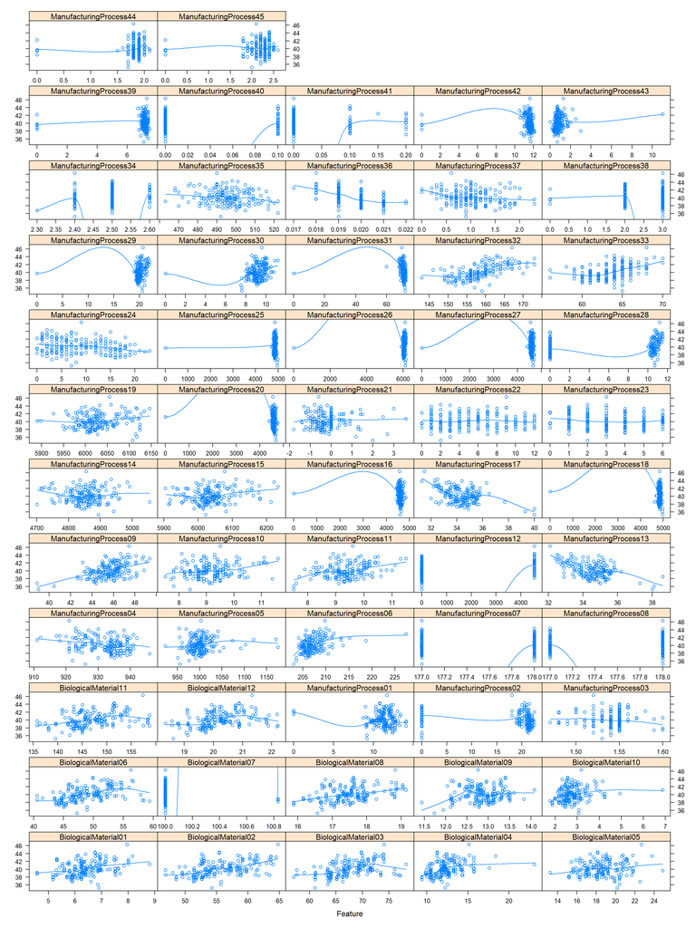

```r
##################################
# Formulating the scatter plot
##################################
featurePlot(x = DPA.Predictors.Numeric,
            y = DPA$Yield,
            plot = "scatter",
            type = c("p", "smooth"),
            span = .5,
            layout = c(5, ceiling(ncol(DPA.Predictors.Numeric)/5)))
```

# **2. References**

**[Book]** [Applied Predictive Modeling](http://appliedpredictivemodeling.com/) by Max Kuhn and Kjell Johnson  
**[Book]** [An Introduction to Statistical Learning](https://www.statlearning.com/) by Gareth James, Daniela Witten, Trevor Hastie and Rob Tibshirani  
**[Book]** [R For Data Science](https://r4ds.had.co.nz/index.html) by Hadley Wickham and Garrett Grolemund  
**[Book]** [Exploratory Data Analysis with R](https://bookdown.org/rdpeng/exdata/) by Roger Peng  
**[Book]** [Multivariate Data Visualization with R](http://lmdvr.r-forge.r-project.org/figures/figures.html) by Deepayan Sarkar  
**[Book]** [Machine Learning](https://bookdown.org/ssjackson300/Machine-Learning-Lecture-Notes/) by Samuel Jackson  
**[Book]** [Feature Engineering and Selection: A Practical Approach for Predictive Models](http://www.feat.engineering/index.html) by Max Kuhn and Kjell Johnson  
**[Book]** [Data Modeling Methods](https://bookdown.org/larget_jacob/data-modeling-methods/) by Jacob Larget  
**[Book]** [Introduction to R](https://biocorecrg.github.io/CRG_RIntroduction/) by Sara Bonnin  
**[R Package]** [AppliedPredictiveModeling](https://cran.r-project.org/web//packages/AppliedPredictiveModeling/AppliedPredictiveModeling.pdf) by Max Kuhn  
**[R Package]** [caret](https://topepo.github.io/caret/index.html) by Max Kuhn  
**[R Package]** [dplyr](https://cran.r-project.org/web/packages/dplyr/index.html/) by Hadley Wickham  
**[R Package]** [moments](https://cran.r-project.org/web/packages/moments/index.html) by Lukasz Komsta and Frederick  
**[R Package]** [skimr](https://cran.r-project.org/web/packages/skimr/skimr.pdf) by Elin Waring  
**[R Package]** [RANN](https://cran.r-project.org/web/packages/RANN/RANN.pdf) by Sunil Arya, David Mount, Samuel Kemp and Gregory Jefferis  
**[R Package]** [corrplot](https://cran.r-project.org/web/packages/corrplot/corrplot.pdf) by Taiyun Wei  
**[R Package]** [lares](https://cran.rstudio.com/web/packages/lares/lares.pdf) by Bernardo Lares  
**[R Package]** [DMwR](https://mran.microsoft.com/snapshot/2016-05-02/web/packages/DMwR/DMwR.pdf) by Luis Torgo  
**[Article]** [The caret Package](https://topepo.github.io/caret/index.html) by Max Kuhn  
**[Article]** [A Short Introduction to the caret Package](https://cran.r-project.org/web/packages/caret/vignettes/caret.html) by Max Kuhn  
**[Article]** Caret Package – A Practical Guide to Machine Learning in R by Selva Prabhakaran  
**[Article]** [Lattice Graphs](http://www.sthda.com/english/wiki/lattice-graphs) by STHDA Team  
**[Article]** [Exploratory Data Analysis in R with Tidyverse](https://www.pluralsight.com/guides/exploratory-data-analysis-in-r) by Nishant Kumar Singh  
**[Article]** [Exploratory Data Analysis in R (Introduction)](https://blog.datascienceheroes.com/exploratory-data-analysis-in-r-intro/) by Data Science Hero Team  
**[Article]** [How to do Exploratory Data Analysis (EDA) in R (With Examples)](https://geekflare.com/exploratory-data-analysis/) by Talha Khalid  
**[Article]** [Packages for Exploratory Data Analysis in R](https://www.r-bloggers.com/2022/04/packages-for-exploratory-data-analysis-in-r/) by Luke DiMartino  
**[Article]** [DataExplorer: Exploratory Data Analysis in R](https://www.business-science.io/code-tools/2021/03/02/use-dataexplorer-for-EDA.html) by Matt Dancho  
**[Article]** [How to Perform Exploratory Data Analysis in R (With Example)](https://www.statology.org/exploratory-data-analysis-in-r/) by Statology Team  
**[Article]** [Exploratory Data Analysis in R Programming](https://www.geeksforgeeks.org/exploratory-data-analysis-in-r-programming/) by Geeks For Geeks Team  
**[Article]** [Exploratory Data Analysis](https://www.ibm.com/topics/exploratory-data-analysis) by IBM Team  
**[Article]** What Is Exploratory Data Analysis? by IBM Team  
**[Article]** [Data Exploration in R (9 Examples) | Exploratory Analysis & Visualization](https://statisticsglobe.com/data-exploration-r) by Joachim Schork  
**[Article]** [Exploratory Data Analysis in Python](https://www.geeksforgeeks.org/exploratory-data-analysis-in-python/) by Geeks For Geeks Team  
**[Article]** [Data Quality Assessment for Machine Learning](https://research.ibm.com/publications/data-quality-assessment-for-machine-learning) by IBM Team  
**[Article]** [Data Quality for Machine Learning Tasks](https://researcher.watson.ibm.com/researcher/view_group.php?id=10751) by IBM Team  
**[Publication]** [A Review: Data Pre-processing and Data Augmentation Techniques](https://www.sciencedirect.com/science/article/pii/S2666285X22000565#:~:text=Data%20Pre-processing%20is%20the%20First%20step%20in%20Machine,algorithm%20can%20promptly%20analyze%20the%20features%20of%20data.) by Kiran Maharana, Surajit Mondal and Bhushankumar Nemade  
**[Publication]** [Data Quality for Machine Learning Tasks](https://dl.acm.org/doi/10.1145/3447548.3470817) by Nitin Gupta, Shashank Mujumdar, Hima Patel, Satoshi Masuda, Naveen Panwar, Sambaran Bandyopadhyay, Sameep Mehta, Shanmukha Guttula, Shazia Afzal, Ruhi Sharma Mittal and Vitobha Munigala (KDD ’21: Proceedings of the 27th ACM SIGKDD Conference on Knowledge Discovery & Data Mining)  
**[Publication]** [Overview and Importance of Data Quality for Machine Learning Tasks](https://dl.acm.org/doi/10.1145/3394486.3406477) by Abhinav Jain, Hima Patel, Lokesh Nagalapatti, Nitin Gupta, Sameep Mehta, Shanmukha Guttula, Shashank Mujumdar, Shazia Afzal, Ruhi Sharma Mittal and Vitobha Munigala (KDD ’20: Proceedings of the 26th ACM SIGKDD International Conference on Knowledge Discovery & Data Mining)  
**[Publication]** [Spatial Sign Preprocessing: A Simple Way To Impart Moderate Robustness to Multivariate Estimators](https://pubs.acs.org/doi/10.1021/ci050498u) by Sven Serneels, Evert De Nolf, and Pierre Van Espen (Journal of Chemical Information and Modeling)  
**[Publication]** [An Analysis of Transformations](https://rss.onlinelibrary.wiley.com/doi/10.1111/j.2517-6161.1964.tb00553.x) by George Box and David Cox (Journal of the Royal Statistical Society)  
**[Publication]** [A New Family of Power Transformations to Improve Normality or Symmetry](https://academic.oup.com/biomet/article-abstract/87/4/954/232908?redirectedFrom=fulltext) by In-Kwon Yeo and Richard Johnson (Biometrika)  
**[Publication]** [Exponential Data Transformations](https://rss.onlinelibrary.wiley.com/doi/abs/10.2307/2988129) by B Manly (Journal of the Royal Statistical Society)  
**[Course]** [Applied Data Mining and Statistical Learning](https://online.stat.psu.edu/stat508/) by Penn State Eberly College of Science